# M3 --- le notebook unique de `FICHE_M3.pdf`

**Tout ce que la fiche affirme est établi ici, et rien d'ailleurs.** Fusion des nb 13 (protocole, épreuves), 15 (ETF) et du netting du 11 — les trois partent en `_archive/`.

[output not shown]

**Les ancres, assertées et non commentées** — M3 titres **661,57 / 573,57** · extraction du nb 11, 150 coupes au plafond 8,5 % **672,35 / 612,25**, net de 10 pb **648,69 / 561,66** · netting **+1,31 / +1,06** · lignes ETF, carte datée **+1,78 / +0,78 / +1,45** · tilt $\lambda = 2$ **+3,41 %/an**, écart au marché **4,2 %** *(trace de recherche — §20)* · §20 : IR(a) constant **0,637** · TC médian **0,947** · dernière coupe **a = 0,832**.

**Hors champ** — M1, M2, M4, la réplique NANC/GOP, les stratégies Quiver, les alternatives du nb 14 : portées par le nb 11, qui reste la source de `PAPIER_METHODE`.

## §1 — Le périmètre

```python
import os, math, warnings
import numpy as np, pandas as pd
import matplotlib.pyplot as plt
from scipy import stats
warnings.filterwarnings("ignore")
pd.set_option("display.width", 200); pd.set_option("display.max_columns", 50)
plt.rcParams.update({"figure.figsize": (11, 3.6), "axes.grid": True, "grid.alpha": .25,
                     "axes.spines.top": False, "axes.spines.right": False, "font.size": 9})
BLEU, VERT, ROUGE, GRIS = "#144d90", "#146e3c", "#a01e1e", "#666666"

RACINE = "/Users/lemairealice/Downloads/Jupiter"
CLEAN  = f"{RACINE}/00_recuperation_donnees/data/clean/transactions_backtest_2014_2026.csv"
PX     = f"{RACINE}/02_recherche_backtest/cache/prices_v2"
FF_CSV = f"{RACINE}/02_recherche_backtest/cache/ff_factors.csv"
FIGS   = f"{RACINE}/02_recherche_backtest/figs_nb16"
os.makedirs(FIGS, exist_ok=True)

W3, TOPN, CAP = 756, 150, 0.10           # les trois constantes de M3
print(f"W₃ = {W3} j (≈ 3 ans) · N = {TOPN} titres · c = {100*CAP:.1f} %")
print(f"figures → {FIGS}")
```

```
W₃ = 756 j (≈ 3 ans) · N = 150 titres · c = 10.0 %
figures → /Users/lemairealice/Downloads/Jupiter/02_recherche_backtest/figs_nb16
```

### §1.1 — Choisir le sous-ensemble

Table déjà propre (pipeline S1/S2) : on ne nettoie rien, on choisit un *périmètre*.

$$\text{actions} \;\wedge\; \tau_k \in [2014, 2026] \;\wedge\; \text{série de prix exploitable}$$

- $x_k = (\,m_k,\; i_k,\; \tau_k,\; \delta_k,\; d_k,\; A_k\,)$ — élu, titre, transaction, divulgation, sens, milieu de fourchette ;
- `etf_proxy` : inutile à M3, sert à la variante ETF (§11+), ne change aucun filtre (§1.5).

```python
df0 = pd.read_csv(CLEAN, usecols=["bioguide_id","member_name","ticker_yahoo","direction",
                                  "transaction_date","disclosure_date","amount_midpoint","asset_class",
                                  "chamber","committee_membership","committees_key_flag","sector_gics",
                                  "flag_late_filing","party","etf_proxy"],
                  parse_dates=["transaction_date","disclosure_date"])
n0 = len(df0)
n_etf = int(df0.asset_class.str.startswith("etf").sum()); n_unk = int((df0.asset_class == "unknown").sum())

a = df0[df0.asset_class == "stock"]                                                 # actions seules
b = a[(a.transaction_date.dt.year >= 2014) & (a.transaction_date.dt.year <= 2026)]  # fenêtre canonique

df = (b.rename(columns={"ticker_yahoo":"tk","direction":"op",
                        "transaction_date":"tau","amount_midpoint":"A"})
        .sort_values("tau").reset_index(drop=True))

# la table clean garantit ticker et montant renseignés — on le vérifie plutôt que de faire un dropna inutile
assert df[["tk","A"]].notna().all().all(), "ticker ou montant manquant : la table clean ne devrait pas le permettre"

print(f"  table clean                    {n0:>9,}")
print(f"→ actions seules                 {len(a):>9,}   (−{n0-len(a):,} : {n_etf:,} ETF · {n_unk:,} classe inconnue)")
print(f"→ années 2014-2026               {len(b):>9,}   (−{len(a)-len(b):,} : donnée trop mince avant 2014)")
print(f"\nmembres {df.bioguide_id.nunique()} · titres {df.tk.nunique():,} · "
      f"{df.tau.min().date()} → {df.tau.max().date()}")
df.head(3)
```

```
  table clean                      134,464
→ actions seules                   128,974   (−5,490 : 2,190 ETF · 3,300 classe inconnue)
→ années 2014-2026                 128,269   (−705 : donnée trop mince avant 2014)

membres 360 · titres 3,798 · 2014-01-02 → 2026-06-30
```

|  | bioguide_id | member_name | party | chamber | committee_membership | committees_key_flag | tk | asset_class | sector_gics | etf_proxy | op | A | tau | disclosure_date | flag_late_filing |
| --- | --- | --- | --- | --- | --- | --- | --- | --- | --- | --- | --- | --- | --- | --- | --- |
| 0 | M001157 | Michael T. McCaul | Republican | house | HSFA07; HSHM05; HSHM07; HSHM08; HSHM09; HSHM11... | False | ESV | stock | Energy | XLE | sell | 8000.5 | 2014-01-02 | 2014-02-12 | False |
| 1 | R000586 | James B. Renacci | Republican | house | HSWM01; HSWM03; House Committee on Ways and Means | True | HLX | stock | Energy | XLE | buy | 8000.5 | 2014-01-02 | 2014-01-27 | False |
| 2 | R000586 | James B. Renacci | Republican | house | HSWM01; HSWM03; House Committee on Ways and Means | True | SBAC | stock | Real Estate | XLRE | buy | 8000.5 | 2014-01-02 | 2014-01-27 | False |

### §1.2 — Le calendrier de bourse $\mathcal{C}$ — celui du SPY

```python
spy = pd.read_csv(f"{PX}/SPY.csv", parse_dates=["Date"]).set_index("Date")["close"].sort_index()
cal = spy.index
r_spy = spy.pct_change()
print(f"𝒞 : {len(cal):,} jours cotés · {cal[0].date()} → {cal[-1].date()}")
```

```
𝒞 : 3,645 jours cotés · 2012-01-03 → 2026-07-02
```

### §1.3 — Charger les prix, et re-prouver leur santé

Garde-fous des notebooks amont, ré-appliqués **parce que ce notebook est autonome** — re-dérivation recoupée au §1.5, pas nouveau nettoyage.

$$\#\text{obs}_i \ge 2 \;\wedge\; \min_u P_i(u) \ge 0{,}10\,\$ \;\wedge\; \max_u \left| \frac{P_i(u)}{P_i(u-1)} - 1 \right| \le 3$$

- on garde **le dernier jour réellement coté** — il écartera les sociétés mortes (§2) ;
- **les onze SPDR sont chargés en plus des titres**, pour la variante ETF (§11+) : hors M3, qui ne garde que `asset_class == "stock"` — eux sont `etf_sector` (§1.5).

```python
ETF_SECT = ["XLB","XLC","XLE","XLF","XLI","XLK","XLP","XLRE","XLU","XLV","XLY"]   # les 11 secteurs GICS

PXV, LAST = {}, {}
n_abs, n_cor = 0, 0
for tk in sorted(set(df.tk.unique()) | set(ETF_SECT)):        # ← l'union : les titres ET les 11 ETF
    f = f"{PX}/{tk}.csv"
    if not os.path.exists(f): n_abs += 1; continue
    try:
        s = pd.read_csv(f, parse_dates=["Date"]).set_index("Date")["close"].sort_index().dropna()
    except Exception:
        n_abs += 1; continue
    if len(s) < 2 or s.min() < 0.10: n_cor += 1; continue
    v = s.pct_change().dropna()
    if len(v) and v.abs().max() > 3.0: n_cor += 1; continue
    LAST[tk] = s.index[-1]
    PXV[tk]  = s.reindex(cal).ffill().to_numpy()

PXV_ACTIONS = set(df.tk.unique()) & set(PXV)                  # ← le périmètre de M3, hors ETF
print(f"titres demandés {df.tk.nunique():,} → chargés {len(PXV_ACTIONS):,} "
      f"(absents {n_abs:,} · corrompus écartés {n_cor})")
print(f"ETF sectoriels chargés en plus : {len(set(PXV) - PXV_ACTIONS)}/11  (pour le §9, hors périmètre M3)")
```

```
titres demandés 3,798 → chargés 2,755 (absents 992 · corrompus écartés 51)
ETF sectoriels chargés en plus : 11/11  (pour le §9, hors périmètre M3)
```

```python
df = df[df.tk.isin(PXV)].reset_index(drop=True)
df["i0"]  = cal.searchsorted(df.tau.values, side="left")             # exécution à la transaction τ
df["ide"] = cal.searchsorted(df.disclosure_date.values, side="left") # exécution à la divulgation δ — celle de M3
df = df[df.i0 < len(cal)].reset_index(drop=True)
print(f"flux exploitable : {len(df):,} trades · {df.bioguide_id.nunique()} membres · {df.tk.nunique():,} titres")
print(f"  achats {(df.op=='buy').sum():,} · ventes {(df.op=='sell').sum():,}")
```

```
flux exploitable : 113,369 trades · 350 membres · 2,755 titres
  achats 57,445 · ventes 55,924
```

### §1.4 — Recoupement avec l'univers du notebook 09

- `px_couvert` du 09 = prix exploitables sur l'univers **complet** (actions + ETF, toutes années) ;
- le nôtre — actions seules, 2014-2026 — en est un **sous-ensemble** : inclusion stricte ;
- test sur `PXV_ACTIONS`, **pas** `PXV` : sinon on parierait sur les ETF d'une table qu'on ne contrôle pas.

```python
t09 = pd.read_csv(f"{RACINE}/02_recherche_backtest/tables/tickers.csv", usecols=["ticker","px_couvert"])
couv09 = set(t09.loc[t09.px_couvert, "ticker"])
manque = PXV_ACTIONS - couv09
print(f"09 · titres px_couvert (univers complet) : {len(couv09):,}")
print(f"13 · titres chargés (actions 2014-2026)  : {len(PXV_ACTIONS):,}")
print(f"     dont absents du périmètre du 09      : {len(manque)}")
assert not manque, f"divergence à comprendre : {sorted(manque)[:10]}"
print("\n✅ inclusion vérifiée — notre univers d'actions est bien un sous-ensemble de celui du 09")
```

```
09 · titres px_couvert (univers complet) : 3,289
13 · titres chargés (actions 2014-2026)  : 2,755
     dont absents du périmètre du 09      : 0

✅ inclusion vérifiée — notre univers d'actions est bien un sous-ensemble de celui du 09
```

### §1.5 — Validation : les préparatifs de la variante ETF ne touchent à rien

`etf_proxy` et les onze SPDR ne doivent pas modifier le flux de M3 — vérifié, pas affirmé.

```python
# (1) aucun des 11 ETF sectoriels n'apparaît dans le flux : ils sont classés `etf_sector`, jamais `stock`
inter = set(df.tk.unique()) & set(ETF_SECT)
assert not inter, f"un ETF sectoriel est entré dans le flux de M3 : {inter}"

# (2) le flux a la taille attendue, celle du notebook 11
assert len(df) == 113_369, f"flux = {len(df):,} lignes, attendu 113 369 (le périmètre a bougé)"

# (3) etf_proxy est utilisable : rempli partout, et à valeurs dans les 11 secteurs
assert df.etf_proxy.notna().all(), f"{df.etf_proxy.isna().sum()} lignes sans etf_proxy"
assert set(df.etf_proxy.unique()) <= set(ETF_SECT), f"etf_proxy hors des 11 SPDR : {set(df.etf_proxy.unique()) - set(ETF_SECT)}"

print(f"✅ les 11 ETF sectoriels ont un prix mais n'entrent pas dans le flux ({len(df):,} trades, inchangé)")
print(f"✅ etf_proxy renseigné sur 100 % des {len(df):,} lignes, à valeurs dans les 11 secteurs GICS")
```

```
✅ les 11 ETF sectoriels ont un prix mais n'entrent pas dans le flux (113,369 trades, inchangé)
✅ etf_proxy renseigné sur 100 % des 113,369 lignes, à valeurs dans les 11 secteurs GICS
```

## §2 — L'univers investissable $\mathcal{U}_t$ et les coupes

$$\mathcal{U}_t = \{\, i \;:\; \text{(a) action} \;\wedge\; \text{(b) } \exists\, u \in [\,n(t)-4,\; n(t)\,] \text{ tq } P_i(u) \text{ observée} \,\}$$

**(b) n'est pas une prudence, c'est une nécessité** : le cache prolonge les prix au dernier cours connu — sans ce test, une société morte en 2019 « cote » encore en 2026, cadavre à rendement et risque nuls qui gonfle le résultat sans jamais perdre d'argent.

```python
NLAST  = {tk: cal.searchsorted(d, side="right") - 1 for tk, d in LAST.items()}   # dernier vrai cours
NFIRST = {tk: int(np.argmax(~np.isnan(PXV[tk]))) for tk in PXV}                  # premier cours disponible

def vivant(tk, i):
    # le titre cote DÉJÀ (sa série a commencé) ET cote ENCORE (dernier cours à moins de 4 jours)
    return NFIRST[tk] <= i and NLAST[tk] >= i - 4

mort = sum(1 for tk in PXV_ACTIONS if NLAST[tk] < len(cal) - 5)
print(f"titres dont la cotation s'arrête avant la fin du calendrier : {mort:,} / {len(PXV_ACTIONS):,} "
      f"({mort/len(PXV_ACTIONS):.0%})")
```

```
titres dont la cotation s'arrête avant la fin du calendrier : 80 / 2,755 (3%)
```

```python
# les coupes commencent avec la donnée : dernier jour coté de chaque mois, à partir de janvier 2014
DEBUT = pd.Timestamp("2014-01-31")
coupes = [cal.searchsorted(d, side="right") - 1
          for d in pd.date_range(DEBUT, cal[-1], freq="ME")]
coupes = sorted(set(i for i in coupes if 21 <= i < len(cal) - 1))
print(f"{len(coupes)} coupes mensuelles · {cal[coupes[0]].date()} → {cal[coupes[-1]].date()}")
print(f"première coupe : indice {coupes[0]} dans le calendrier (qui démarre en {cal[0].year})")
```

```
150 coupes mensuelles · 2014-01-31 → 2026-06-30
première coupe : indice 522 dans le calendrier (qui démarre en 2012)
```

### §2.1 — Validation : le seuil de la première coupe ne mord pas

Borne héritée du nb 11 ($W = 21$ j, puis 42 j sans recalcul de la liste), ici en dur à 21. **Sans effet** : prix depuis 2012, coupes depuis 2014 — la première coupe a un indice bien supérieur à toute fenêtre envisagée.

```python
def _coupes(seuil):
    c = [cal.searchsorted(d, side="right") - 1 for d in pd.date_range(DEBUT, cal[-1], freq="ME")]
    return sorted(set(i for i in c if seuil <= i < len(cal) - 1))

for s in [0, 21, 42, 126]:
    assert _coupes(s) == coupes, f"le seuil {s} change la liste des coupes"
print(f"✅ les seuils 0, 21, 42 et 126 donnent la MÊME liste de {len(coupes)} coupes")
print(f"   (la 1ʳᵉ coupe est à l'indice {coupes[0]} ≫ 126 : la borne ne peut pas mordre)")
```

```
✅ les seuils 0, 21, 42 et 126 donnent la MÊME liste de 150 coupes
   (la 1ʳᵉ coupe est à l'indice 522 ≫ 126 : la borne ne peut pas mordre)
```

## §3 — Le moteur d'exécution

Il ignore la méthode : **poids cibles** par coupe en entrée, NAV en sortie.

- achat au **close du lendemain** ($e = t+1$), jamais au cours de la coupe ;
- poids $\to$ **parts**, puis plus rien : le portefeuille **dérive** avec les cours entre deux coupes ;
- rotation $\;\mathrm{TO}_t = \tfrac12 \sum_i |w^{\text{réalisé}}_i - w^{\text{dérivé}}_i|$ ;
- frein $\tau_{\max}$ et coût $c$ (§9) **neutres par défaut** : à $\infty$ et 0, NAV bit-identique.

$$\lambda_R = \min\!\Bigl(1, \frac{\tau_{\max}}{\mathrm{TO}_t}\Bigr), \qquad w^{\text{réalisé}}_i = w^{\text{dérivé}}_i + \lambda_R\,(w^{\text{cible}}_i - w^{\text{dérivé}}_i), \qquad V_t \leftarrow V_t\,(1 - 2\,\mathrm{TO}_t\,c)$$

**Facteur 2** : $\tfrac12\sum|\Delta w|$ = montant acheté = montant vendu, on paie des deux côtés.

```python
TAU_MAX = 0.25                                                        # frein de rotation, en %/mois

def cap_turnover(w_der, w_cible, tau_max):
    keys = set(w_der) | set(w_cible)
    TO = 0.5 * sum(abs(w_cible.get(k,0.0) - w_der.get(k,0.0)) for k in keys)
    if TO <= 1e-12: return dict(w_cible)
    lam = min(1.0, tau_max / TO)
    return {k: w_der.get(k,0.0) + lam*(w_cible.get(k,0.0) - w_der.get(k,0.0)) for k in keys}

def run_livre(WP, tau_max=np.inf, cuts=None, cout_bps=0.0):
    # moteur d'UN livre : parts, buy-and-hold, frein de rotation, frais. Rend (NAV, rotations réalisées)
    # tau_max=∞ et cout_bps=0 → aucune opération n'est faite : la NAV est celle du buy-and-hold pur
    cuts = coupes if cuts is None else cuts
    V = np.full(len(cal), np.nan); nbr = {}; turns = []
    e0 = cuts[0] + 1; V[e0] = 100.0
    bornes = [(cuts[j] + 1, cuts[j+1] + 1) for j in range(len(cuts) - 1)]
    for (e, e_next) in bornes:
        w_cible = {tk: wi for tk, wi in WP.get(e-1, {}).items() if np.isfinite(PXV[tk][e])}
        val = sum(q*PXV[tk][e] for tk, q in nbr.items())
        w_der = {tk: q*PXV[tk][e]/val for tk, q in nbr.items()} if val > 0 else {}
        # Deux cas exemptés du frein, pour ne JAMAIS vaporiser du cash de la NAV :
        #  - w_der vide (1er déploiement) : on bâtit le livre en entier — partir du cash n'est pas de la rotation ;
        #  - w_cible vide (sélection vide) : on sort tout au cash, tenu à plat (V[t]=V[t-1]).
        w_real = dict(w_cible) if (not w_der or not w_cible) else cap_turnover(w_der, w_cible, tau_max)
        # garde-fou bruyant : quand une cible existe, le livre reste pleinement investi (Σw=1) — pas de fuite
        assert (not w_cible) or abs(sum(w_real.values()) - 1.0) < 1e-6, "run_livre : poids capés ne somment pas à 1 (fuite de cash)"
        turns.append(0.5*sum(abs(w_real.get(k,0)-w_der.get(k,0)) for k in set(w_real)|set(w_der)))
        if cout_bps: V[e] *= 1.0 - 2.0*turns[-1]*cout_bps/1e4
        nbr = {tk: V[e]*wi/PXV[tk][e] for tk, wi in w_real.items() if abs(wi) > 1e-12}
        for t in range(e+1, min(e_next, len(cal)-1)+1):
            V[t] = sum(q*PXV[tk][t] for tk, q in nbr.items()) if nbr else V[t-1]
    span = pd.Series(V, index=cal); span = span.loc[span.first_valid_index():span.last_valid_index()]
    return span, np.array(turns[1:])                                 # rotation hors 1er déploiement
```

### §3.1 — Validation : un mois recalculé à la main, hors moteur

Deux titres à poids connus, NAV fabriquée à la main sur un mois, comparée au moteur. Seul moyen de savoir que « close J+1, parts figées, dérive » est **implémenté**, et pas seulement écrit.

```python
tk1, tk2 = "AAPL", "MSFT"
j0, j1 = coupes[60], coupes[61]                       # deux coupes consécutives quelconques
WP_test = {j0: {tk1: 0.60, tk2: 0.40}, j1: {tk1: 0.60, tk2: 0.40}}
V_test, _ = run_livre(WP_test, np.inf, cuts=[j0, j1, coupes[62]])

e = j0 + 1                                            # on achète au close du LENDEMAIN de la coupe
q1 = 100.0 * 0.60 / PXV[tk1][e]                       # parts, figées jusqu'à la coupe suivante
q2 = 100.0 * 0.40 / PXV[tk2][e]
for t in [e, e + 5, j1]:                              # trois dates dans le mois
    a_la_main = q1*PXV[tk1][t] + q2*PXV[tk2][t]
    assert abs(V_test.loc[cal[t]] - a_la_main) < 1e-9, f"écart au jour {cal[t].date()}"

print(f"achat au close du {cal[e].date()} (la coupe est le {cal[j0].date()}) — {q1:.4f} × {tk1} + {q2:.4f} × {tk2}")
print(f"NAV à la coupe suivante : moteur {V_test.loc[cal[j1]]:.6f} · à la main {q1*PXV[tk1][j1]+q2*PXV[tk2][j1]:.6f}")
print("✅ close J+1, parts figées, dérive libre — le moteur fait ce qui est écrit")
```

```
achat au close du 2019-02-01 (la coupe est le 2019-01-31) — 1.5186 × AAPL + 0.4178 × MSFT
NAV à la coupe suivante : moteur 106.442585 · à la main 106.442585
✅ close J+1, parts figées, dérive libre — le moteur fait ce qui est écrit
```

## §4 — M3 : la spécification, et son code

$$w^{P}_{i,t} \;=\; \Pi_c\!\left(\frac{s_{i,t}}{\sum_{j \in \mathcal{S}} s_{j,t}}\right), \qquad s_{i,t} \;=\; \underbrace{\Big(\textstyle\sum_{k\,:\,P,\ \text{achat},\ t-W_3<\delta_k\le t} A_k\Big)}_{B_i\ \text{: les dollars}} \;\times\; \underbrace{\#\{\text{élus de }P\text{ acheteurs de } i\}}_{m_i\ \text{: le consensus}}$$

$\mathcal{S}$ = les 150 plus gros scores · $\Pi_c$ = plafonnement à $c = 10\,\%$.

- **plafond = remplissage par niveau, pas écrêtage** : unique $\lambda$ tel que $\sum_i \min(c, \lambda v_i) = 1$ — les lignes au plafond y restent, les autres montent proportionnellement ;
- **ce $\lambda$ existe et est unique dès $|\mathcal{S}| \ge \lceil 1/c \rceil = 10$ titres**, car $\lambda \mapsto \sum_i \min(c, \lambda v_i)$ croît continûment de 0 à $|\mathcal{S}|\,c$ ; en dessous, aucune solution — d'où la règle de démarrage (§4.1) ;
- **filtre anti-bruit $\theta$** (§7.1) — écarte toute opération d'un dépôt de $\theta$ opérations ou plus du même élu le même jour. M3 : $\theta = \infty$ ; M4 : 50.

```python
# ── fenêtrage sur la DIVULGATION δ : l'index trié une fois pour toutes ──
ordre_d = np.argsort(df.ide.values, kind="stable")
I_de    = df.ide.values[ordre_d]

FUSION = {"GOOGL": "GOOG", "BRK-A": "BRK-B", "FOXA": "FOX", "NWSA": "NWS"}   # classes d'actions = une société

def cap_poids(w, cap=CAP):
    # remplissage par niveau : w_i = min(cap, λ·v_i), λ trouvé par redistribution itérative de l'excédent
    w = w.astype(float).copy()
    for _ in range(200):
        over = w > cap + 1e-12
        if not over.any(): break
        exces = float((w[over] - cap).sum()); w[over] = cap
        low = w < cap - 1e-12
        if not low.any() or w[low].sum() <= 0: break
        w[low] += exces * w[low] / w[low].sum()
    return w / w.sum()

# taille du dépôt = nb d'opérations déclarées par le même élu le même jour de divulgation.
# Définie ICI, avec poids_methode qui la lit — même à θ=∞ la colonne doit exister.
df["taille_depot"] = df.groupby(["bioguide_id", "ide"]).tk.transform("size")

def _instrument(g, univers="titres"):
    # LE point de substitution : ce que le portefeuille achète réellement.
    #   "titres" → le titre lui-même, classes d'actions fusionnées (M3)
    #   "etf"    → l'ETF sectoriel SPDR du titre (§9)
    if univers == "titres": return g.tk.map(lambda t: FUSION.get(t, t))
    if univers == "etf":    return g.etf_proxy
    raise ValueError(f"univers inconnu : {univers}")

SEUIL_BRUIT = 50          # θ — DÉCLARÉ AVANT tout calcul de rendement (M4 seulement)

def poids_methode(i1, parti, topN=TOPN, cap=CAP, seuil=np.inf, mode="score", univers="titres"):
    # M3 = les valeurs par défaut. `mode` ne change QUE la pondération : l'univers reste défini par le score.
    lo, hi = np.searchsorted(I_de, i1 - W3, "right"), np.searchsorted(I_de, i1, "right")
    g = df.iloc[ordre_d[lo:hi]]
    g = g[(g.party == parti) & (g.op == "buy") & (g.taille_depot < seuil)]
    if not len(g): return {}
    g       = g.assign(tkm=_instrument(g, univers))
    buy     = g.groupby("tkm").A.sum()                                   # B_i : les dollars
    breadth = g.groupby("tkm").bioguide_id.nunique().reindex(buy.index)  # m_i : les élus
    score   = (buy * breadth).dropna()
    score   = score[[tk for tk in score.index if tk in PXV and np.isfinite(PXV[tk][i1+1]) and vivant(tk, i1)]]
    score   = score.sort_values(ascending=False).head(topN)               # ← l'UNIVERS, toujours par le score
    if not len(score) or score.sum() <= 0: return {}
    w = {"score":   score,
         "dollars": buy.reindex(score.index),
         "elus":    breadth.reindex(score.index).astype(float),
         "equal":   pd.Series(1.0, index=score.index)}[mode]
    if w.sum() <= 0: return {}
    return cap_poids(w / w.sum(), cap).to_dict()

def cibles_methode(parti, **kw):
    return {i: poids_methode(i, parti, **kw) for i in coupes[:-1]}

PARTIS = [("Democrat", "NANC"), ("Republican", "GOP")]
print(f"M3 = poids_methode(·, parti)  —  θ=∞, mode=score, univers=titres, N={TOPN}, c={100*CAP:.0f} %")
```

```
M3 = poids_methode(·, parti)  —  θ=∞, mode=score, univers=titres, N=150, c=10 %
```

### §4.1 — La règle de démarrage : commencer où la spécification est applicable

*Le cas se présente parce que le signal regarde trois ans en arrière alors que les données commencent en 2014.*

```python
SEUIL_DEG = math.ceil(1/CAP)                      # en dessous, le plafond n'a pas de solution
card = {i: {nom: len(poids_methode(i, parti)) for parti, nom in PARTIS} for i in coupes[:-1]}
conformes = [i for i in coupes[:-1] if min(card[i].values()) >= SEUIL_DEG]
i_start   = conformes[0]

print(f"titres retenus aux 5 premières fins de mois (seuil = {SEUIL_DEG}) :")
for i in coupes[:5]:
    ok = "✓" if min(card[i].values()) >= SEUIL_DEG else "✗  ← le plafond n'a pas de solution"
    print(f"   {cal[i].date()} : NANC {card[i]['NANC']:3d} · GOP {card[i]['GOP']:3d}   {ok}")

coupes_tout = list(coupes)                         # gardé : sert au contrôle de non-régression du §6.1
coupes = [i for i in coupes if i >= i_start]       # ← le calendrier du backtest publié
print(f"\ndépart : {cal[i_start].date()} (achat au close du {cal[i_start+1].date()}) · "
      f"{len(coupes)} coupes retenues sur {len(coupes_tout)}")
```

```
titres retenus aux 5 premières fins de mois (seuil = 10) :
   2014-01-31 : NANC   9 · GOP  24   ✗  ← le plafond n'a pas de solution
   2014-02-28 : NANC  99 · GOP 112   ✓
   2014-03-31 : NANC 115 · GOP 150   ✓
   2014-04-30 : NANC 136 · GOP 150   ✓
   2014-05-30 : NANC 150 · GOP 150   ✓

départ : 2014-02-28 (achat au close du 2014-03-03) · 149 coupes retenues sur 150
```

### §4.2 — Le cache : un jeu de cibles par variante, et toutes les tables y puisent

Seul calcul coûteux (149 coupes × un regroupement sur ~30 000 lignes) : fait **une fois** dans `WPM`, **`SER` en dérive**. Pas une optimisation — c'est ce qui rend impossible qu'un tableau affiche 672,35 et un autre 672,31.

```python
import time
t0 = time.time()

KWM = {"M3 · $ × élus":     dict(),                                    # ← LA méthode
       "M2 · dollars purs": dict(mode="dollars"),                      # la pondération sans le consensus
       "élus seuls":        dict(mode="elus"),                         # le consensus sans les dollars
       "équipondéré":       dict(mode="equal"),                        # ni l'un ni l'autre
       "M4 · + filtre θ=50": dict(seuil=SEUIL_BRUIT)}                  # M3 + le filtre anti-bruit
for th in [10, 20, 100]:
    KWM[f"θ = {th}"] = dict(seuil=th)

WPM = {}                                                               # (variante, fonds) → {coupe: {tk: w}}
for parti, nom in PARTIS:
    for m, kw in KWM.items():
        WPM[(m, nom)] = cibles_methode(parti, **kw)
SER = {k: run_livre(WP, np.inf)[0] for k, WP in WPM.items()}           # les NAV en dérivent

n_poids = sum(len(w) for WP in WPM.values() for w in WP.values())
print(f"{len(WPM)} jeux de cibles · {n_poids:,} poids · calculés en {time.time()-t0:.1f} s")
```

```
16 jeux de cibles · 352,002 poids · calculés en 14.1 s
```

```python
# VALIDATION §4.2 — le cache est complet et cohérent, et tout le notebook lira CES objets
assert len(WPM) == 2*len(KWM), f"cache incomplet : {len(WPM)} jeux au lieu de {2*len(KWM)}"
for (m, f), WP in WPM.items():
    assert set(WP) == set(coupes[:-1]), f"{m}/{f} : jeu de coupes incohérent"
    for i, w in WP.items():
        if w: assert abs(sum(w.values()) - 1) < 1e-9, f"{m}/{f} coupe {i} : Σw = {sum(w.values())}"
print(f"✅ {len(WPM)} jeux complets · Σw = 1 à chacune des {len(coupes)-1} coupes de chacun")
```

```
✅ 16 jeux complets · Σw = 1 à chacune des 148 coupes de chacun
```

### §4.3 — Validation : remplissage par niveau, et règle de démarrage suffisante

Deux contrôles indépendants de `cap_poids` :

1. **le point fixe** — $\lambda$ par bissection sur $\sum_i \min(c, \lambda v_i) = 1$ doit redonner le vecteur de `cap_poids` ;
2. **plus aucune coupe dégénérée** — sous $\lceil 1/c \rceil = 10$ titres, aucun $\lambda$ ne convient : `cap_poids` aplatit et sa normalisation rend l'**équipondéré**. Le §4.1 écarte exactement ces coupes ; on vérifie qu'il n'en reste aucune, et ce que la coupe écartée aurait coûté.

```python
# (1) le point fixe : λ retrouvé par bissection, indépendamment de cap_poids
def lam_bissection(v, cap=CAP):
    lo, hi = 1.0, 1e9
    for _ in range(300):
        lam = 0.5*(lo + hi)
        if sum(min(cap, lam*x) for x in v) < 1.0: lo = lam
        else: hi = lam
    return 0.5*(lo + hi)

ecart_max = 0.0
for i in coupes[10:150:17]:
    lo, hi = np.searchsorted(I_de, i - W3, "right"), np.searchsorted(I_de, i, "right")
    g = df.iloc[ordre_d[lo:hi]]; g = g[(g.party == "Democrat") & (g.op == "buy")]
    g = g.assign(tkm=g.tk.map(lambda t: FUSION.get(t, t)))
    sc = (g.groupby("tkm").A.sum() * g.groupby("tkm").bioguide_id.nunique()).dropna()
    sc = sc[[t for t in sc.index if t in PXV and np.isfinite(PXV[t][i+1]) and vivant(t, i)]]
    sc = sc.sort_values(ascending=False).head(TOPN)
    if len(sc) < math.ceil(1/CAP): continue
    v   = (sc / sc.sum()).values
    lam = lam_bissection(v)
    ecart_max = max(ecart_max, float(np.abs(np.minimum(CAP, lam*v) - cap_poids(sc/sc.sum()).values).max()))
print(f"✅ (1) cap_poids ≡ min(c, λv) avec λ trouvé par bissection — écart max {ecart_max:.2e}")
print(f"     ⌈1/c⌉ = {math.ceil(1/CAP)} titres : en dessous, aucun λ ne convient")
```

```
✅ (1) cap_poids ≡ min(c, λv) avec λ trouvé par bissection — écart max 9.71e-17
     ⌈1/c⌉ = 10 titres : en dessous, aucun λ ne convient
```

```python
# (2) plus aucune coupe dégénérée dans le calendrier retenu
for nom in ["NANC", "GOP"]:
    WP = WPM[("M3 · $ × élus", nom)]
    deg = [i for i in coupes[:-1] if WP[i] and len(WP[i]) < SEUIL_DEG]
    assert not deg, f"{nom} : coupes encore dégénérées → {[str(cal[i].date()) for i in deg]}"
    tailles = [len(WP[i]) for i in coupes[:-1] if WP[i]]
    print(f"✅ (2) {nom} — 0 coupe sous {SEUIL_DEG} titres sur {len(coupes)-1} · "
          f"|𝒮| min {min(tailles)} · médiane {int(np.median(tailles))}")

# ce que la coupe écartée aurait valu : elle était équipondérée de fait, pas pondérée par le score
i_ecarte = coupes_tout[0]
for nom, parti in [("NANC", "Democrat"), ("GOP", "Republican")]:
    w = poids_methode(i_ecarte, parti)
    ecart = np.abs(np.array(list(w.values())) - 1/len(w)).max()
    print(f"\ncoupe écartée du {cal[i_ecarte].date()} — {nom} : |𝒮| = {len(w)} · "
          f"max w {100*max(w.values()):.2f} % · écart à l'équipondéré {ecart:.1e}"
          f"{'  → équipondéré de fait' if ecart < 1e-9 else ''}")
```

```
✅ (2) NANC — 0 coupe sous 10 titres sur 148 · |𝒮| min 99 · médiane 150
✅ (2) GOP — 0 coupe sous 10 titres sur 148 · |𝒮| min 112 · médiane 150

coupe écartée du 2014-01-31 — NANC : |𝒮| = 9 · max w 11.11 % · écart à l'équipondéré 1.4e-17  → équipondéré de fait

coupe écartée du 2014-01-31 — GOP : |𝒮| = 24 · max w 10.00 % · écart à l'équipondéré 5.8e-02
```

### §4.4 — Validation : la conséquence en $K^2$, sur un cas fabriqué

$B_i \times m_i$ n'est pas une pondération au dollar déguisée. Sur trois titres fabriqués, à montant total identique : celui qu'un plus grand nombre d'élus a acheté doit dominer, et le rapport des scores doit être exactement le rapport des **carrés** du nombre d'élus.

```python
cas = pd.DataFrame({"titre": ["A", "B", "C"], "élus": [1, 2, 4], "$ par élu": [40_000, 20_000, 10_000]})
cas["B_i (total $)"] = cas["élus"] * cas["$ par élu"]                  # 40 000 pour les trois
cas["m_i"] = cas["élus"]
cas["s_i = B·m"] = cas["B_i (total $)"] * cas.m_i
cas["poids %"] = 100 * cas["s_i = B·m"] / cas["s_i = B·m"].sum()
display(cas.set_index("titre"))

assert cas["B_i (total $)"].nunique() == 1, "le cas doit être à montant total identique"
assert abs(cas["s_i = B·m"].iloc[2] / cas["s_i = B·m"].iloc[0] - 4) < 1e-12, "le rapport devrait être m_C/m_A = 4"
print(f"✅ à dollars égaux, 4 élus pèsent {cas['s_i = B·m'].iloc[2]/cas['s_i = B·m'].iloc[0]:.0f}× un seul élu")
print("   (le score est K²a pour K élus au montant a : le consensus compte au carré)")
```

| titre | élus | $ par élu | B_i (total $) | m_i | s_i = B·m | poids % |
| --- | --- | --- | --- | --- | --- | --- |
| A | 1 | 40000 | 40000 | 1 | 40000 | 14.285714 |
| B | 2 | 20000 | 40000 | 2 | 80000 | 28.571429 |
| C | 4 | 10000 | 40000 | 4 | 160000 | 57.142857 |

```
✅ à dollars égaux, 4 élus pèsent 4× un seul élu
   (le score est K²a pour K élus au montant a : le consensus compte au carré)
```

### §4.5 — D'où vient le plafond de 10 %, et pourquoi pas 8,5 %

Seul paramètre de M3 absent du prospectus : il faut l'**estimer**. Deux sources indépendantes, dont aucune n'est notre rendement — et elles convergent :

1. **le fonds**, par ses treize états de portefeuille déposés à la SEC ;
2. **la réglementation** — 10 % par émetteur est la limite UCITS ; au-delà, plus distribuable en Europe.

On mesure la première, et on regarde à quoi ressemblerait le portefeuille sans plafond.

```python
NP = pd.read_csv(f"{RACINE}/02_recherche_backtest/cache/nport_holdings.csv")
mx = NP.groupby(["fonds", "date"]).pct.max().unstack(0).round(2)
print(f"plus grosse ligne du portefeuille RÉEL, aux {len(mx)} dates N-PORT (%) :")
display(mx)
for f in mx.columns:
    print(f"   {f:5s} médiane {mx[f].median():.2f} % · min {mx[f].min():.2f} % · max {mx[f].max():.2f} %")
print(f"\n→ le plafond retenu, {100*CAP:.0f} %, est la médiane de NANC ({mx['NANC'].median():.1f} %) "
      f"et la limite UCITS.")
print(f"   l'ancien 8,5 % venait d'UNE photo (24/07/2026) — il tombait SOUS le minimum jamais "
      f"observé ({mx['NANC'].min():.2f} %).")
print(f"   ⚠️ côté GOP la contrainte réelle est bien plus serrée ({mx['GOP'].median():.1f} %) : notre "
      f"réplique y est plus concentrée que l'original.")
```

```
plus grosse ligne du portefeuille RÉEL, aux 13 dates N-PORT (%) :
```

| fonds date | GOP | NANC |
| --- | --- | --- |
| 2023-03-31 | 3.65 | 7.99 |
| 2023-06-30 | 2.00 | 9.17 |
| 2023-09-30 | 2.66 | 10.42 |
| 2023-12-31 | 2.42 | 9.15 |
| 2024-03-31 | 2.42 | 10.30 |
| 2024-06-30 | 3.22 | 12.67 |
| 2024-09-30 | 3.79 | 11.60 |
| 2024-12-31 | 4.31 | 11.41 |
| 2025-03-31 | 4.49 | 8.99 |
| 2025-06-30 | 4.85 | 10.62 |
| 2025-09-30 | 5.27 | 10.44 |
| 2025-12-31 | 5.96 | 10.24 |
| 2026-03-31 | 7.41 | 10.33 |

```
   GOP   médiane 3.79 % · min 2.00 % · max 7.41 %
   NANC  médiane 10.33 % · min 7.99 % · max 12.67 %

→ le plafond retenu, 10 %, est la médiane de NANC (10.3 %) et la limite UCITS.
   l'ancien 8,5 % venait d'UNE photo (24/07/2026) — il tombait SOUS le minimum jamais observé (7.99 %).
   ⚠️ côté GOP la contrainte réelle est bien plus serrée (3.8 %) : notre réplique y est plus concentrée que l'original.
```

```python
# ce que le plafond retient : la concentration du portefeuille NON contraint, sur toutes les coupes
for parti, nom in PARTIS:
    L = []
    for i in coupes[:-1]:
        w = poids_methode(i, parti, cap=1.0)
        if w:
            t = pd.Series(w).sort_values(ascending=False)
            L.append((100*t.iloc[0], t.index[0], cal[i].date()))
    m = np.array([x[0] for x in L])
    top = sorted(L, reverse=True)[0]
    print(f"{nom} sans plafond — plus grosse ligne : médiane {np.median(m):.1f} % · p90 "
          f"{np.percentile(m,90):.1f} % · MAX {m.max():.1f} % ({top[1]}, {top[2]})")
    print(f"      au-dessus de 20 % : {100*(m>20).mean():.0f} % des coupes · "
          f"au-dessus de 30 % : {100*(m>30).mean():.0f} %")
print(f"\n→ sans plafond ce n'est plus un portefeuille : le plafond arbitre entre rendement et "
      f"concentration,\n   et les deux ancrages ci-dessus disent où placer le curseur.")
```

```
NANC sans plafond — plus grosse ligne : médiane 35.7 % · p90 61.3 % · MAX 87.3 % (BRK-B, 2015-03-31)
      au-dessus de 20 % : 82 % des coupes · au-dessus de 30 % : 70 %
```

```
GOP sans plafond — plus grosse ligne : médiane 13.3 % · p90 34.8 % · MAX 43.4 % (MMM, 2015-10-30)
      au-dessus de 20 % : 25 % des coupes · au-dessus de 30 % : 24 %

→ sans plafond ce n'est plus un portefeuille : le plafond arbitre entre rendement et concentration,
   et les deux ancrages ci-dessus disent où placer le curseur.
```

## §5 — La boîte à outils de mesure

Quatre grandeurs, définies une fois, utilisées partout.

**Excès annuel** — rendements composés par année civile des deux côtés, puis soustraits : $$x_Y = \prod_{t \in Y}(1+r_t) - \prod_{t \in Y}(1+r^{\mathrm{SPY}}_t), \qquad t = \frac{\bar x}{\sigma_x/\sqrt{n}}, \qquad \mathrm{IC}_{95} = \bar x \pm t_{0{,}975;\,n-1}\,\frac{\sigma_x}{\sqrt n}$$ $n = 13$ années $\Rightarrow$ il faut $|t| > 2{,}18$. *(Student, pas 1,96 : $n$ est petit.)*

**Un facteur** — $r - r_f = \alpha_1 + \beta\,(r^{\mathrm{SPY}} - r_f) + \varepsilon$, journalier, $\alpha \times 252$.

**Quatre facteurs** (Fama-French-Carhart) — plus SMB (taille), HML (value/croissance), Mom (momentum) : $$r - r_f = \alpha_4 + \beta_M (r_m - r_f) + \beta_S\,\mathrm{SMB} + \beta_H\,\mathrm{HML} + \beta_U\,\mathrm{Mom} + \varepsilon$$ $\alpha_4$ : *que reste-t-il une fois retirés le marché, la taille, le style et le momentum ?*

**Concentration** — plus gros poids, somme des 5 premiers, $N_{\text{eff}} = 1/\sum_i w_i^2$ (nombre de lignes équipondérées de même concentration).

```python
FF   = pd.read_csv(FF_CSV, parse_dates=["Date"]).set_index("Date")     # une seule lecture pour tout le notebook
FACS = ["Mkt-RF", "SMB", "HML", "Mom"]
print(f"facteurs : {list(FF.columns)} · {FF.index[0].date()} → {FF.index[-1].date()} · {len(FF):,} jours")

ESSAIS = []          # tout run passé au bilan y laisse son nom : c'est le compteur de multiplicité (§12.7)

def bilan(Vx, nom):
    ESSAIS.append(nom)
    rx = Vx.pct_change().dropna()
    ax = pd.DataFrame({"s": rx.groupby(rx.index.year).apply(lambda z: float((1+z).prod()-1)),
                       "m": r_spy.reindex(rx.index).fillna(0).groupby(rx.index.year).apply(lambda z: float((1+z).prod()-1))})
    xx = (ax.s - ax.m).values
    dd = pd.DataFrame({"p": rx, "m": r_spy.reindex(rx.index)}).join(FF[["RF"]]).dropna()
    yy, XX = (dd.p - dd.RF).values, (dd.m - dd.RF).values
    b, a = np.polyfit(XX, yy, 1); ee = yy - (a + b*XX)
    return {"run": nom, "excès %/an": 100*xx.mean(), "t": xx.mean()/(xx.std(ddof=1)/np.sqrt(len(xx))),
            "α %/an": 252*a*100, "t_α": a/(ee.std(ddof=2)/np.sqrt(len(yy))), "β": b,
            "NAV": Vx.iloc[-1], "ann. gagnantes": f"{int((xx>0).sum())}/{len(xx)}"}

def bilan_ic(Vx, nom):
    # bilan() + l'intervalle de confiance de l'excès annuel moyen
    rx = Vx.pct_change().dropna()
    ax = pd.DataFrame({"s": rx.groupby(rx.index.year).apply(lambda z: float((1+z).prod()-1)),
                       "m": r_spy.reindex(rx.index).fillna(0).groupby(rx.index.year).apply(lambda z: float((1+z).prod()-1))})
    xx = (ax.s - ax.m).values
    n, se = len(xx), xx.std(ddof=1)/np.sqrt(len(xx))
    q = float(stats.t.ppf(0.975, n-1))
    b = dict(bilan(Vx, nom))
    b.update({"n ans": n, "IC bas": 100*(xx.mean()-q*se), "IC haut": 100*(xx.mean()+q*se)})
    return b

def facteurs(Vx, nom, cols=FACS):
    # régression OLS multi-facteurs + erreurs-types ; α annualisé ×252
    r = Vx.pct_change().dropna().rename("r")
    d = pd.DataFrame(r).join(FF, how="inner").dropna()
    y = (d.r - d.RF).values
    X = np.column_stack([np.ones(len(d))] + [d[c].values for c in cols])
    b = np.linalg.lstsq(X, y, rcond=None)[0]
    e = y - X @ b
    s2 = float(e @ e) / (len(y) - X.shape[1])
    se = np.sqrt(np.diag(s2 * np.linalg.inv(X.T @ X)))
    o = {"run": nom, "α %/an": 252*100*b[0], "t_α": b[0]/se[0]}
    for j, c in enumerate(cols, 1):
        o[c] = b[j]; o["t " + c] = b[j]/se[j]
    o["n j"] = len(y)
    return o

def annuel(Vx):
    rx = Vx.pct_change().dropna()
    s = rx.groupby(rx.index.year).apply(lambda z: float((1+z).prod()-1))
    m = r_spy.reindex(rx.index).fillna(0).groupby(rx.index.year).apply(lambda z: float((1+z).prod()-1))
    return (100*s).round(1), (100*m).round(1), (100*(s-m)).round(1)

def cagr(s, i0=None):
    s = s.dropna()
    if i0 is not None: s = s[s.index >= i0]
    return (s.iloc[-1]/s.iloc[0])**(252/len(s)) - 1

def conc(w):
    # w : une Series de poids EN POURCENTS, triée décroissante
    p = (w / w.sum()).values
    return round(float(w.iloc[0]), 1), round(float(w.head(5).sum()), 1), round(1 / float(np.sum(p**2)), 1)

Wab = 252
def roll_ab(span):
    r = span.pct_change().dropna()
    d = pd.DataFrame({"y": r, "m": r_spy.reindex(r.index)}).join(FF[["RF"]]).dropna()
    y, x  = d.y - d.RF, d.m - d.RF
    beta  = y.rolling(Wab).cov(x) / x.rolling(Wab).var()
    alpha = (y.rolling(Wab).mean() - beta * x.rolling(Wab).mean()) * 252 * 100     # α annualisé, %
    return alpha.dropna(), beta.dropna(), y, x
```

```
facteurs : ['Mkt-RF', 'SMB', 'HML', 'RF', 'Mom'] · 2013-01-02 → 2026-04-30 · 3,352 jours
```

### §5.1 — Validation : les outils, contrôlés sur le SPY lui-même

L'indice passé dans nos propres mesures doit rendre l'évidence : $\beta_M \approx 1$, tous les autres chargements $\approx 0$, $\alpha \approx 0$. Sinon, aucun des résultats qui suivent n'aurait de valeur.

```python
nav_spy_full = (1 + r_spy).cumprod() * 100
v = facteurs(nav_spy_full, "SPY (contrôle)")
assert abs(v["Mkt-RF"] - 1) < 0.05, f"β_MKT du SPY = {v['Mkt-RF']:.3f}, attendu ≈ 1"
assert abs(v["α %/an"]) < 2.0, f"α du SPY = {v['α %/an']:.2f} %/an, attendu ≈ 0"
display(pd.DataFrame([v]).set_index("run").round(3))
print(f"✅ contrôle SPY : β_MKT {v['Mkt-RF']:.3f} ≈ 1 · α {v['α %/an']:+.2f} %/an ≈ 0")

# le fichier de facteurs s'arrête avant la NAV : on dit combien de jours la régression perd
print(f"\nfacteurs disponibles jusqu'au {FF.index[-1].date()} · calendrier de prix jusqu'au {cal[-1].date()}")
```

| run | α %/an | t_α | Mkt-RF | t Mkt-RF | SMB | t SMB | HML | t HML | Mom | t Mom | n j |
| --- | --- | --- | --- | --- | --- | --- | --- | --- | --- | --- | --- |
| SPY (contrôle) | 0.04 | 0.115 | 0.98 | 755.945 | -0.123 | -54.046 | 0.012 | 6.548 | -0.009 | -6.325 | 3352 |

```
✅ contrôle SPY : β_MKT 0.980 ≈ 1 · α +0.04 %/an ≈ 0

facteurs disponibles jusqu'au 2026-04-30 · calendrier de prix jusqu'au 2026-07-02
```

## §6 — Ce que M3 vaut

Deux runs, un par parti, même règle. Rien n'a été choisi après avoir vu ces chiffres.

```python
M3 = {nom: SER[("M3 · $ × élus", nom)] for _, nom in PARTIS}
nav_spy_m3 = (1 + r_spy.reindex(M3["NANC"].index).fillna(0)).cumprod() * 100

# le SPY n'est pas mis dans ce tableau : son « excès sur lui-même » vaut zéro, et les colonnes t et
# années gagnantes n'y seraient que du bruit d'arrondi. Il sert de repère de NAV et de rendement, ci-dessous.
PERF = pd.DataFrame([bilan_ic(M3["NANC"], "M3 · NANC (Démocrates)"),
                     bilan_ic(M3["GOP"],  "M3 · GOP (Républicains)")]).set_index("run")
display(PERF[["excès %/an", "t", "n ans", "IC bas", "IC haut", "α %/an", "t_α", "β", "NAV", "ann. gagnantes"]].round(2))

for nom in ["NANC", "GOP"]:
    n = int(np.median([len(WPM[("M3 · $ × élus", nom)][i]) for i in coupes[:-1] if WPM[("M3 · $ × élus", nom)][i]]))
    print(f"{nom} : {n} titres (médiane) · NAV {M3[nom].iloc[-1]:.0f} · total {100*cagr(M3[nom]):.1f} %/an")
print(f"SPY  : repère            · NAV {nav_spy_m3.iloc[-1]:.0f} · total {100*cagr(nav_spy_m3):.1f} %/an")
print(f"\nseuil de significativité à n = {PERF.loc['M3 · NANC (Démocrates)', 'n ans']:.0f} années : "
      f"|t| > {stats.t.ppf(0.975, 12):.2f}  →  ni l'un ni l'autre ne l'atteint, les deux IC contiennent zéro")
```

| run | excès %/an | t | n ans | IC bas | IC haut | α %/an | t_α | β | NAV | ann. gagnantes |
| --- | --- | --- | --- | --- | --- | --- | --- | --- | --- | --- |
| M3 · NANC (Démocrates) | 3.40 | 1.61 | 13 | -1.19 | 7.99 | 1.66 | 1.36 | 1.08 | 661.57 | 9/13 |
| M3 · GOP (Républicains) | 1.24 | 1.61 | 13 | -0.44 | 2.91 | 1.09 | 1.07 | 1.00 | 573.57 | 9/13 |

```
NANC : 150 titres (médiane) · NAV 662 · total 16.6 %/an
GOP : 150 titres (médiane) · NAV 574 · total 15.2 %/an
SPY  : repère            · NAV 494 · total 13.9 %/an

seuil de significativité à n = 13 années : |t| > 2.18  →  ni l'un ni l'autre ne l'atteint, les deux IC contiennent zéro
```

```python
print("les seuils de Student à 95 %, selon la taille de l'échantillon :")
for _lab, _n in [("excès annuel, 13 années", 13),
                 ("excès annuel, 8 années (fenêtre 2019+)", 8),
                 ("α journalier, 3 059 jours", 3059)]:
    print(f"   {_lab:38} n = {_n:5}  →  |t| > {stats.t.ppf(0.975, _n-1):.2f}")
```

```
les seuils de Student à 95 %, selon la taille de l'échantillon :
   excès annuel, 13 années                n =    13  →  |t| > 2.18
   excès annuel, 8 années (fenêtre 2019+) n =     8  →  |t| > 2.36
   α journalier, 3 059 jours              n =  3059  →  |t| > 1.96
```

### §6.1 — Validation : fidélité de l'extraction, et effet de la règle de démarrage

- **(a) fidélité** — les dix-huit nombres du nb 11 (150 coupes), recalculés ici depuis le CSV brut par un chemin reconstruit. S'ils divergent, tout le reste est à jeter. Porte sur `coupes_tout` : indépendant de la règle de démarrage ;
- **(b) effet de la règle** — nos chiffres sont ceux des coupes conformes ; l'écart est mesuré pour être visible et non subi.

```python
# ── (a) FIDÉLITÉ DE L'EXTRACTION : sur les 150 coupes, on doit retrouver le notebook 11 au chiffre près ──
# Ce contrôle rejoue la spécification du notebook 11, PLAFOND COMPRIS (c = 8,5 %). Il prouve que la chaîne
# de calcul est identique — indépendamment du plafond retenu aujourd'hui, qui est un choix de spécification.
CAP_NB11 = 0.085
TOUT = {nom: run_livre({i: poids_methode(i, parti, cap=CAP_NB11) for i in coupes_tout[:-1]},
                       np.inf, cuts=coupes_tout)[0]
        for parti, nom in PARTIS}
MT = {}
for nom in ["NANC", "GOP"]:
    b, f = bilan_ic(TOUT[nom], f"{nom} · 150 coupes"), facteurs(TOUT[nom], nom)
    MT[(nom,"NAV")] = b["NAV"];      MT[(nom,"excès")] = b["excès %/an"]; MT[(nom,"t")] = b["t"]
    MT[(nom,"α1")]  = b["α %/an"];   MT[(nom,"β")] = b["β"];              MT[(nom,"α4")] = f["α %/an"]
    MT[(nom,"IC bas")] = b["IC bas"]; MT[(nom,"IC haut")] = b["IC haut"]; MT[(nom,"gagnantes")] = b["ann. gagnantes"]

ANCRES = {("NANC","NAV"): 672.35, ("GOP","NAV"): 612.25,
          ("NANC","excès"): 2.98, ("GOP","excès"): 1.24,
          ("NANC","t"): 1.47,     ("GOP","t"): 1.62,
          ("NANC","α1"): 1.26,    ("GOP","α1"): 1.12,
          ("NANC","α4"): 1.75,    ("GOP","α4"): 1.68,
          ("NANC","β"): 1.077,    ("GOP","β"): 1.004,
          ("NANC","IC bas"): -1.44, ("NANC","IC haut"): 7.40,
          ("GOP","IC bas"): -0.42,  ("GOP","IC haut"): 2.90}
TOL = {"NAV": 0.005, "excès": 0.005, "t": 0.005, "α1": 0.005, "α4": 0.005, "β": 0.0005,
       "IC bas": 0.005, "IC haut": 0.005}
for (f, k), att in ANCRES.items():
    assert abs(MT[(f,k)] - att) <= TOL[k], f"ancre {f}/{k} : {MT[(f,k)]:.4f} ≠ {att} (notebook 11)"
for f, att in [("NANC", "9/13"), ("GOP", "10/13")]:
    assert MT[(f,"gagnantes")] == att, f"{f} : {MT[(f,'gagnantes')]} ≠ {att}"
print(f"✅ (a) sur les {len(coupes_tout)} coupes et au plafond du notebook 11 ({100*CAP_NB11:.1f} %), les "
      f"{len(ANCRES)+2} chiffres sont reproduits (NAV {MT[('NANC','NAV')]:.2f} / {MT[('GOP','NAV')]:.2f}) "
      f"— l'extraction est fidèle\n")

# ── (b) CE QUE LA RÈGLE DE DÉMARRAGE DÉPLACE ──
MES = {}
for nom in ["NANC", "GOP"]:
    b, f = bilan_ic(M3[nom], nom), facteurs(M3[nom], nom)
    MES[(nom,"NAV")] = b["NAV"];     MES[(nom,"excès")] = b["excès %/an"]; MES[(nom,"t")] = b["t"]
    MES[(nom,"α1")]  = b["α %/an"];  MES[(nom,"β")] = b["β"];              MES[(nom,"α4")] = f["α %/an"]
    MES[(nom,"IC bas")] = b["IC bas"]; MES[(nom,"IC haut")] = b["IC haut"]; MES[(nom,"gagnantes")] = b["ann. gagnantes"]

CMP = pd.DataFrame([{"grandeur": k, "NANC · 150 coupes": MT[("NANC",k)], "NANC · publié": MES[("NANC",k)],
                     "GOP · 150 coupes": MT[("GOP",k)], "GOP · publié": MES[("GOP",k)]}
                    for k in ["excès","t","IC bas","IC haut","α1","α4","β","NAV"]]).set_index("grandeur")
display(CMP.round(3))
print(f"années gagnantes — NANC {MT[('NANC','gagnantes')]} → {MES[('NANC','gagnantes')]} · "
      f"GOP {MT[('GOP','gagnantes')]} → {MES[('GOP','gagnantes')]}")
print(f"\n✅ (b) la règle écarte 1 coupe sur {len(coupes_tout)-1} et déplace l'excès de "
      f"{MES[('NANC','excès')]-MT[('NANC','excès')]:+.2f} pt (NANC) et "
      f"{MES[('GOP','excès')]-MT[('GOP','excès')]:+.2f} pt (GOP) — la NAV baisse surtout parce qu'on "
      f"démarre un mois plus tard")
```

```
✅ (a) sur les 150 coupes et au plafond du notebook 11 (8.5 %), les 18 chiffres sont reproduits (NAV 672.35 / 612.25) — l'extraction est fidèle
```

| grandeur | NANC · 150 coupes | NANC · publié | GOP · 150 coupes | GOP · publié |
| --- | --- | --- | --- | --- |
| excès | 2.980 | 3.401 | 1.236 | 1.235 |
| t | 1.470 | 1.613 | 1.621 | 1.609 |
| IC bas | -1.436 | -1.192 | -0.425 | -0.437 |
| IC haut | 7.395 | 7.994 | 2.897 | 2.908 |
| α1 | 1.257 | 1.660 | 1.117 | 1.093 |
| α4 | 1.754 | 2.092 | 1.683 | 1.652 |
| β | 1.077 | 1.080 | 1.004 | 1.004 |
| NAV | 672.348 | 661.571 | 612.246 | 573.573 |

```
années gagnantes — NANC 9/13 → 9/13 · GOP 10/13 → 9/13

✅ (b) la règle écarte 1 coupe sur 149 et déplace l'excès de +0.42 pt (NANC) et -0.00 pt (GOP) — la NAV baisse surtout parce qu'on démarre un mois plus tard
```

### §6.2 — Année par année, et la courbe

```python
sN, mN, xN_ = annuel(M3["NANC"]); sG, _, xG_ = annuel(M3["GOP"])
AN = pd.DataFrame({"M3 NANC %": sN, "M3 GOP %": sG, "SPY %": mN,
                   "excès NANC": xN_, "excès GOP": xG_})
display(AN)
print(f"années gagnantes — NANC {(xN_>0).sum()}/{len(xN_)} · GOP {(xG_>0).sum()}/{len(xG_)}")
```

| Date | M3 NANC % | M3 GOP % | SPY % | excès NANC | excès GOP |
| --- | --- | --- | --- | --- | --- |
| 2014 | 17.0 | 9.2 | 13.3 | 3.7 | -4.1 |
| 2015 | 2.1 | -1.1 | 1.2 | 0.8 | -2.4 |
| 2016 | 12.8 | 13.2 | 12.0 | 0.8 | 1.2 |
| 2017 | 24.1 | 23.4 | 21.7 | 2.4 | 1.7 |
| 2018 | -1.8 | -3.4 | -4.6 | 2.8 | 1.2 |
| 2019 | 41.0 | 36.4 | 31.2 | 9.8 | 5.2 |
| 2020 | 30.1 | 19.1 | 18.3 | 11.8 | 0.7 |
| 2021 | 26.7 | 28.7 | 28.7 | -2.0 | -0.0 |
| 2022 | -29.7 | -13.4 | -18.2 | -11.6 | 4.8 |
| 2023 | 45.9 | 31.1 | 26.2 | 19.7 | 4.9 |
| 2024 | 32.1 | 24.1 | 24.9 | 7.2 | -0.8 |
| 2025 | 17.3 | 18.6 | 17.7 | -0.4 | 0.9 |
| 2026 | 9.0 | 12.7 | 9.9 | -0.9 | 2.8 |

```
années gagnantes — NANC 9/13 · GOP 9/13
```

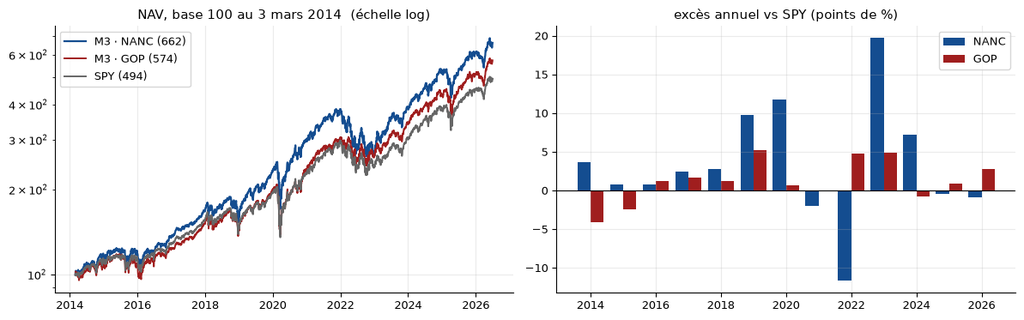

```python
fig, ax = plt.subplots(1, 2, figsize=(12, 3.8))
ax[0].plot(M3["NANC"].index, M3["NANC"], color=BLEU,  lw=1.6, label=f"M3 · NANC ({M3['NANC'].iloc[-1]:.0f})")
ax[0].plot(M3["GOP"].index,  M3["GOP"],  color=ROUGE, lw=1.4, label=f"M3 · GOP ({M3['GOP'].iloc[-1]:.0f})")
ax[0].plot(nav_spy_m3.index, nav_spy_m3, color=GRIS,  lw=1.4, label=f"SPY ({nav_spy_m3.iloc[-1]:.0f})")
ax[0].set_yscale("log"); ax[0].set_title("NAV, base 100 au 3 mars 2014  (échelle log)"); ax[0].legend()
ax[1].bar(xN_.index - 0.2, xN_.values, width=0.4, color=BLEU,  label="NANC")
ax[1].bar(xG_.index + 0.2, xG_.values, width=0.4, color=ROUGE, label="GOP")
ax[1].axhline(0, color="k", lw=.8); ax[1].set_title("excès annuel vs SPY (points de %)"); ax[1].legend()
plt.tight_layout(); plt.savefig(f"{FIGS}/m3_nav.png", dpi=150, bbox_inches="tight"); plt.show()
```

### §6.3 — À quoi ressemble le portefeuille

```python
i_fin = coupes[-2]
lignes, tops = [], {}
for nom in ["NANC", "GOP"]:
    w = 100 * pd.Series(WPM[("M3 · $ × élus", nom)][i_fin]).sort_values(ascending=False)
    mx, t5, ne = conc(w)
    n_cap = int((w > 100*CAP - 1e-9).sum())            # combien de lignes touchent effectivement le plafond
    lignes.append({"fonds": nom, "titres": len(w), "plus gros poids %": mx, "top-5 %": t5, "N_eff": ne,
                   "lignes au plafond": n_cap})
    tops[nom] = w.head(10).round(2)
display(pd.DataFrame(lignes).set_index("fonds"))
print(f"\ntop-10 à la coupe du {cal[i_fin].date()} :")
display(pd.DataFrame(tops).fillna(""))
print("\nnombre de lignes au plafond, en médiane sur toutes les coupes :")
for nom in ["NANC", "GOP"]:
    m = np.median([sum(1 for x in w.values() if x > CAP - 1e-9)
                   for w in WPM[("M3 · $ × élus", nom)].values() if w])
    print(f"   {nom} : {m:.0f}")
```

| fonds | titres | plus gros poids % | top-5 % | N_eff | lignes au plafond |
| --- | --- | --- | --- | --- | --- |
| NANC | 150 | 10.0 | 42.2 | 21.6 | 1 |
| GOP | 150 | 9.0 | 32.6 | 32.7 | 0 |

```
top-10 à la coupe du 2026-05-29 :
```

|  | NANC | GOP |
| --- | --- | --- |
| AAPL | 6.34 | 8.26 |
| AMD |  | 2.15 |
| AMZN | 7.94 | 3.22 |
| AVGO | 6.07 |  |
| COP |  | 1.98 |
| GOOG | 9.95 | 4.19 |
| META | 3.28 | 3.68 |
| MSFT | 7.92 | 8.98 |
| NFLX | 1.39 |  |
| NVDA | 10.0 | 6.39 |
| PANW | 5.19 |  |
| TSM | 1.42 |  |
| UNH |  | 4.82 |
| V |  | 2.28 |

```
nombre de lignes au plafond, en médiane sur toutes les coupes :
   NANC : 2
   GOP : 1
```

## §7 — D'où vient l'excès : dollars, consensus, ou ni l'un ni l'autre ?

Les deux informations du score, séparées **à univers identique** — les 150 titres restent ceux du score complet, seule la pondération change :

| variante | poids | ce qu'elle isole |
| --- | --- | --- |
| **M2 · dollars purs** | $w \propto B_i$ | l'argent misé, sans le consensus |
| **élus seuls** | $w \propto m_i$ | le consensus, sans l'argent |
| **équipondéré** | $w = 1/150$ | ni l'un ni l'autre : la sélection seule |
| **M3** | $w \propto B_i m_i$ | les deux |

**Décomposition, pas compétition** : le verdict se lit sur la ligne M3.

```python
ORD = ["équipondéré", "élus seuls", "M2 · dollars purs", "M3 · $ × élus"]
DEC = pd.DataFrame([bilan_ic(SER[(m, nom)], f"{m} — {nom}") for nom in ["NANC", "GOP"] for m in ORD]).set_index("run")
display(DEC[["excès %/an", "t", "IC bas", "IC haut", "α %/an", "t_α", "β", "NAV"]].round(2))

# les mêmes runs vus par le modèle à quatre facteurs : un repère n'a de sens qu'à filtre ET univers identiques
# à ce qu'il éclaire — ces lignes sont donc toutes à θ = ∞, comme M3.
DECF = pd.DataFrame([facteurs(SER[(m, nom)], f"{m} — {nom}") for nom in ["NANC", "GOP"] for m in ORD]).set_index("run")
display(DECF[["α %/an", "t_α"] + FACS].round(3))
```

| run | excès %/an | t | IC bas | IC haut | α %/an | t_α | β | NAV |
| --- | --- | --- | --- | --- | --- | --- | --- | --- |
| équipondéré — NANC | -1.38 | -1.45 | -3.46 | 0.70 | -0.95 | -0.72 | 0.98 | 430.18 |
| élus seuls — NANC | -0.65 | -0.91 | -2.22 | 0.92 | -0.41 | -0.38 | 0.99 | 463.52 |
| M2 · dollars purs — NANC | 1.43 | 1.04 | -1.58 | 4.44 | 0.37 | 0.40 | 1.05 | 554.22 |
| M3 · $ × élus — NANC | 3.40 | 1.61 | -1.19 | 7.99 | 1.66 | 1.36 | 1.08 | 661.57 |
| équipondéré — GOP | -1.08 | -0.71 | -4.39 | 2.22 | -0.67 | -0.44 | 0.96 | 447.77 |
| élus seuls — GOP | -0.78 | -0.75 | -3.04 | 1.49 | -0.17 | -0.14 | 0.96 | 465.58 |
| M2 · dollars purs — GOP | 0.49 | 0.26 | -3.62 | 4.60 | 0.17 | 0.10 | 1.00 | 522.63 |
| M3 · $ × élus — GOP | 1.24 | 1.61 | -0.44 | 2.91 | 1.09 | 1.07 | 1.00 | 573.57 |

| run | α %/an | t_α | Mkt-RF | SMB | HML | Mom |
| --- | --- | --- | --- | --- | --- | --- |
| équipondéré — NANC | 0.052 | 0.055 | 0.955 | 0.018 | 0.140 | -0.097 |
| élus seuls — NANC | 0.384 | 0.495 | 0.962 | -0.039 | 0.097 | -0.094 |
| M2 · dollars purs — NANC | 0.986 | 1.304 | 1.019 | -0.067 | -0.058 | -0.073 |
| M3 · $ × élus — NANC | 2.092 | 2.080 | 1.047 | -0.131 | -0.146 | -0.076 |
| équipondéré — GOP | 0.415 | 0.430 | 0.938 | 0.039 | 0.212 | -0.100 |
| élus seuls — GOP | 0.589 | 0.728 | 0.938 | -0.057 | 0.148 | -0.099 |
| M2 · dollars purs — GOP | 1.227 | 1.015 | 0.974 | 0.057 | 0.171 | -0.083 |
| M3 · $ × élus — GOP | 1.652 | 1.792 | 0.979 | -0.081 | 0.049 | -0.073 |

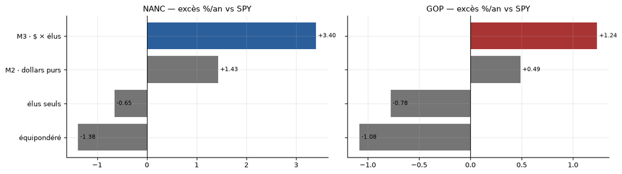

```python
fig, ax = plt.subplots(1, 2, figsize=(12, 3.4), sharey=True)
for k, nom in enumerate(["NANC", "GOP"]):
    v = [bilan(SER[(m, nom)], m)["excès %/an"] for m in ORD]
    ax[k].barh(range(len(ORD)), v, color=[GRIS, GRIS, GRIS, BLEU if nom == "NANC" else ROUGE], alpha=.9)
    ax[k].set_yticks(range(len(ORD))); ax[k].set_yticklabels(ORD)
    ax[k].axvline(0, color="k", lw=.8); ax[k].set_title(f"{nom} — excès %/an vs SPY")
    for j, x in enumerate(v): ax[k].text(x, j, f" {x:+.2f}", va="center", fontsize=8)
plt.tight_layout(); plt.savefig(f"{FIGS}/m3_decomposition.png", dpi=150, bbox_inches="tight"); plt.show()
```

### §7.1 — Le filtre anti-bruit, et son balayage publié en entier

- 300 opérations déclarées le même jour $\ne$ 300 décisions : c'est un courtier qui rééquilibre un mandat ;
- **$\theta = 50$ est déclaré d'avance** — description d'un gérant du fonds, pas un réglage sur nos rendements ;
- balayage publié **en entier** pour montrer la pente, pas pour choisir. M3 ne l'applique pas, M4 si.

```python
for parti, nom in PARTIS:
    tot = df[(df.party == parti) & (df.op == "buy")].A.sum()
    ecarte = df[(df.party == parti) & (df.op == "buy") & (df.taille_depot >= SEUIL_BRUIT)].A.sum()
    print(f"{nom} : le filtre θ={SEUIL_BRUIT} écarte {100*ecarte/tot:.0f} % du $ acheté "
          f"({ecarte/1e6:,.0f} M$ sur {tot/1e6:,.0f})")

BAL = []
for nom in ["NANC", "GOP"]:
    for lab in ["θ = 10", "θ = 20", "M4 · + filtre θ=50", "θ = 100", "M3 · $ × élus"]:
        b = bilan(SER[(lab, nom)], lab)
        BAL.append({"fonds": nom, "θ": {"M4 · + filtre θ=50": "θ = 50  (M4)",
                                        "M3 · $ × élus": "θ = ∞  (M3)"}.get(lab, lab),
                    "excès %/an": b["excès %/an"], "t": b["t"], "α %/an": b["α %/an"],
                    "t_α": b["t_α"], "β": b["β"], "NAV": b["NAV"]})
display(pd.DataFrame(BAL).set_index(["fonds", "θ"]).round(2))
print("↑ balayage publié en entier — le verdict de la méthode se lit à θ = ∞ (M3), celui de M4 à θ = 50")
```

```
NANC : le filtre θ=50 écarte 54 % du $ acheté (388 M$ sur 716)
GOP : le filtre θ=50 écarte 58 % du $ acheté (514 M$ sur 891)
```

| fonds | θ | excès %/an | t | α %/an | t_α | β | NAV |
| --- | --- | --- | --- | --- | --- | --- | --- |
| NANC | θ = 10 | 4.71 | 1.07 | 0.60 | 0.25 | 1.15 | 634.37 |
|  | θ = 20 | 4.62 | 1.10 | 0.78 | 0.33 | 1.15 | 642.63 |
|  | θ = 50 (M4) | 5.14 | 1.30 | 1.42 | 0.65 | 1.15 | 699.97 |
|  | θ = 100 | 4.75 | 1.31 | 1.36 | 0.69 | 1.14 | 692.30 |
|  | θ = ∞ (M3) | 3.40 | 1.61 | 1.66 | 1.36 | 1.08 | 661.57 |
| GOP | θ = 10 | 3.02 | 1.75 | 2.77 | 1.75 | 0.99 | 706.64 |
|  | θ = 20 | 2.14 | 1.44 | 1.88 | 1.28 | 0.99 | 637.64 |
|  | θ = 50 (M4) | 1.44 | 0.98 | 1.54 | 1.19 | 0.98 | 589.88 |
|  | θ = 100 | 1.64 | 1.73 | 1.60 | 1.48 | 0.99 | 602.79 |
|  | θ = ∞ (M3) | 1.24 | 1.61 | 1.09 | 1.07 | 1.00 | 573.57 |

```
↑ balayage publié en entier — le verdict de la méthode se lit à θ = ∞ (M3), celui de M4 à θ = 50
```

## §8 — Première épreuve : le risque

Un excès peut n'être qu'un pari de style rémunéré $\Rightarrow$ régression sur les quatre facteurs de Fama-French-Carhart.

**Lecture des chargements** : $\beta_S < 0$ = **grandes** capitalisations · $\beta_H < 0$ = **croissance** plutôt que *value* · $\beta_U$ = exposition au **momentum**.

```python
FAC = pd.DataFrame([facteurs(M3[nom], f"M3 · {nom}") for nom in ["NANC", "GOP"]]
                   + [facteurs(nav_spy_full, "SPY (repère)")]).set_index("run")
display(FAC[["α %/an", "t_α"] + FACS + ["n j"]].round(3))
print("\nà comparer à l'α du modèle marché seul :")
display(pd.DataFrame([bilan(M3[nom], f"M3 · {nom}") for nom in ["NANC", "GOP"]]).set_index("run")[["α %/an", "t_α", "β"]].round(3))
```

| run | α %/an | t_α | Mkt-RF | SMB | HML | Mom | n j |
| --- | --- | --- | --- | --- | --- | --- | --- |
| M3 · NANC | 2.092 | 2.080 | 1.047 | -0.131 | -0.146 | -0.076 | 3059 |
| M3 · GOP | 1.652 | 1.792 | 0.979 | -0.081 | 0.049 | -0.073 | 3059 |
| SPY (repère) | 0.040 | 0.115 | 0.980 | -0.123 | 0.012 | -0.009 | 3352 |

```
à comparer à l'α du modèle marché seul :
```

| run | α %/an | t_α | β |
| --- | --- | --- | --- |
| M3 · NANC | 1.660 | 1.357 | 1.080 |
| M3 · GOP | 1.093 | 1.067 | 1.004 |

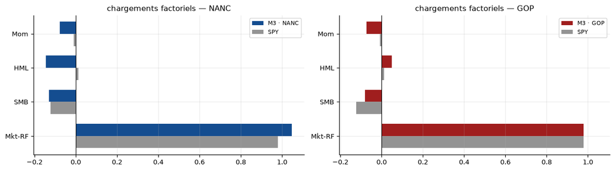

```python
fig, ax = plt.subplots(1, 2, figsize=(12, 3.4), sharex=True)
for k, nom in enumerate(["NANC", "GOP"]):
    v = [FAC.loc[f"M3 · {nom}", c] for c in FACS]
    s = [FAC.loc["SPY (repère)", c] for c in FACS]
    y = np.arange(len(FACS))
    ax[k].barh(y + .18, v, height=.36, color=BLEU if nom == "NANC" else ROUGE, label=f"M3 · {nom}")
    ax[k].barh(y - .18, s, height=.36, color=GRIS, alpha=.7, label="SPY")
    ax[k].set_yticks(y); ax[k].set_yticklabels(FACS); ax[k].axvline(0, color="k", lw=.8)
    ax[k].set_title(f"chargements factoriels — {nom}"); ax[k].legend(fontsize=8)
plt.tight_layout(); plt.savefig(f"{FIGS}/m3_facteurs.png", dpi=150, bbox_inches="tight"); plt.show()
```

### §8.1 — $\alpha$ et $\beta$ glissants sur 252 jours

Les chiffres ci-dessus sont *plein-échantillon* : douze ans écrasés en un nombre. On les regarde au fil du temps, sur une fenêtre glissante d'un an : $\;\hat\beta_t = \mathrm{cov}_W(y,x)/\mathrm{var}_W(x)$, $\;\hat\alpha_t = (\bar y_W - \hat\beta_t \bar x_W)\times 252$.

```
NANC — β glissant méd 1.06 [0.95 ; 1.27] σ 0.07  ·  α glissant méd +2.01 %/an [-11.0 ; +13.2] · α > 0 71 % du temps
GOP — β glissant méd 1.00 [0.90 ; 1.13] σ 0.05  ·  α glissant méd +1.67 %/an [-6.0 ; +8.0] · α > 0 71 % du temps
```

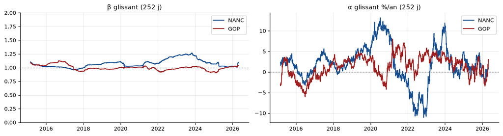

```python
RA = {nom: roll_ab(M3[nom]) for nom in ["NANC", "GOP"]}
for nom in ["NANC", "GOP"]:
    aa, bb, _, _ = RA[nom]
    print(f"{nom} — β glissant méd {bb.median():.2f} [{bb.min():.2f} ; {bb.max():.2f}] σ {bb.std():.2f}  ·  "
          f"α glissant méd {aa.median():+.2f} %/an [{aa.min():+.1f} ; {aa.max():+.1f}] · α > 0 {100*(aa>0).mean():.0f} % du temps")

fig, ax = plt.subplots(1, 2, figsize=(12, 3.3))
for nom, c in [("NANC", BLEU), ("GOP", ROUGE)]:
    aa, bb, _, _ = RA[nom]
    ax[0].plot(bb.index, bb, color=c, lw=1.4, label=nom)
    ax[1].plot(aa.index, aa, color=c, lw=1.4, label=nom)
ax[0].axhline(1, color=GRIS, ls=":", lw=1); ax[0].set_ylim(0, 2)
ax[0].set_title(f"β glissant ({Wab} j)"); ax[0].legend()
ax[1].axhline(0, color=GRIS, ls=":", lw=1); ax[1].set_title(f"α glissant %/an ({Wab} j)"); ax[1].legend()
plt.tight_layout(); plt.savefig(f"{FIGS}/m3_rolling.png", dpi=150, bbox_inches="tight"); plt.show()
```

### §8.2 — Validation : le glissant est bien une régression

- `cov/var` et `ȳ − β x̄` doivent redonner, sur une fenêtre donnée, exactement les moindres carrés ;
- le $\beta$ plein-échantillon doit retomber sur celui du §6.

```python
for nom in ["NANC", "GOP"]:
    aa, bb, y, x = RA[nom]
    # (1) sur la dernière fenêtre de 252 jours, comparer à np.polyfit
    yy, xx = y.iloc[-Wab:].values, x.iloc[-Wab:].values
    b_p, a_p = np.polyfit(xx, yy, 1)
    assert abs(bb.iloc[-1] - b_p) < 1e-9,       f"{nom} : β glissant ≠ polyfit ({bb.iloc[-1]:.9f} vs {b_p:.9f})"
    assert abs(aa.iloc[-1] - a_p*252*100) < 1e-6, f"{nom} : α glissant ≠ polyfit"
    # (2) le β plein-échantillon du même chemin doit retomber sur celui du bilan
    b_full = np.polyfit(x.values, y.values, 1)[0]
    assert abs(b_full - MES[(nom, "β")]) < 1e-9, f"{nom} : β plein-échantillon {b_full:.6f} ≠ bilan {MES[(nom,'β')]:.6f}"
    print(f"✅ {nom} — glissant ≡ polyfit (β {bb.iloc[-1]:.6f}) · β plein-échantillon {b_full:.4f} ≡ celui du §6")
```

```
✅ NANC — glissant ≡ polyfit (β 1.092262) · β plein-échantillon 1.0804 ≡ celui du §6
✅ GOP — glissant ≡ polyfit (β 1.035564) · β plein-échantillon 1.0037 ≡ celui du §6
```

## §9 — Seconde épreuve : le coût

- **ce que ça coûte** — $\mathrm{TO}_t$ facturée $V_t \leftarrow V_t\,(1 - 2\,\mathrm{TO}_t\,c)$, avec $c = 10$ points de base (0,10 %) ; facteur 2 : achat **et** vente ;
- **faut-il ralentir** — brider à $\tau_{\max}$ par mois, $\lambda_R = \min(1, \tau_{\max}/\mathrm{TO}_t)$, actif seulement si $\mathrm{TO}_t > \tau_{\max}$. Balayage publié **en entier**, règle écrite d'avance : *on ne retient le frein que s'il améliore les deux partis* ;
- **pourquoi M3 est lente** — fenêtre de trois ans : un trente-sixième du signal se renouvelle par mois, contre la moitié pour une fenêtre d'un mois.

```python
COUT_BPS = 10.0                                   # pb par aller-retour — DÉCLARÉ AVANT tout résultat
PLAFONDS = [np.inf, 0.25, 0.10, 0.05, 0.02]       # τ_max testés, publiés en entier

def rotation(WP, tau_max=np.inf, cuts=None):
    # rotation RÉALISÉE, telle que le moteur la produit (≠ celle de la cible dès que le frein mord)
    cuts = coupes if cuts is None else cuts
    _, tr = run_livre(WP, tau_max, cuts=cuts)
    idx = pd.DatetimeIndex([cal[cuts[j]+1] for j in range(1, len(cuts)-1)][:len(tr)])
    s   = pd.Series(tr, index=idx)
    n   = s.groupby(s.index.year).size()
    return s, 100*s.groupby(s.index.year).sum()[n[n >= 6].index]     # années complètes seulement

VIT, ROT = [], {}
for nom in ["NANC", "GOP"]:
    mens, an = rotation(WPM[("M3 · $ × élus", nom)])
    ROT[nom] = an
    VIT.append({"fonds": nom, "rotation méd. %/mois": 100*mens.median(),
                "rotation méd. %/an": an.median(), "rotation moy. %/an": an.mean(),
                "min %/an": an.min(), "max %/an": an.max()})
display(pd.DataFrame(VIT).set_index("fonds").round(1))
print("le fonds réel publie 44 · 62 · 10 % pour NANC et 46 · 54 · 16 % pour GOP (exercices 2023, 2024, 2025)")
print("⚠️ moyenne ≫ médiane : quelques années de forte recomposition tirent le coût — c'est la MOYENNE qui le fixe")
```

| fonds | rotation méd. %/mois | rotation méd. %/an | rotation moy. %/an | min %/an | max %/an |
| --- | --- | --- | --- | --- | --- |
| NANC | 4.9 | 65.6 | 71.8 | 33.6 | 139.6 |
| GOP | 5.3 | 69.2 | 76.9 | 35.8 | 164.4 |

[output not shown]

```python
COUT = []
for nom in ["NANC", "GOP"]:
    brut = SER[("M3 · $ × élus", nom)]
    net  = run_livre(WPM[("M3 · $ × élus", nom)], np.inf, cout_bps=COUT_BPS)[0]
    bb, bn = bilan(brut, nom), bilan(net, nom)
    COUT.append({"fonds": nom, "excès brut %/an": bb["excès %/an"], "excès net %/an": bn["excès %/an"],
                 "coût pt/an": bb["excès %/an"] - bn["excès %/an"],
                 "α₁ net": bn["α %/an"], "t_α₁ net": bn["t_α"], "β net": bn["β"],
                 "α₄ brut": facteurs(brut, nom)["α %/an"], "α₄ net": facteurs(net, nom)["α %/an"],
                 "NAV brute": bb["NAV"], "NAV nette": bn["NAV"]})
display(pd.DataFrame(COUT).set_index("fonds").round(2))
```

| fonds | excès brut %/an | excès net %/an | coût pt/an | α₁ net | t_α₁ net | β net | α₄ brut | α₄ net | NAV brute | NAV nette |
| --- | --- | --- | --- | --- | --- | --- | --- | --- | --- | --- |
| NANC | 3.40 | 3.23 | 0.17 | 1.51 | 1.23 | 1.08 | 2.09 | 1.94 | 661.57 | 648.69 |
| GOP | 1.24 | 1.06 | 0.18 | 0.93 | 0.91 | 1.00 | 1.65 | 1.49 | 573.57 | 561.66 |

```python
# VALIDATION §9 — contrôle EXACT : les poids étant invariants d'échelle, facturer des frais ne change pas
# les rotations, seulement le niveau de la NAV. Donc NAV_nette / NAV_brute doit valoir exactement
#     ∏_t (1 − 2·TO_t·c)   sur TOUTES les coupes, premier déploiement compris (TO = ½ : on achète tout une fois).
for nom in ["NANC", "GOP"]:
    WP = WPM[("M3 · $ × élus", nom)]
    brut = run_livre(WP, np.inf)[0]
    net, tr = run_livre(WP, np.inf, cout_bps=COUT_BPS)
    facteur = (1 - 2*0.5*COUT_BPS/1e4) * np.prod(1 - 2*tr*COUT_BPS/1e4)   # ½ = le 1er déploiement
    observe = net.iloc[-1] / brut.iloc[-1]
    assert abs(observe - facteur) < 1e-12, f"{nom} : ratio {observe:.12f} ≠ ∏(1−2·TO·c) = {facteur:.12f}"
    print(f"✅ {nom} — NAV nette / NAV brute = {observe:.9f} ≡ ∏(1 − 2·TO·c) sur {len(tr)+1} coupes "
          f"(écart {abs(observe-facteur):.1e})")
    print(f"     soit {brut.iloc[-1]:.2f} → {net.iloc[-1]:.2f} · rotation moyenne {ROT[nom].mean():.0f} %/an "
          f"× 2 × {COUT_BPS:.0f} pb ≈ {2*ROT[nom].mean()/100*COUT_BPS/1e4*100:.2f} pt/an")
```

```
✅ NANC — NAV nette / NAV brute = 0.980522274 ≡ ∏(1 − 2·TO·c) sur 148 coupes (écart 7.8e-16)
     soit 661.57 → 648.69 · rotation moyenne 72 %/an × 2 × 10 pb ≈ 0.14 pt/an
✅ GOP — NAV nette / NAV brute = 0.979224158 ≡ ∏(1 − 2·TO·c) sur 148 coupes (écart 3.8e-15)
     soit 573.57 → 561.66 · rotation moyenne 77 %/an × 2 × 10 pb ≈ 0.15 pt/an
```

### §9.1 — Faut-il ralentir ? Le balayage du frein, net de frais

La règle a été écrite avant de regarder : **on ne retient le frein que s'il améliore les deux partis.**

| fonds | τ_max | excès net %/an | t | α %/an | NAV |
| --- | --- | --- | --- | --- | --- |
| NANC | aucun | 3.23 | 1.54 | 1.51 | 648.69 |
|  | 25 %/mois | 3.24 | 1.54 | 1.51 | 649.20 |
|  | 10 %/mois | 3.25 | 1.55 | 1.51 | 650.38 |
|  | 5 %/mois | 3.26 | 1.55 | 1.56 | 652.10 |
|  | 2 %/mois | 3.16 | 1.56 | 1.58 | 649.30 |
| GOP | aucun | 1.06 | 1.35 | 0.93 | 561.66 |
|  | 25 %/mois | 1.02 | 1.27 | 0.89 | 559.29 |
|  | 10 %/mois | 1.01 | 1.28 | 0.89 | 558.87 |
|  | 5 %/mois | 1.13 | 1.44 | 1.08 | 569.40 |
|  | 2 %/mois | 0.58 | 0.77 | 0.79 | 538.34 |

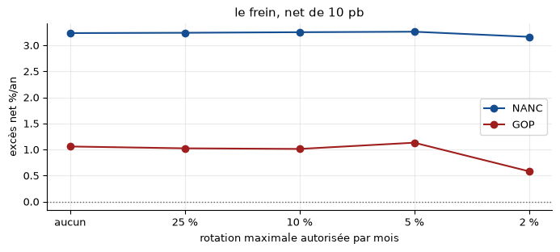

```
gain (ou perte) par rapport à l'absence de frein, en points de % par an :
    25 %/mois — NANC +0.01 · GOP -0.04   → min -0.04
    10 %/mois — NANC +0.02 · GOP -0.05   → min -0.05
     5 %/mois — NANC +0.03 · GOP +0.07   → min +0.03
     2 %/mois — NANC -0.07 · GOP -0.48   → min -0.48

→ RÈGLE DÉCLARÉE D'AVANCE : le frein n'est retenu que s'il améliore les DEUX partis.
   plafonds qui passent la règle : ['5 %/mois']

   profil du gain minimal, du plafond le plus lâche au plus serré :
      -0.04 → -0.05 → +0.03 → -0.48
   2 changement(s) de signe sur 3 pas.
   ⚠️ le seul plafond qui passe la règle est ENTOURÉ de plafonds qui échouent. Serrer la
      contrainte devrait agir dans un sens, pas alterner : ce profil est celui du bruit, pas
      d'un effet. Le gain de +0.03 pt est du même ordre que l'écart entre voisins.
   → le frein n'est PAS retenu : la règle est nécessaire, elle n'est pas suffisante.
```

```python
FREIN = []
for nom in ["NANC", "GOP"]:
    for tm in PLAFONDS:
        v = run_livre(WPM[("M3 · $ × élus", nom)], tm, cout_bps=COUT_BPS)[0]
        b = bilan(v, nom)
        FREIN.append({"fonds": nom, "τ_max": "aucun" if tm == np.inf else f"{100*tm:.0f} %/mois",
                      "excès net %/an": b["excès %/an"], "t": b["t"], "α %/an": b["α %/an"], "NAV": b["NAV"]})
FREIN = pd.DataFrame(FREIN)
display(FREIN.set_index(["fonds", "τ_max"]).round(2))

fig, ax = plt.subplots(figsize=(7, 3.2))
for nom, c in [("NANC", BLEU), ("GOP", ROUGE)]:
    s = FREIN[FREIN.fonds == nom]
    ax.plot(range(len(PLAFONDS)), s["excès net %/an"].values, "o-", color=c, lw=1.5, label=nom)
ax.set_xticks(range(len(PLAFONDS))); ax.set_xticklabels(["aucun", "25 %", "10 %", "5 %", "2 %"])
ax.set_xlabel("rotation maximale autorisée par mois"); ax.set_ylabel("excès net %/an")
ax.axhline(0, color=GRIS, ls=":", lw=1); ax.set_title(f"le frein, net de {COUT_BPS:.0f} pb"); ax.legend()
plt.tight_layout(); plt.savefig(f"{FIGS}/m3_frein.png", dpi=150, bbox_inches="tight"); plt.show()

g = FREIN[FREIN["τ_max"] != "aucun"].merge(
    FREIN[FREIN["τ_max"] == "aucun"][["fonds", "excès net %/an"]].rename(columns={"excès net %/an": "sans frein"}),
    on="fonds")
g["gain pt"] = g["excès net %/an"] - g["sans frein"]
lbl = [f"{100*tm:.0f} %/mois" for tm in PLAFONDS[1:]]                 # du plus lâche au plus serré
print("gain (ou perte) par rapport à l'absence de frein, en points de % par an :")
for k in lbl:
    s = g[g["τ_max"] == k].set_index("fonds")["gain pt"]
    print(f"   {k:>10s} — NANC {s['NANC']:+.2f} · GOP {s['GOP']:+.2f}   → min {s.min():+.2f}")
ok = g.groupby("τ_max")["gain pt"].min()
gagnants = [k for k in lbl if ok[k] > 0]
print(f"\n→ RÈGLE DÉCLARÉE D'AVANCE : le frein n'est retenu que s'il améliore les DEUX partis.")
print(f"   aucun plafond ne le fait — le frein n'est pas retenu" if not gagnants
      else f"   plafonds qui passent la règle : {gagnants}")

# ── le test qui tranche : un effet réel serait MONOTONE en τ_max ──
serie = [ok[k] for k in lbl]                      # du plus lâche (25 %) au plus serré (2 %)
signes = [np.sign(x) for x in serie]
alterne = sum(1 for a, b in zip(signes, signes[1:]) if a != b)
print(f"\n   profil du gain minimal, du plafond le plus lâche au plus serré :")
print("      " + " → ".join(f"{ok[k]:+.2f}" for k in lbl))
print(f"   {alterne} changement(s) de signe sur {len(lbl)-1} pas.")
if gagnants and alterne >= 2:
    print(f"   ⚠️ le seul plafond qui passe la règle est ENTOURÉ de plafonds qui échouent. Serrer la")
    print(f"      contrainte devrait agir dans un sens, pas alterner : ce profil est celui du bruit, pas")
    print(f"      d'un effet. Le gain de {max(ok):+.2f} pt est du même ordre que l'écart entre voisins.")
    print(f"   → le frein n'est PAS retenu : la règle est nécessaire, elle n'est pas suffisante.")
```

## §10 — Le netting des ventes

Le fonds réel *nette* : une vente réduit la position. On l'applique **et rien d'autre** — même fenêtre, même score, même top-150, même plafond. Cela exige le **FIFO plein historique** (quelles tranches une vente consomme, et depuis quand), repris du nb 11 dans les trois cellules suivantes.

```python
from collections import deque                      # le FIFO ci-dessous en a besoin
df["sgn"] = np.where(df.op == "buy", 1.0, -1.0)   # +1 achat / -1 vente
CAP17, coupes17 = CAP, coupes   # le nb11 nommait ainsi le plafond (10 %) et le calendrier conforme
print(f"prêt pour le netting : {len(df):,} opérations, plafond {100*CAP17:.0f} %, "
      f"{len(coupes17)} coupes")
```

```
prêt pour le netting : 113,369 opérations, plafond 10 %, 149 coupes
```

```python
def tranches_vendues(g):
    # pour chaque vente : la liste des (h, q) consommés, et la part non appariée
    lots, out = deque(), {}
    for idx, i0, op, A in zip(g.index.values, g.i0.values, g.op.values, g.A.values):
        p = PXV[g.tk.iat[0]][i0]
        if not np.isfinite(p) or p <= 0: continue
        q = A / p
        if op == "buy":
            lots.append([i0, q])
        else:
            reste, pieces = q, []
            while reste > 1e-12 and lots:
                s0, q0 = lots[0]
                pris = min(reste, q0); reste -= pris; lots[0][1] -= pris
                pieces.append((i0 - s0, pris))          # (h, q)
                if lots[0][1] <= 1e-12: lots.popleft()
            out[idx] = (pieces, reste)                  # reste = part non appariée
    return out
```

```python
VENTES = {}
for (_, _), g in df.groupby(["bioguide_id","tk"], sort=False):
    VENTES.update(tranches_vendues(g))
n_v = (df.op == "sell").sum()
print(f"ventes traitées : {len(VENTES):,} / {n_v:,}")
```

```
ventes traitées : 55,061 / 55,924
```

```python
# γ à 3 ANS (756 j) — MÊME FIFO plein historique que §3/§4, seuil = fenêtre du prospectus (≠ 504 du ticker).
# La purge γ vend les VIEUX lots d'abord : une vente d'un lot détenu >3 ans a γ3→0 (« acquis avant le lookback,
# n'ajuste pas le portefeuille » — prospectus) ; seule la part récente d'une vente réduit la position.
A_BAR3 = W3                                                    # 756 j de bourse ≈ 3 ans
gam3   = np.ones(len(df))
for idx, (pieces, reste) in VENTES.items():
    tot = sum(q for _, q in pieces) + reste
    if tot <= 0: continue
    jeune    = sum(q for h, q in pieces if h <= A_BAR3) + reste    # part détenue <= 3 ans (+ non apparié)
    gam3[idx] = jeune / tot
df["Aeff3"]   = df.A * np.where(df.op == "buy", 1.0, gam3)    # A (achat) · A·γ3 (vente : part récente)
df["signed3"] = df.Aeff3 * df.sgn                            # +A (achat) / −A·γ3 (vente récente)
print(f"γ₃ calculé sur {len(VENTES):,} ventes · "
      f"part récente médiane {np.median([gam3[i] for i in VENTES]):.3f}")
```

```
γ₃ calculé sur 55,061 ventes · part récente médiane 1.000
```

```python
# ── §17.1 · le NETTING isolé — M3 à l'identique, sauf que les ventes récentes réduisent la position ──
def poids_netting(i1, parti, topN=150, cap=CAP17, netter=True):
    # netter=False ⇒ les ventes sont ignorées ⇒ doit reproduire poids_methode(seuil=∞) BIT-EXACT.
    lo, hi = np.searchsorted(I_de, i1 - W3, "right"), np.searchsorted(I_de, i1, "right")
    g = df.iloc[ordre_d[lo:hi]]
    g = g[g.party == parti] if netter else g[(g.party == parti) & (g.op == "buy")]
    if not len(g): return {}
    tkm = g.tk.map(lambda t: FUSION.get(t, t)).values
    sg  = g.A.values * np.where(g.op.values == "buy", 1.0, -gam3[g.index.values])
    per = pd.Series(sg).groupby([g.bioguide_id.values, tkm]).sum()
    per = per[per > 0]                                  # plancher 0 PAR ÉLU : jamais de position négative
    if not len(per): return {}
    neti, mi = per.groupby(level=1).sum(), per.groupby(level=1).size()
    score = (neti * mi).dropna()
    score = score[[t for t in score.index if t in PXV and np.isfinite(PXV[t][i1 + 1]) and vivant(t, i1)]]
    score = score.sort_values(ascending=False).head(topN)
    if not len(score) or score.sum() <= 0: return {}
    return cap_poids(score / score.sum(), cap).to_dict()

# (1) CONTRÔLE D'IDENTITÉ — sans netting on doit retrouver M3, sinon le run mesurerait autre chose
for _p, _n in PARTIS:
    for _i in coupes17[3:-1:37]:
        _a = poids_netting(_i, _p, netter=False)
        _b = poids_methode(_i, _p, topN=150, cap=CAP17, seuil=np.inf)
        assert set(_a) == set(_b), f"{_n} {_i} : univers ≠ M3"
        assert max(abs(_a[k] - _b[k]) for k in _a) < 1e-12, f"{_n} {_i} : poids ≠ M3"
print("✅ (1) sans netting ≡ M3 à 1e-12 (mêmes titres, mêmes poids) — SEUL le netting distingue les 2 runs")

# (2) le netting, les DEUX partis, sur le calendrier conforme
NET17, WPNET = [], {}
for _p, _n in PARTIS:
    WPNET[_n] = {i: poids_netting(i, _p) for i in coupes17[:-1]}
    for i in coupes17[:-1]:
        if WPNET[_n][i]:
            assert abs(sum(WPNET[_n][i].values()) - 1) < 1e-9, f"{_n} : Σw ≠ 1 à la coupe {i}"
            assert max(WPNET[_n][i].values()) <= CAP17 + 1e-12, f"{_n} : plafond dépassé à {i}"
    _v = run_livre(WPNET[_n], np.inf, cuts=coupes17)[0]
    _b = bilan_ic(_v, f"{_n} · netting isolé")
    _r = bilan(M3[_n], f"M3 · référence — {_n}")   # le nb11 lisait T17 ; ici M3 est déjà mesurée
    NET17.append({"fonds": _n, "M3 excès %/an": _r["excès %/an"], "netting excès %/an": _b["excès %/an"],
                  "écart pt": _b["excès %/an"] - _r["excès %/an"], "t": _b["t"],
                  "α₁ %/an": _b["α %/an"], "NAV M3": _r["NAV"], "NAV netting": _b["NAV"]})
NET17 = pd.DataFrame(NET17).set_index("fonds")
print("\nle netting des ventes, TOUTES choses égales par ailleurs (cap 10 %, top-150, calendrier conforme) :")
display(NET17.round(2))

# (3) combien de titres le netting fait-il disparaître, et quelle part du $ efface-t-il ?
_dg = []
for _p, _n in PARTIS:
    _c = coupes17[-2]
    _s = len(poids_netting(_c, _p)); _m = len(poids_methode(_c, _p, topN=150, cap=CAP17, seuil=np.inf))
    _lo, _hi = np.searchsorted(I_de, _c - W3, "right"), np.searchsorted(I_de, _c, "right")
    _g = df.iloc[ordre_d[_lo:_hi]]; _g = _g[_g.party == _p]
    _ach = _g[_g.op == "buy"].A.sum()
    _ven = (_g[_g.op != "buy"].A.values * gam3[_g[_g.op != "buy"].index.values]).sum()
    _dg.append({"fonds": _n, "titres M3": _m, "titres nettés": _s,
                "$ acheté (M$)": _ach / 1e6, "$ effacé par γ₃ (M$)": _ven / 1e6,
                "part effacée %": 100 * _ven / _ach})
print("\nà la dernière coupe — ce que le netting retire :")
display(pd.DataFrame(_dg).set_index("fonds").round(1))

_ecarts = NET17["écart pt"]
print(f"\n→ RÈGLE DÉCLARÉE D'AVANCE (celle qui a écarté le frein) : une variante n'est retenue que si elle "
      f"améliore les DEUX partis.\n   écart NANC {_ecarts['NANC']:+.2f} pt · GOP {_ecarts['GOP']:+.2f} pt "
      f"→ {'les deux s améliorent' if (_ecarts > 0).all() else 'la règle N EST PAS remplie'}")
```

```
✅ (1) sans netting ≡ M3 à 1e-12 (mêmes titres, mêmes poids) — SEUL le netting distingue les 2 runs
```

```
le netting des ventes, TOUTES choses égales par ailleurs (cap 10 %, top-150, calendrier conforme) :
```

| fonds | M3 excès %/an | netting excès %/an | écart pt | t | α₁ %/an | NAV M3 | NAV netting |
| --- | --- | --- | --- | --- | --- | --- | --- |
| NANC | 3.40 | 1.31 | -2.09 | 0.76 | -0.3 | 661.57 | 526.57 |
| GOP | 1.24 | 1.06 | -0.18 | 1.17 | 0.9 | 573.57 | 561.84 |

```
à la dernière coupe — ce que le netting retire :
```

| fonds | titres M3 | titres nettés | $ acheté (M$) | $ effacé par γ₃ (M$) | part effacée % |
| --- | --- | --- | --- | --- | --- |
| NANC | 150 | 150 | 135.7 | 164.0 | 120.8 |
| GOP | 150 | 150 | 108.3 | 180.4 | 166.6 |

```
→ RÈGLE DÉCLARÉE D'AVANCE (celle qui a écarté le frein) : une variante n'est retenue que si elle améliore les DEUX partis.
   écart NANC -2.09 pt · GOP -0.18 pt → la règle N EST PAS remplie
```

```python
# ── la carte titre → ETF sectoriel, telle que le notebook 13 la construit (§12.3) ──
_tkm  = df.tk.map(lambda t: FUSION.get(t, t))
CARTE = df.assign(tkm=_tkm).groupby("tkm").etf_proxy.agg(lambda s: s.mode().iat[0])

def poids_agrege(i1, parti, carte=None, cap_sect=None, **kw):
    # M3 EN ENTIER, puis on remplace chaque ligne par son ETF et on somme les POIDS.
    # C'est la spécification « seul l'instrument change ». Rien d'autre ne bouge.
    carte = CARTE if carte is None else carte
    w = poids_methode(i1, parti, **kw)
    if not w: return {}
    s = pd.Series(w); cle = carte.reindex(s.index)
    assert not cle.isna().any(), f"coupe {i1} : titres sans instrument — {list(s.index[cle.isna()])}"
    s = s.groupby(cle.values).sum()
    viv = [t for t in s.index if t in PXV and np.isfinite(PXV[t][i1+1]) and vivant(t, i1)]
    if not viv or s[viv].sum() <= 0: return {}
    s = s[viv] / s[viv].sum()                       # renormalisation sur les instruments cotés
    if cap_sect is not None: s = cap_poids(s, cap_sect)
    return s.to_dict()

def rotation(WP, tau_max=np.inf, cuts=None):
    # rotation RÉALISÉE, telle que le moteur la produit — définition du §9 du notebook 13, reprise ici
    cuts = coupes if cuts is None else cuts
    _, tr = run_livre(WP, tau_max, cuts=cuts)
    idx = pd.DatetimeIndex([cal[cuts[j]+1] for j in range(1, len(cuts)-1)][:len(tr)])
    s   = pd.Series(tr, index=idx)
    n   = s.groupby(s.index.year).size()
    return s, 100*s.groupby(s.index.year).sum()[n[n >= 6].index]     # années complètes seulement

COUT_BPS = 10.0                              # pb par aller-retour — même valeur qu'au notebook 13

REF, ANC = {}, []
for parti, nom in PARTIS:
    REF[("M3 · titres", nom)]  = SER[("M3 · $ × élus", nom)]
    WP = {i: poids_agrege(i, parti) for i in coupes[:-1]}
    REF[("V2 · 11 secteurs", nom)] = run_livre(WP, np.inf)[0]

for k, V in REF.items():
    b = bilan_ic(V, f"{k[0]} — {k[1]}")
    V19 = V[V.index >= pd.Timestamp("2019-01-01")]
    ANC.append({"run": f"{k[0]} — {k[1]}", "excès 2014+ %/an": b["excès %/an"], "t": b["t"],
                "excès 2019+ %/an": bilan(V19, f"{k[0]} — {k[1]} (2019+)")["excès %/an"],
                "NAV": b["NAV"]})
display(pd.DataFrame(ANC).set_index("run").round(2))

assert abs(REF[("M3 · titres", "NANC")].iloc[-1] - 661.57) < 0.01, "M3 NANC a bougé"
assert abs(REF[("M3 · titres", "GOP")].iloc[-1]  - 573.57) < 0.01, "M3 GOP a bougé"
assert abs(REF[("V2 · 11 secteurs", "NANC")].iloc[-1] - 565.34) < 0.05, "la version ETF a bougé"
assert abs(REF[("V2 · 11 secteurs", "GOP")].iloc[-1]  - 530.37) < 0.05, "la version ETF a bougé"
print("\n✅ les deux références sont reproduites — M3 (661,57 / 573,57) et la V2 à 11 secteurs (565,34 / 530,37)")
```

| run | excès 2014+ %/an | t | excès 2019+ %/an | NAV |
| --- | --- | --- | --- | --- |
| M3 · titres — NANC | 3.40 | 1.61 | 4.16 | 661.57 |
| V2 · 11 secteurs — NANC | 1.50 | 1.38 | 1.92 | 565.34 |
| M3 · titres — GOP | 1.24 | 1.61 | 2.28 | 573.57 |
| V2 · 11 secteurs — GOP | 0.45 | 0.57 | 1.12 | 530.37 |

```
✅ les deux références sont reproduites — M3 (661,57 / 573,57) et la V2 à 11 secteurs (565,34 / 530,37)
```

```python
# CONTRÔLE — carte identité : chaque titre est son propre « secteur ».
# poids_agrege doit alors redonner poids_methode exactement : l'agrégation seule change.
CARTE_ID = pd.Series({t: t for t in CARTE.index})
_ec = 0.0
for _i in coupes[3:-1:29]:
    for _p, _n in PARTIS:
        _a = poids_agrege(_i, _p, carte=CARTE_ID)
        _b = poids_methode(_i, _p)
        assert set(_a) == set(_b), f"{_n} {_i} : univers différent"
        _ec = max(_ec, max(abs(_a[k] - _b[k]) for k in _a))
assert _ec < 1e-12, f"la carte identité ne redonne pas M3 (écart {_ec:.1e})"
print(f"✅ carte identité ≡ M3 — écart max {_ec:.1e} : le passage aux ETF ne change que "
      f"l'agrégation, jamais le score ni la sélection")
```

```
✅ carte identité ≡ M3 — écart max 4.2e-17 : le passage aux ETF ne change que l'agrégation, jamais le score ni la sélection
```

# §11 — Y a-t-il seulement de l'information au niveau sectoriel ?

**Ce test passe en premier parce qu'il peut rendre tout le reste inutile.** Tout ce qui suit suppose que savoir *quels secteurs les élus achètent* dit quelque chose sur *ce qu'ils vont faire*. Vérifié sans portefeuille — donc sans plafond, sélection ni pondération.

$$\tilde r^{S}_{t\to t+1} \;=\; b\,\tilde w^{S}_{t} \;+\; \varepsilon_{S,t}, \qquad \tilde x^{S}_t \equiv x^{S}_t - \tfrac{1}{11}\textstyle\sum_{S'} x^{S'}_t$$

- **la forme** — poids du signal sur le secteur contre rendement du secteur le mois suivant, les deux en écart à leur moyenne du mois ;
- **le dé-moyennage par date** (estimateur *within*) **absorbe entièrement** le mouvement commun du mois ; il ne dépend d'**aucune** estimation des poids du marché et utilise **les 148 coupes** au lieu des 77 où ces poids existent ;
- **ce qu'on lit** — $b > 0$ significatif $\Rightarrow$ l'information existe et vaut d'être mise en portefeuille ; $b \approx 0 \Rightarrow$ aucune pondération ne la fera apparaître.

⚠️ **Erreurs-types groupées par date** : les onze secteurs d'un même mois ne sont pas indépendants, les traiter comme tels gonflerait le $t$.

```python
D19 = pd.Timestamp("2019-01-01")

# ── les rendements mensuels de chaque secteur, d'une coupe à la suivante ──
def rendements_coupes(instruments, cuts):
    R = {}
    for j in range(len(cuts) - 1):
        e, e2 = cuts[j] + 1, cuts[j+1] + 1
        for t in instruments:
            if t in PXV and np.isfinite(PXV[t][e]) and np.isfinite(PXV[t][e2]) and PXV[t][e] > 0:
                R[(cal[cuts[j]], t)] = PXV[t][e2] / PXV[t][e] - 1
    return pd.Series(R).rename("r")

r_sect = rendements_coupes(ETF_SECT, coupes)

# ── le pari actif du signal, coupe par coupe : poids du portefeuille agrégé moins poids du marché ──
BM_AN = {}                                  # poids du marché par année (régression contrainte, §12.5 du nb13)
from scipy.optimize import lsq_linear
RS = pd.DataFrame({t: pd.Series(PXV[t], index=cal).pct_change() for t in ETF_SECT})
for a in sorted({d.year for d in cal if d.year >= 2019 and d.year <= cal[-1].year - 1}):
    idx = [d for d in cal if d.year == a]
    d = pd.concat([RS.reindex(idx), r_spy.reindex(idx).rename("m")], axis=1).dropna()
    R, y = d[ETF_SECT].values, d["m"].values
    K = 1e3 * np.abs(R).max()
    A = np.vstack([R, K*np.ones((1, R.shape[1]))]); b_ = np.concatenate([y, [K]])
    BM_AN[a] = pd.Series(lsq_linear(A, b_, bounds=(0, np.inf)).x, index=ETF_SECT)
print(f"poids du marché reconstruits pour {len(BM_AN)} années : {min(BM_AN)}–{max(BM_AN)}")
```

```
poids du marché reconstruits pour 7 années : 2019–2025
```

```python
# ── le panel : une ligne par (fonds, coupe, secteur) ──
PAN = []
for parti, nom in PARTIS:
    for i1 in coupes[:-1]:
        w = poids_agrege(i1, parti)
        if not w: continue
        wS = pd.Series(w).reindex(ETF_SECT).fillna(0.0)
        for S in ETF_SECT:
            if (cal[i1], S) in r_sect.index:
                PAN.append({"fonds": nom, "date": cal[i1], "secteur": S,
                            "w": wS[S], "r_sect": r_sect[(cal[i1], S)]})
PAN = pd.DataFrame(PAN)

# le dé-moyennage PAR (fonds, date) : c'est lui qui absorbe le mouvement commun du mois
g = PAN.groupby(["fonds", "date"])
PAN["w_c"] = PAN.w      - g.w.transform("mean")
PAN["r_c"] = PAN.r_sect - g.r_sect.transform("mean")
display(PAN.head())
print(f"panel : {len(PAN):,} lignes · {PAN.date.nunique()} coupes · {PAN.secteur.nunique()} secteurs · 2 fonds")
assert abs(PAN.groupby(["fonds","date"]).w_c.sum()).max() < 1e-12, "le dé-moyennage des poids a échoué"
print("✅ à chaque date, les écarts de poids somment à zéro : le mouvement commun est bien retiré")
```

|  | fonds | date | secteur | w | r_sect | w_c | r_c |
| --- | --- | --- | --- | --- | --- | --- | --- |
| 0 | NANC | 2014-02-28 | XLB | 0.022028 | 0.016178 | -0.089083 | -0.006235 |
| 1 | NANC | 2014-02-28 | XLE | 0.008811 | 0.033765 | -0.102300 | 0.011352 |
| 2 | NANC | 2014-02-28 | XLF | 0.283435 | 0.043331 | 0.172324 | 0.020918 |
| 3 | NANC | 2014-02-28 | XLI | 0.233219 | 0.023586 | 0.122108 | 0.001172 |
| 4 | NANC | 2014-02-28 | XLK | 0.200284 | 0.027203 | 0.089172 | 0.004790 |

```
panel : 3,112 lignes · 148 coupes · 11 secteurs · 2 fonds
✅ à chaque date, les écarts de poids somment à zéro : le mouvement commun est bien retiré
```

```python
def panel_within(d, xcol="w_c", ycol="r_c"):
    # régression SANS constante sur les variables dé-moyennées (estimateur within),
    # erreurs-types GROUPÉES PAR DATE — les 11 secteurs d'un mois ne sont pas indépendants
    x, y = d[xcol].values, d[ycol].values
    b = float((x @ y) / (x @ x))
    e = y - b*x
    meat = sum(float((xg * eg).sum())**2
               for (_, gg) in d.assign(e=e).groupby("date")
               for xg, eg in [(gg[xcol].values, gg.e.values)])
    se = np.sqrt(meat) / (x @ x)
    return {"b": b, "t (groupé)": b/se, "n obs": len(d), "n coupes": d.date.nunique(),
            "R² within": 1 - float(e @ e)/float(y @ y)}

T = []
for nom in ["NANC", "GOP"]:
    for lab, sub in [("2014-2026 (tout)", PAN[PAN.fonds == nom]),
                     ("2019-2026", PAN[(PAN.fonds == nom) & (PAN.date >= D19)])]:
        o = panel_within(sub); o["fonds"] = nom; o["fenêtre"] = lab; T.append(o)
RES = pd.DataFrame(T).set_index(["fonds", "fenêtre"])[["b", "t (groupé)", "R² within", "n obs", "n coupes"]]
display(RES.round(4))

print("\nlecture : b est le rendement relatif du mois suivant, par point de surpondération.")
print("Un b de 0,10 dit qu'un secteur surpondéré de 10 points sur-performe les autres de 1,0 % le mois d'après.")
print(f"\n|t| maximal (groupé par date) : {RES['t (groupé)'].abs().max():.2f} — seuil usuel 1,96")
print("⚠️ si b n'est pas distinguable de zéro, aucune pondération sur onze lignes n'y changera rien :")
print("   ce ne serait pas la forme du portefeuille qui est en cause, ce serait le signal lui-même.")
```

| fonds | fenêtre | b | t (groupé) | R² within | n obs | n coupes |
| --- | --- | --- | --- | --- | --- | --- |
| NANC | 2014-2026 (tout) | 0.0297 | 1.9004 | 0.0063 | 1556 | 148 |
|  | 2019-2026 | 0.0323 | 1.4682 | 0.0066 | 979 | 89 |
| GOP | 2014-2026 (tout) | 0.0391 | 2.0597 | 0.0068 | 1556 | 148 |
|  | 2019-2026 | 0.0510 | 1.9000 | 0.0102 | 979 | 89 |

```
lecture : b est le rendement relatif du mois suivant, par point de surpondération.
Un b de 0,10 dit qu'un secteur surpondéré de 10 points sur-performe les autres de 1,0 % le mois d'après.

|t| maximal (groupé par date) : 2.06 — seuil usuel 1,96
⚠️ si b n'est pas distinguable de zéro, aucune pondération sur onze lignes n'y changera rien :
   ce ne serait pas la forme du portefeuille qui est en cause, ce serait le signal lui-même.
```

```python
# De combien le signal bouge-t-il d'un mois à l'autre ? (descriptif — il commande la suite)
for nom in ["NANC", "GOP"]:
    d = PAN[PAN.fonds == nom].pivot_table(index="date", columns="secteur", values="w")
    dd = d.diff().abs().sum(axis=1) / 2
    rho = d.corrwith(d.shift(), axis=1).mean()
    print(f"{nom} : d'une coupe à la suivante, {100*dd.mean():.1f} % du portefeuille change de main · "
          f"corrélation des poids entre deux coupes consécutives {rho:.3f}")
print("\n→ un portefeuille sectoriel bouge PEU d'un mois à l'autre : le signal est stable par nature,")
print("  ce qui oriente d'emblée vers une inclinaison à tenir plutôt que vers des rotations à capter.")
```

```
NANC : d'une coupe à la suivante, 2.2 % du portefeuille change de main · corrélation des poids entre deux coupes consécutives 0.995
GOP : d'une coupe à la suivante, 2.3 % du portefeuille change de main · corrélation des poids entre deux coupes consécutives 0.991

→ un portefeuille sectoriel bouge PEU d'un mois à l'autre : le signal est stable par nature,
  ce qui oriente d'emblée vers une inclinaison à tenir plutôt que vers des rotations à capter.
```

### §11.1 — Une inclinaison, ou des rotations ?

Le signal existe ; **par quoi agit-il ?** Les deux réponses ne se livrent pas de la même façon :

|  | ce que c'est | ce qu'il faut pour la tenir |
| --- | --- | --- |
| **inclinaison permanente** | toujours les mêmes secteurs surpondérés | allocation **fixe** : pas de rotation, pas de coûts |
| **rotations** | changer de secteur au bon moment | **recomposer** chaque mois, donc payer |

On les sépare en retirant à chaque secteur **sa propre moyenne** (en plus de celle du mois) : il ne reste que ce qui **varie**.

$$\ddot r^{S}_{t+1} \;=\; b_{\text{rotation}}\;\ddot w^{S}_{t} + \varepsilon, \qquad \ddot x^{S}_t = x^{S}_t - \bar x^{S}_{\bullet} - \bar x^{\bullet}_{t} + \bar x^{\bullet}_{\bullet}$$

Comparer les deux $b$ dit **où porter l'effort** : le choix des secteurs, ou le moment.

```python
# effets fixes DATE et SECTEUR : il ne reste que ce qui varie dans le temps, secteur par secteur
PAN["w_cc"], PAN["r_cc"] = np.nan, np.nan
for nom in ["NANC", "GOP"]:
    m = PAN.fonds == nom
    d = PAN[m]
    for col, src in [("w_cc", "w"), ("r_cc", "r_sect")]:
        x = d[src]
        PAN.loc[m, col] = (x - d.groupby("secteur")[src].transform("mean")
                             - d.groupby("date")[src].transform("mean") + x.mean()).values

T2 = []
for nom in ["NANC", "GOP"]:
    d = PAN[PAN.fonds == nom]
    o1 = panel_within(d, "w_c",  "r_c");  o1.update(fonds=nom, modèle="le signal entier")
    o2 = panel_within(d, "w_cc", "r_cc"); o2.update(fonds=nom, modèle="sa part qui VARIE (rotations)")
    T2 += [o1, o2]
R2 = pd.DataFrame(T2).set_index(["fonds", "modèle"])[["b", "t (groupé)", "R² within", "n obs"]]
display(R2.round(4))

print("\nde quoi le signal est fait, en variance :")
for nom in ["NANC", "GOP"]:
    d = PAN[PAN.fonds == nom]
    v_tot  = float(d.w_c.var())
    v_perm = float(d.groupby("secteur").w_c.mean().reindex(d.secteur).var())
    print(f"  {nom} : inclinaison PERMANENTE {100*v_perm/v_tot:.0f} % · "
          f"rotations {100*(1-v_perm/v_tot):.0f} %")
print("\n→ CE QUE ÇA ORIENTE : l'essentiel du signal sectoriel est une INCLINAISON, pas une rotation.")
print("  La piste à suivre est donc une allocation inclinée — et deux leviers restent à essayer :")
print("  élargir l'univers (§3), pour que l'inclinaison soit plus fine que « la tech » ;")
print("  et débarrasser le score de l'effet taille (§4), pour que l'inclinaison dise autre chose")
print("  que le poids des secteurs dans l'indice.")
```

| fonds | modèle | b | t (groupé) | R² within | n obs |
| --- | --- | --- | --- | --- | --- |
| NANC | le signal entier | 0.0297 | 1.9004 | 0.0063 | 1556 |
|  | sa part qui VARIE (rotations) | 0.0195 | 0.6089 | 0.0004 | 1556 |
| GOP | le signal entier | 0.0391 | 2.0597 | 0.0068 | 1556 |
|  | sa part qui VARIE (rotations) | 0.0459 | 1.2638 | 0.0022 | 1556 |

```
de quoi le signal est fait, en variance :
  NANC : inclinaison PERMANENTE 85 % · rotations 15 %
  GOP : inclinaison PERMANENTE 76 % · rotations 24 %

→ CE QUE ÇA ORIENTE : l'essentiel du signal sectoriel est une INCLINAISON, pas une rotation.
  La piste à suivre est donc une allocation inclinée — et deux leviers restent à essayer :
  élargir l'univers (§3), pour que l'inclinaison soit plus fine que « la tech » ;
  et débarrasser le score de l'effet taille (§4), pour que l'inclinaison dise autre chose
  que le poids des secteurs dans l'indice.
```

```python
# CE QUE ÇA VAUT — traduction du b en points de rendement annuel, pour fixer les idées
print("ce que le signal rapporte, sur le portefeuille tel qu'on le tient aujourd'hui :\n")
for nom in ["NANC", "GOP"]:
    d = PAN[PAN.fonds == nom]
    b  = panel_within(d, "w_c", "r_c")["b"]
    bt = panel_within(d, "w_cc", "r_cc")["b"]
    q  = d.groupby("date").w_c.apply(lambda s: float((s**2).sum())).mean()
    qt = d.groupby("date").w_cc.apply(lambda s: float((s**2).sum())).mean()
    print(f"  {nom} : signal entier Σ(Δw)² = {q:.4f} → {100*12*b*q:+.2f} %/an   |   "
          f"part qui varie Σ(Δẅ)² = {qt:.4f} → {100*12*bt*qt:+.2f} %/an")
print("\n(l'excès effectivement mesuré du portefeuille agrégé vaut +1,50 et +0,45 %/an —")
print(" l'écart entre les deux est ce que la FORME du portefeuille laisse sur la table, §5.)")
```

```
ce que le signal rapporte, sur le portefeuille tel qu'on le tient aujourd'hui :

  NANC : signal entier Σ(Δw)² = 0.0934 → +3.33 %/an   |   part qui varie Σ(Δẅ)² = 0.0140 → +0.33 %/an
  GOP : signal entier Σ(Δw)² = 0.0583 → +2.74 %/an   |   part qui varie Σ(Δẅ)² = 0.0137 → +0.76 %/an

(l'excès effectivement mesuré du portefeuille agrégé vaut +1,50 et +0,45 %/an —
 l'écart entre les deux est ce que la FORME du portefeuille laisse sur la table, §5.)
```

# §12 — Élargir l'univers : de onze secteurs à une trentaine d'ETF

**Le premier levier** — les trois faiblesses de la version à onze lignes ont la même racine, *onze lignes c'est trop peu* :

- la sélection ne coupe rien ($11 < 150$) ;
- le consensus ne discrimine plus (un élu qui achète trois titres d'un secteur n'y compte qu'une fois) ;
- le plafond n'a plus de marge ($11\times10\,\% = 110\,\%$).

Une granularité plus fine les corrige **toutes les trois d'un coup**.

**Possible sans rien acheter** : le cache contient déjà **67 ETF sectoriels et thématiques**, la plupart cotés depuis 2012 (semi-conducteurs, biotechnologie, défense, banques régionales, logiciel, immobilier, or, métaux, transport, distribution…). Manquait l'**industrie** de chaque titre : le dépôt n'a que le secteur GICS, à onze valeurs — elle vient de la source qui a servi aux secteurs.

### Les trois règles, écrites avant le premier backtest

1. **un ETF n'entre que s'il cote au plus tard le 01/01/2013**, avant le début du backtest — cela écarte les thématiques récentes (cybersécurité 2014-2015, robotique 2016, infrastructures 2017), qu'on ne retiendrait qu'en connaissant l'histoire ;
2. **la carte va de l'industrie vers l'ETF, jamais du titre vers l'ETF** — une industrie entière est rattachée à un instrument, ou elle retombe sur son secteur ;
3. **le non rattaché retombe sur le SPDR de son secteur** — aucun titre perdu, partition exacte du même flux : c'est ce qui rend les deux versions comparables.

```python
import json
FINE = f"{RACINE}/02_recherche_backtest/cache/sector_fine_v1/industry.json"
IND  = {k: (v.get("industry") or None) for k, v in json.load(open(FINE, encoding="utf-8")).items()}
print(f"industries récupérées : {sum(v is not None for v in IND.values()):,} titres · "
      f"{len({v for v in IND.values() if v})} industries distinctes")

# ── LA CARTE, déclarée ici et pas ailleurs : industrie → ETF ──────────────────────────────
# Chaque ETF cité cote depuis 2012 ; la règle 1 (inception ≤ 2013) est assertée plus bas.
CARTE_IND = {
  # technologie
  "XSD":  ["Semiconductors", "Semiconductor Equipment & Materials"],
  "IGV":  ["Software - Application", "Software - Infrastructure", "Information Technology Services"],
  "FDN":  ["Internet Content & Information"],
  # santé
  "XBI":  ["Biotechnology"],
  "IHI":  ["Medical Devices", "Medical Instruments & Supplies"],
  "IHF":  ["Healthcare Plans", "Medical Care Facilities", "Medical Distribution"],
  # finance
  "KRE":  ["Banks - Regional"],
  "KBE":  ["Banks - Diversified"],
  "KIE":  ["Insurance - Life", "Insurance - Property & Casualty", "Insurance - Specialty",
           "Insurance Brokers", "Insurance - Diversified", "Insurance - Reinsurance"],
  "IAI":  ["Capital Markets", "Asset Management", "Financial Data & Stock Exchanges"],
  # immobilier — VNQ cote depuis 2012, là où XLRE ne commence qu'en octobre 2015
  "VNQ":  ["REIT - Specialty", "REIT - Industrial", "REIT - Retail", "REIT - Residential",
           "REIT - Office", "REIT - Healthcare Facilities", "REIT - Hotel & Motel",
           "REIT - Diversified", "REIT - Mortgage", "Real Estate Services",
           "Real Estate - Development", "Real Estate - Diversified"],
  # industrie
  "ITA":  ["Aerospace & Defense"],
  "IYT":  ["Railroads", "Trucking", "Integrated Freight & Logistics", "Marine Shipping", "Airlines"],
  # énergie
  "AMLP": ["Oil & Gas Midstream"],
  "OIH":  ["Oil & Gas Equipment & Services", "Oil & Gas Drilling"],
  # matériaux
  "GDX":  ["Gold", "Silver", "Other Precious Metals & Mining"],
  "XME":  ["Steel", "Copper", "Aluminum", "Industrial Metals & Mining",
           "Other Industrial Metals & Mining", "Coking Coal", "Thermal Coal"],
  # consommation
  "XHB":  ["Residential Construction", "Building Products & Equipment"],
  "XRT":  ["Specialty Retail", "Apparel Retail", "Internet Retail", "Department Stores",
           "Home Improvement Retail", "Auto & Truck Dealerships", "Luxury Goods",
           "Footwear & Accessories", "Apparel Manufacturing", "Discount Stores"],
  "PEJ":  ["Restaurants", "Resort & Casinos", "Lodging", "Travel Services", "Gambling",
           "Leisure", "Entertainment"],
  "PBJ":  ["Packaged Foods", "Beverages - Non-Alcoholic", "Beverages - Wineries & Distilleries",
           "Beverages - Brewers", "Farm Products", "Confectioners", "Food Distribution"],
}
IND2ETF = {ind: etf for etf, inds in CARTE_IND.items() for ind in inds}
print(f"carte déclarée : {len(CARTE_IND)} ETF fins couvrant {len(IND2ETF)} industries")
```

```
industries récupérées : 2,115 titres · 142 industries distinctes
carte déclarée : 21 ETF fins couvrant 80 industries
```

```python
# ── charger les prix des ETF de la carte qui ne sont pas déjà là ──
# Le §1.3 ne charge que les titres du flux et les 11 SPDR ; les ETF fins doivent être ajoutés ici.
# ⚠️ `df` a été figé au §1.3 : ajouter des séries APRÈS ne peut donc faire entrer aucune ligne
#    dans le flux. C'est asserté juste en dessous.
n_avant = len(df)
for tk in sorted(CARTE_IND):
    if tk in PXV: continue
    s = pd.read_csv(f"{PX}/{tk}.csv", parse_dates=["Date"]).set_index("Date")["close"].sort_index().dropna()
    assert len(s) >= 30 and s.min() >= 0.10, f"{tk} : série inexploitable"
    LAST[tk]   = s.index[-1]
    PXV[tk]    = s.reindex(cal).ffill().to_numpy()
    NFIRST[tk] = int(np.argmax(~np.isnan(PXV[tk])))
    NLAST[tk]  = cal.searchsorted(LAST[tk], side="right") - 1
assert len(df) == n_avant, "le flux a changé — l'ajout de prix ne doit rien faire entrer"
print(f"prix chargés pour les {len(CARTE_IND)} ETF de la carte · flux inchangé ({len(df):,} opérations)")

# ── RÈGLE 1 : tout ETF de la carte doit coter avant le début du backtest ──
DEB_MAX = pd.Timestamp("2013-01-01")
tard = {e: cal[NFIRST[e]].date() for e in CARTE_IND if cal[NFIRST[e]] > DEB_MAX}
assert not tard, f"ETF cotant après le 01/01/2013 — la règle 1 les interdit : {tard}"
print(f"✅ règle 1 : les {len(CARTE_IND)} ETF fins cotent tous avant le {DEB_MAX.date()}")
print("   " + " · ".join(f"{e} {cal[NFIRST[e]].year}" for e in sorted(CARTE_IND)))

# ── LA CARTE FINALE : titre → instrument (ETF fin si l'industrie est rattachée, sinon son SPDR) ──
_tk_post = df.tk.map(lambda t: FUSION.get(t, t))
CARTE_FINE = {}
for tk_post, secteur in CARTE.items():
    ind = IND.get(tk_post)
    CARTE_FINE[tk_post] = IND2ETF.get(ind, secteur) if ind else secteur
CARTE_FINE = pd.Series(CARTE_FINE)
assert set(CARTE_FINE.index) == set(CARTE.index), "les deux cartes ne portent pas les mêmes titres"

# ── ce que ça donne, pondéré par le dollar acheté (la seule pondération qui compte) ──
usd = df[df.op == "buy"].assign(tkm=_tk_post).groupby("tkm").A.sum()
rec = pd.DataFrame({"instrument": CARTE_FINE, "usd": usd.reindex(CARTE_FINE.index).fillna(0)})
res = rec.groupby("instrument").agg(titres=("usd", "size"), usd=("usd", "sum")).sort_values("usd", ascending=False)
res["part %"] = 100 * res.usd / res.usd.sum()
res["type"] = ["SPDR de secteur" if i in ETF_SECT else "ETF fin" for i in res.index]
display(res.round(1))
print(f"\nunivers : {len(res)} instruments ({(res.type=='ETF fin').sum()} fins + "
      f"{(res.type=='SPDR de secteur').sum()} secteurs) contre 11 auparavant")
print(f"part du dollar acheté qui atterrit sur un ETF FIN : "
      f"{res.loc[res.type=='ETF fin','part %'].sum():.1f} %")
print(f"titres sans industrie connue (retombés sur leur secteur) : "
      f"{sum(1 for t in CARTE_FINE.index if not IND.get(t))} sur {len(CARTE_FINE)}")
```

```
prix chargés pour les 21 ETF de la carte · flux inchangé (113,369 opérations)
✅ règle 1 : les 21 ETF fins cotent tous avant le 2013-01-01
   AMLP 2012 · FDN 2012 · GDX 2012 · IAI 2012 · IGV 2012 · IHF 2012 · IHI 2012 · ITA 2012 · IYT 2012 · KBE 2012 · KIE 2012 · KRE 2012 · OIH 2012 · PBJ 2012 · PEJ 2012 · VNQ 2012 · XBI 2012 · XHB 2012 · XME 2012 · XRT 2012 · XSD 2012
```

| instrument | titres | usd | part % | type |
| --- | --- | --- | --- | --- |
| IGV | 157 | 206670922.0 | 12.9 | ETF fin |
| XLI | 292 | 131352426.0 | 8.2 | SPDR de secteur |
| XLV | 163 | 94443989.0 | 5.9 | SPDR de secteur |
| XSD | 54 | 91941015.5 | 5.7 | ETF fin |
| XRT | 109 | 89657249.0 | 5.6 | ETF fin |
| IAI | 107 | 89461218.5 | 5.6 | ETF fin |
| KIE | 77 | 85225457.0 | 5.3 | ETF fin |
| PEJ | 75 | 71217326.5 | 4.4 | ETF fin |
| XLK | 161 | 64633105.5 | 4.0 | SPDR de secteur |
| XLE | 118 | 53543468.5 | 3.3 | SPDR de secteur |
| XLC | 93 | 53532455.0 | 3.3 | SPDR de secteur |
| XLY | 166 | 45663647.5 | 2.8 | SPDR de secteur |
| FDN | 21 | 44208907.5 | 2.8 | ETF fin |
| VNQ | 128 | 39656044.0 | 2.5 | ETF fin |
| PBJ | 66 | 39000899.0 | 2.4 | ETF fin |
| AMLP | 34 | 38528974.0 | 2.4 | ETF fin |
| IHI | 59 | 37982681.5 | 2.4 | ETF fin |
| XLP | 78 | 36175251.5 | 2.3 | SPDR de secteur |
| XLB | 106 | 35609379.5 | 2.2 | SPDR de secteur |
| XLF | 167 | 34115682.0 | 2.1 | SPDR de secteur |
| KBE | 21 | 34099667.5 | 2.1 | ETF fin |
| ITA | 42 | 32804785.0 | 2.0 | ETF fin |
| IHF | 30 | 32512963.5 | 2.0 | ETF fin |
| IYT | 50 | 30817176.5 | 1.9 | ETF fin |
| XLU | 94 | 26295381.5 | 1.6 | SPDR de secteur |
| KRE | 97 | 19754736.5 | 1.2 | ETF fin |
| XHB | 35 | 13643292.5 | 0.8 | ETF fin |
| OIH | 28 | 13255235.5 | 0.8 | ETF fin |
| XME | 18 | 12202179.0 | 0.8 | ETF fin |
| XBI | 52 | 7840640.5 | 0.5 | ETF fin |
| XLRE | 42 | 935517.5 | 0.1 | SPDR de secteur |
| GDX | 11 | 806037.0 | 0.1 | ETF fin |

```
univers : 32 instruments (21 fins + 11 secteurs) contre 11 auparavant
part du dollar acheté qui atterrit sur un ETF FIN : 64.2 %
titres sans industrie connue (retombés sur leur secteur) : 663 sur 2751
```

### §12.1 — Rejouer M3 à l'identique sur ce nouvel univers

**Rien d'autre ne change** : même score $B_i \times m_i$, même fenêtre de trois ans, même top-150, même plafond, même exécution au close J+1. Seule la clé d'agrégation est plus fine.

```python
V3, WP3 = {}, {}
for parti, nom in PARTIS:
    WP3[nom] = {i: poids_agrege(i, parti, carte=CARTE_FINE) for i in coupes[:-1]}
    V3[nom]  = run_livre(WP3[nom], np.inf)[0]

# ── CONTRÔLE DE DÉGRADATION : avec la carte GROSSIÈRE, on doit retrouver la V2 exactement ──
for parti, nom in PARTIS:
    Vc = run_livre({i: poids_agrege(i, parti, carte=CARTE) for i in coupes[:-1]}, np.inf)[0]
    assert abs(Vc.iloc[-1] - REF[("V2 · 11 secteurs", nom)].iloc[-1]) < 1e-9, f"{nom} : dégradation cassée"
print("✅ avec la carte à 11 secteurs, la construction reproduit exactement la V2 — seul l'univers a changé\n")

# les trois versions, avec leurs jeux de poids, pour que la table se lise sans détour
PARTI = {"NANC": "Democrat", "GOP": "Republican"}
JEUX = {}
for nom in ["NANC", "GOP"]:
    JEUX[("M3 · titres", nom)]      = (REF[("M3 · titres", nom)], WPM[("M3 · $ × élus", nom)])
    JEUX[("V2 · 11 secteurs", nom)] = (REF[("V2 · 11 secteurs", nom)],
                                       {i: poids_agrege(i, PARTI[nom], carte=CARTE) for i in coupes[:-1]})
    JEUX[(f"V3 · {len(res)} instruments", nom)] = (V3[nom], WP3[nom])

L = []
for (lab, nom), (V, WP) in JEUX.items():
    b   = bilan_ic(V, f"{lab} — {nom}")
    V19 = V[V.index >= D19]
    w   = 100 * pd.Series(WP[coupes[-2]]).sort_values(ascending=False)
    mx, t5, ne = conc(w)
    _, an = rotation(WP)
    L.append({"run": f"{lab} — {nom}", "excès 2014+ %/an": b["excès %/an"], "t": b["t"],
              "excès 2019+ %/an": bilan(V19, f"{lab} — {nom} (2019+)")["excès %/an"],
              "α₁ %/an": b["α %/an"], "β": b["β"], "lignes": len(w), "plus gros %": mx,
              "N_eff": ne, "rotation %/an": an.mean(), "NAV": b["NAV"]})
display(pd.DataFrame(L).set_index("run").round(2))
print("→ la ligne à lire est V3 contre V2 : même méthode, même flux, seul l'univers change.")
```

```
✅ avec la carte à 11 secteurs, la construction reproduit exactement la V2 — seul l'univers a changé
```

| run | excès 2014+ %/an | t | excès 2019+ %/an | α₁ %/an | β | lignes | plus gros % | N_eff | rotation %/an | NAV |
| --- | --- | --- | --- | --- | --- | --- | --- | --- | --- | --- |
| M3 · titres — NANC | 3.40 | 1.61 | 4.16 | 1.66 | 1.08 | 150 | 10.0 | 21.6 | 71.80 | 661.57 |
| V2 · 11 secteurs — NANC | 1.50 | 1.38 | 1.92 | 0.30 | 1.05 | 11 | 46.6 | 3.7 | 30.43 | 565.34 |
| V3 · 32 instruments — NANC | 0.31 | 0.23 | 0.34 | -1.18 | 1.09 | 26 | 20.4 | 8.3 | 44.08 | 499.19 |
| M3 · titres — GOP | 1.24 | 1.61 | 2.28 | 1.09 | 1.00 | 150 | 9.0 | 32.7 | 76.89 | 573.57 |
| V2 · 11 secteurs — GOP | 0.45 | 0.57 | 1.12 | 0.09 | 1.01 | 11 | 42.2 | 4.2 | 32.57 | 530.37 |
| V3 · 32 instruments — GOP | -0.60 | -0.52 | -0.13 | -1.20 | 1.05 | 27 | 17.2 | 10.9 | 45.01 | 472.80 |

```
→ la ligne à lire est V3 contre V2 : même méthode, même flux, seul l'univers change.
```

### §12.2 — Pourquoi l'élargissement dégrade : l'instrument, pas le signal

Deux causes possibles, aux conséquences opposées :

- **le signal désigne mal les segments** $\to$ la granularité fine est une impasse ;
- **les instruments fins sont moins bons que les secteurs qu'ils remplacent** $\to$ le signal n'est pas en cause, c'est l'offre d'ETF.

On tranche **hors de toute stratégie** : chaque ETF fin comparé au SPDR du secteur qu'il découpe.

```python
PAIRES = {"XSD":"XLK","IGV":"XLK","FDN":"XLC","XBI":"XLV","IHI":"XLV","IHF":"XLV","KRE":"XLF","KBE":"XLF",
          "KIE":"XLF","IAI":"XLF","VNQ":"XLRE","ITA":"XLI","IYT":"XLI","AMLP":"XLE","OIH":"XLE",
          "GDX":"XLB","XME":"XLB","XHB":"XLY","XRT":"XLY","PEJ":"XLY","PBJ":"XLP"}
i0, i1 = coupes[0] + 1, coupes[-1]
def cagr_px(tk):
    v = PXV[tk][i0:i1+1]; v = v[np.isfinite(v)]
    return 100*((v[-1]/v[0])**(252/len(v)) - 1)

T = pd.DataFrame([{"ETF fin": f, "%/an": cagr_px(f), "son secteur": s, "%/an (secteur)": cagr_px(s),
                   "écart pt/an": cagr_px(f) - cagr_px(s)} for f, s in PAIRES.items()]
                 ).sort_values("écart pt/an").set_index("ETF fin")
display(T.round(2))
print(f"écart médian {T['écart pt/an'].median():+.2f} pt/an · moyen {T['écart pt/an'].mean():+.2f}")
print(f"ETF fins qui BATTENT le secteur qu'ils découpent : {(T['écart pt/an']>0).sum()} sur {len(T)}")
print("\n→ LA CAUSE EST L'INSTRUMENT, PAS LE SIGNAL. Découper un secteur revient à remplacer sa moyenne")
print("  — portée par ses plus grosses capitalisations — par un segment plus étroit et plus équipondéré.")
print("  Sur une période où les méga-capitalisations ont dominé, ce remplacement coûte, indépendamment")
print("  de ce que les élus achètent. C'est le même mécanisme qu'au §12 du notebook 13 : ce qui a payé")
print("  sur cette période, c'est la CONCENTRATION, et toute subdivision la réduit.")
```

| ETF fin | %/an | son secteur | %/an (secteur) | écart pt/an |
| --- | --- | --- | --- | --- |
| OIH | -5.82 | XLE | 5.59 | -11.41 |
| IGV | 14.70 | XLK | 22.65 | -7.94 |
| PEJ | 5.99 | XLY | 12.09 | -6.10 |
| XRT | 7.56 | XLY | 12.09 | -4.53 |
| KRE | 7.85 | XLF | 11.60 | -3.75 |
| IYT | 9.48 | XLI | 12.95 | -3.47 |
| KBE | 8.66 | XLF | 11.60 | -2.94 |
| PBJ | 6.21 | XLP | 8.56 | -2.35 |
| AMLP | 3.91 | XLE | 5.59 | -1.68 |
| XBI | 9.36 | XLV | 10.18 | -0.82 |
| XHB | 11.44 | XLY | 12.09 | -0.65 |
| VNQ | 6.75 | XLRE | 7.23 | -0.48 |
| IHI | 9.99 | XLV | 10.18 | -0.19 |
| KIE | 11.43 | XLF | 11.60 | -0.18 |
| IHF | 10.03 | XLV | 10.18 | -0.15 |
| XME | 9.55 | XLB | 8.65 | 0.89 |
| ITA | 14.02 | XLI | 12.95 | 1.06 |
| FDN | 12.25 | XLC | 11.07 | 1.18 |
| GDX | 9.95 | XLB | 8.65 | 1.29 |
| IAI | 15.05 | XLF | 11.60 | 3.45 |
| XSD | 27.55 | XLK | 22.65 | 4.91 |

```
écart médian -0.65 pt/an · moyen -1.61
ETF fins qui BATTENT le secteur qu'ils découpent : 6 sur 21

→ LA CAUSE EST L'INSTRUMENT, PAS LE SIGNAL. Découper un secteur revient à remplacer sa moyenne
  — portée par ses plus grosses capitalisations — par un segment plus étroit et plus équipondéré.
  Sur une période où les méga-capitalisations ont dominé, ce remplacement coûte, indépendamment
  de ce que les élus achètent. C'est le même mécanisme qu'au §12 du notebook 13 : ce qui a payé
  sur cette période, c'est la CONCENTRATION, et toute subdivision la réduit.
```

# §13 — D'où vient l'excès de la version à onze secteurs ?

Avant de faire mieux, savoir **ce qui paie**. L'excès sur le marché se décompose exactement, secteur par secteur :

$$\underbrace{r^{p}_t - r^{\text{mkt}}_t}_{\text{l'excès du mois}} \;=\; \sum_{S} \underbrace{\bigl(w^{S}_t - w^{\text{mkt},S}_t\bigr)}_{\text{la surpondération}}\;\underbrace{\bigl(r^{S}_t - r^{\text{mkt}}_t\bigr)}_{\text{ce que le secteur a fait}}$$

Si un seul secteur porte tout, ce n'est pas une stratégie sectorielle : c'est un pari sur ce secteur, et il faut le dire.

```python
ATTR = {}
for nom in ["NANC", "GOP"]:
    d = PAN[PAN.fonds == nom].copy()
    an = d.date.dt.year - 1
    wM = pd.DataFrame([BM_AN[a].reindex(ETF_SECT) if a in BM_AN else pd.Series(np.nan, index=ETF_SECT)
                       for a in an], index=d.index)
    d["w_mkt"] = [wM.loc[i, s] for i, s in zip(d.index, d.secteur)]
    d = d.dropna(subset=["w_mkt"])
    d["r_mkt"] = d.date.map(d.groupby("date").apply(
        lambda g: float((g.r_sect * g.w_mkt).sum() / g.w_mkt.sum()), include_groups=False))
    d["contrib"] = (d.w - d.w_mkt) * (d.r_sect - d.r_mkt)
    ATTR[nom] = d

L = []
for nom in ["NANC", "GOP"]:
    d = ATTR[nom]
    n_ans = d.date.nunique() / 12
    g = d.groupby("secteur").agg(contrib=("contrib", "sum"),
                                 surpond=("w", "mean"), poids_mkt=("w_mkt", "mean"))
    g["contrib %/an"] = 100 * g.contrib / n_ans
    g["surpondération pt"] = 100 * (g.surpond - g.poids_mkt)
    g["fonds"] = nom
    L.append(g.sort_values("contrib %/an", ascending=False))
A = pd.concat(L).reset_index().set_index(["fonds", "secteur"])
display(A[["contrib %/an", "surpondération pt"]].round(2))

for nom in ["NANC", "GOP"]:
    g = A.loc[nom].sort_values("contrib %/an", ascending=False)
    tot = g["contrib %/an"].sum()
    print(f"{nom} : excès attribué {tot:+.2f} %/an · le plus gros contributeur est {g.index[0]} "
          f"({g['contrib %/an'].iloc[0]:+.2f} pt, soit {100*g['contrib %/an'].iloc[0]/tot:.0f} % du total)")
print("\n(l'attribution porte sur 2020-2026, la fenêtre où les poids du marché sont reconstructibles)")
```

| fonds | secteur | contrib %/an | surpondération pt |
| --- | --- | --- | --- |
| NANC | XLK | 0.56 | 5.67 |
|  | XLF | 0.26 | 0.70 |
|  | XLV | 0.21 | -4.72 |
|  | XLU | 0.17 | -2.18 |
|  | XLP | 0.15 | -2.75 |
|  | XLY | 0.13 | 1.39 |
|  | XLC | 0.12 | 8.19 |
|  | XLRE | 0.03 | -0.40 |
|  | XLI | -0.01 | -1.95 |
|  | XLB | -0.02 | -0.72 |
|  | XLE | -0.02 | -3.24 |
| GOP | XLE | 0.73 | 4.62 |
|  | XLF | 0.40 | 3.82 |
|  | XLP | 0.21 | -2.85 |
|  | XLC | 0.21 | 0.79 |
|  | XLY | 0.20 | 0.93 |
|  | XLU | 0.19 | -1.96 |
|  | XLV | 0.17 | -1.94 |
|  | XLRE | 0.06 | -0.85 |
|  | XLK | 0.04 | -2.66 |
|  | XLI | 0.03 | 0.33 |
|  | XLB | -0.06 | -0.23 |

```
NANC : excès attribué +1.57 %/an · le plus gros contributeur est XLK (+0.56 pt, soit 36 % du total)
GOP : excès attribué +2.19 %/an · le plus gros contributeur est XLE (+0.73 pt, soit 34 % du total)

(l'attribution porte sur 2020-2026, la fenêtre où les poids du marché sont reconstructibles)
```

# §14 — La forme du portefeuille : *le marché, plus un tilt*

$$w \;=\; w^{\text{mkt}} \;+\; \lambda\,\bigl(w^{\text{signal}} - w^{\text{mkt}}\bigr)$$

La forme qu'un allocataire tient réellement, et la seule dont le risque relatif se pilote.

- $\lambda = 0$ le marché · $\lambda = 1$ exactement la version actuelle · $\lambda > 1$ le pari amplifié ;
- **$\lambda$ n'est pas optimisé** : profil complet publié, $\lambda = 1$ reste la référence ;
- l'écriture sépare le **gratuit** (le marché, un seul ETF large) de ce que le signal **ajoute**, et rend le tracking error explicite.

```python
LAM = [0.0, 0.5, 1.0, 1.5, 2.0, 2.5, 3.0]
cuts_m = [i for i in coupes if cal[i].year - 1 in BM_AN]

def livre_tilt(nom, lam, carte=None):
    parti, WP = PARTI[nom], {}
    for i in cuts_m[:-1]:
        wm = BM_AN[cal[i].year - 1]
        ws = pd.Series(poids_agrege(i, parti, carte=(CARTE if carte is None else carte))
                       ).reindex(ETF_SECT).fillna(0.0)
        w  = (wm + lam*(ws - wm)).clip(lower=0)        # long seul : aucune position négative
        if w.sum() > 0: WP[i] = (w / w.sum()).to_dict()
    return WP

RESL = []
for nom in ["NANC", "GOP"]:
    for lam in LAM:
        WP = livre_tilt(nom, lam)
        V  = run_livre(WP, np.inf, cuts=cuts_m)[0]
        b  = bilan(V, f"tilt λ={lam} — {nom}")
        net = run_livre(WP, np.inf, cuts=cuts_m, cout_bps=COUT_BPS)[0]
        rp = V.pct_change().dropna(); rs = r_spy.reindex(rp.index)
        te = 100*np.sqrt(252)*(rp - rs).std()
        _, an = rotation(WP, cuts=cuts_m)
        RESL.append({"fonds": nom, "λ": lam, "excès %/an": b["excès %/an"],
                     "excès NET %/an": bilan(net, f"tilt λ={lam} net — {nom}")["excès %/an"],
                     "t": b["t"], "α₁ %/an": b["α %/an"], "t_α₁": b["t_α"], "tracking error %/an": te,
                     "ratio d'information": b["excès %/an"]/te if te > 0 else np.nan,
                     "β": b["β"], "rotation %/an": an.mean(), "NAV": b["NAV"]})
display(pd.DataFrame(RESL).set_index(["fonds", "λ"]).round(2))
print("λ = 0 est le marché reconstruit ; λ = 1 est la version actuelle ramenée à cette fenêtre.")
print("\nTRACKING ERROR = écart-type annualisé de (portefeuille − indice). Un TE de 3 %/an signifie que")
print("deux années sur trois environ, l'écart au SPY tient entre −3 % et +3 %. C'est le budget de risque")
print("relatif : c'est LUI qu'on fixe, et λ s'en déduit — jamais l'inverse.")
print("\nRATIO D'INFORMATION = excès ÷ tracking error : combien de rendement par unité d'écart pris.")
print("C'est le seul des deux qui compare des paris d'intensités différentes. Au-dessus de 0,5, un")
print("gérant actif considère que le pari est efficace — sous réserve, ici, qu'il ne soit pas significatif.")
```

| fonds | λ | excès %/an | excès NET %/an | t | α₁ %/an | t_α₁ | tracking error %/an | ratio d'information | β | rotation %/an | NAV |
| --- | --- | --- | --- | --- | --- | --- | --- | --- | --- | --- | --- |
| NANC | 0.0 | -0.28 | -0.33 | -0.26 | -0.65 | -0.80 | 2.06 | -0.14 | 1.00 | 21.28 | 248.75 |
|  | 0.5 | 0.71 | 0.66 | 0.53 | -0.30 | -0.38 | 2.13 | 0.33 | 1.02 | 21.58 | 259.63 |
|  | 1.0 | 1.73 | 1.67 | 0.86 | 0.05 | 0.05 | 2.97 | 0.58 | 1.05 | 26.22 | 270.69 |
|  | 1.5 | 2.62 | 2.53 | 1.00 | 0.40 | 0.28 | 3.89 | 0.67 | 1.07 | 35.07 | 280.34 |
|  | 2.0 | 3.27 | 3.17 | 1.05 | 0.65 | 0.39 | 4.64 | 0.70 | 1.09 | 42.82 | 287.35 |
|  | 2.5 | 3.59 | 3.48 | 1.06 | 0.74 | 0.40 | 5.15 | 0.70 | 1.09 | 47.94 | 290.40 |
|  | 3.0 | 3.78 | 3.66 | 1.08 | 0.83 | 0.42 | 5.47 | 0.69 | 1.10 | 51.67 | 292.57 |
| GOP | 0.0 | -0.28 | -0.33 | -0.26 | -0.65 | -0.80 | 2.06 | -0.14 | 1.00 | 21.28 | 248.75 |
|  | 0.5 | 0.71 | 0.65 | 0.66 | 0.27 | 0.28 | 2.48 | 0.29 | 1.00 | 23.97 | 265.82 |
|  | 1.0 | 1.70 | 1.62 | 1.34 | 1.19 | 0.87 | 3.45 | 0.49 | 1.01 | 31.30 | 283.63 |
|  | 1.5 | 2.58 | 2.47 | 1.62 | 2.03 | 1.11 | 4.56 | 0.57 | 1.02 | 43.19 | 300.35 |
|  | 2.0 | 3.34 | 3.21 | 1.67 | 2.79 | 1.24 | 5.63 | 0.59 | 1.02 | 54.32 | 315.72 |
|  | 2.5 | 3.86 | 3.71 | 1.59 | 3.40 | 1.29 | 6.57 | 0.59 | 1.02 | 62.90 | 327.17 |
|  | 3.0 | 4.09 | 3.92 | 1.46 | 3.75 | 1.29 | 7.25 | 0.56 | 1.01 | 68.80 | 333.22 |

```
λ = 0 est le marché reconstruit ; λ = 1 est la version actuelle ramenée à cette fenêtre.

TRACKING ERROR = écart-type annualisé de (portefeuille − indice). Un TE de 3 %/an signifie que
deux années sur trois environ, l'écart au SPY tient entre −3 % et +3 %. C'est le budget de risque
relatif : c'est LUI qu'on fixe, et λ s'en déduit — jamais l'inverse.

RATIO D'INFORMATION = excès ÷ tracking error : combien de rendement par unité d'écart pris.
C'est le seul des deux qui compare des paris d'intensités différentes. Au-dessus de 0,5, un
gérant actif considère que le pari est efficace — sous réserve, ici, qu'il ne soit pas significatif.
```

# §15 — Ce que chaque version vaut à l'exécution

Un excès brut ne se livre pas. On publie ce qu'un allocataire regarde d'abord : le **net de frais**, la perte **au pire moment**, le **coût à tenir**. Frais : **10 points de base** par aller-retour, comme au nb 13.

⚠️ **Aucune contrainte de Ramify dans ce tableau** — elles ne sont pas connues. Il publie donc **toutes** les grandeurs qu'une contrainte viendrait filtrer.

```python
def perte_max(V):
    return 100 * float((V / V.cummax() - 1).min())

def sharpe(V):
    r = V.pct_change().dropna()
    d = pd.DataFrame({"r": r}).join(FF[["RF"]]).dropna()
    x = d.r - d.RF
    return float(x.mean() / x.std() * np.sqrt(252))

CAND = {}
for nom in ["NANC", "GOP"]:
    parti = PARTI[nom]
    CAND[("M3 · 150 titres", nom)]    = (REF[("M3 · titres", nom)], WPM[("M3 · $ × élus", nom)], coupes)
    CAND[("V2 · 11 secteurs", nom)]   = (REF[("V2 · 11 secteurs", nom)],
                                         {i: poids_agrege(i, parti, carte=CARTE) for i in coupes[:-1]}, coupes)
    CAND[(f"V3 · {len(res)} instruments", nom)] = (V3[nom], WP3[nom], coupes)
    for lam in [1.0, 2.0]:
        WP = {}
        for i in cuts_m[:-1]:
            wm = BM_AN[cal[i].year - 1]
            ws = pd.Series(poids_agrege(i, parti, carte=CARTE)).reindex(ETF_SECT).fillna(0.0)
            w  = (wm + lam*(ws - wm)).clip(lower=0)
            if w.sum() > 0: WP[i] = (w / w.sum()).to_dict()
        CAND[(f"marché + tilt λ={lam:.0f}", nom)] = (run_livre(WP, np.inf, cuts=cuts_m)[0], WP, cuts_m)

EXE = []
for (lab, nom), (V, WP, cuts) in CAND.items():
    brut = bilan(V, f"{lab} — {nom}")
    net  = run_livre(WP, np.inf, cuts=cuts, cout_bps=COUT_BPS)[0]
    bn   = bilan(net, f"{lab} — {nom} (net)")
    _, an = rotation(WP, cuts=cuts)
    w = pd.Series(WP[max(WP)])
    EXE.append({"run": f"{lab} — {nom}", "lignes": len(w),
                "excès brut %/an": brut["excès %/an"], "excès NET %/an": bn["excès %/an"],
                "coût pt/an": brut["excès %/an"] - bn["excès %/an"],
                "rotation %/an": an.mean(),
                "vol %/an": 100*V.pct_change().std()*np.sqrt(252),
                "perte max %": perte_max(V), "Sharpe": sharpe(V)})
E = pd.DataFrame(EXE).set_index("run")
display(E.round(2))
sp = (1 + r_spy.reindex(REF[("M3 · titres","NANC")].index).fillna(0)).cumprod()*100
print(f"repère SPY sur 2014-2026 : vol {100*r_spy.std()*np.sqrt(252):.1f} %/an · "
      f"perte max {perte_max(sp):.1f} % · Sharpe {sharpe(sp):.2f}")
print("\n→ la colonne qui décide pour un exécutant n'est pas l'excès brut mais le COUPLE (excès net, lignes).")
```

| run | lignes | excès brut %/an | excès NET %/an | coût pt/an | rotation %/an | vol %/an | perte max % | Sharpe |
| --- | --- | --- | --- | --- | --- | --- | --- | --- |
| M3 · 150 titres — NANC | 150 | 3.40 | 3.23 | 0.17 | 71.80 | 19.14 | -32.11 | 0.79 |
| V2 · 11 secteurs — NANC | 11 | 1.50 | 1.43 | 0.07 | 30.43 | 18.25 | -33.88 | 0.73 |
| V3 · 32 instruments — NANC | 26 | 0.31 | 0.21 | 0.10 | 44.08 | 19.58 | -36.26 | 0.64 |
| marché + tilt λ=1 — NANC | 11 | 1.73 | 1.67 | 0.06 | 26.22 | 21.63 | -33.88 | 0.65 |
| marché + tilt λ=2 — NANC | 11 | 3.27 | 3.17 | 0.10 | 42.82 | 22.62 | -33.56 | 0.68 |
| M3 · 150 titres — GOP | 150 | 1.24 | 1.06 | 0.18 | 76.89 | 17.68 | -33.66 | 0.77 |
| V2 · 11 secteurs — GOP | 11 | 0.45 | 0.38 | 0.07 | 32.57 | 17.73 | -35.32 | 0.72 |
| V3 · 32 instruments — GOP | 27 | -0.60 | -0.70 | 0.10 | 45.01 | 18.89 | -38.50 | 0.63 |
| marché + tilt λ=1 — GOP | 11 | 1.70 | 1.62 | 0.07 | 31.30 | 20.90 | -35.32 | 0.71 |
| marché + tilt λ=2 — GOP | 11 | 3.34 | 3.21 | 0.13 | 54.32 | 21.50 | -36.20 | 0.76 |

```
repère SPY sur 2014-2026 : vol 16.6 %/an · perte max -33.7 % · Sharpe 0.72

→ la colonne qui décide pour un exécutant n'est pas l'excès brut mais le COUPLE (excès net, lignes).
```

# §16 — Ce qui marche, ce qui ne marche pas

*(les commentaires ci-dessous sont écrits après lecture des tableaux — les runs, eux, étaient tous déclarés avant d'être lancés, et tous sont publiés)*

```python
print(f"runs distincts passés au bilan dans ce notebook : {len(set(ESSAIS))}")
print("tous sont publiés — c'est la déclaration, pas un seuil, qui protège du choix a posteriori.\n")

SYN = []
for (lab, nom), (V, WP, cuts) in CAND.items():
    b   = bilan_ic(V, f"{lab} — {nom}")
    rx  = V.pct_change().dropna()
    ax  = rx.groupby(rx.index.year).apply(lambda z: float((1+z).prod()-1))
    mx  = r_spy.reindex(rx.index).fillna(0).groupby(rx.index.year).apply(lambda z: float((1+z).prod()-1))
    x   = 100*(ax - mx).values
    det = float(stats.t.ppf(0.975, len(x)-1)) * x.std(ddof=1)/np.sqrt(len(x))
    SYN.append({"run": f"{lab} — {nom}", "excès %/an": b["excès %/an"], "|t|": abs(b["t"]),
                "IC bas": b["IC bas"], "IC haut": b["IC haut"],
                "détectable à partir de": det, "n ans": b["n ans"]})
display(pd.DataFrame(SYN).set_index("run").round(2))
print("« détectable à partir de » = l'excès qu'il faudrait pour que |t| dépasse le seuil de Student,")
print("vu la volatilité PROPRE du run et son nombre d'années. C'est une mesure de puissance.")
```

```
runs distincts passés au bilan dans ce notebook : 84
tous sont publiés — c'est la déclaration, pas un seuil, qui protège du choix a posteriori.
```

| run | excès %/an | \|t\| | IC bas | IC haut | détectable à partir de | n ans |
| --- | --- | --- | --- | --- | --- | --- |
| M3 · 150 titres — NANC | 3.40 | 1.61 | -1.19 | 7.99 | 4.59 | 13 |
| V2 · 11 secteurs — NANC | 1.50 | 1.38 | -0.87 | 3.88 | 2.38 | 13 |
| V3 · 32 instruments — NANC | 0.31 | 0.23 | -2.58 | 3.20 | 2.89 | 13 |
| marché + tilt λ=1 — NANC | 1.73 | 0.86 | -3.19 | 6.65 | 4.92 | 7 |
| marché + tilt λ=2 — NANC | 3.27 | 1.05 | -4.37 | 10.90 | 7.63 | 7 |
| M3 · 150 titres — GOP | 1.24 | 1.61 | -0.44 | 2.91 | 1.67 | 13 |
| V2 · 11 secteurs — GOP | 0.45 | 0.57 | -1.29 | 2.20 | 1.74 | 13 |
| V3 · 32 instruments — GOP | -0.60 | 0.52 | -3.12 | 1.92 | 2.52 | 13 |
| marché + tilt λ=1 — GOP | 1.70 | 1.34 | -1.40 | 4.80 | 3.10 | 7 |
| marché + tilt λ=2 — GOP | 3.34 | 1.67 | -1.56 | 8.23 | 4.89 | 7 |

```
« détectable à partir de » = l'excès qu'il faudrait pour que |t| dépasse le seuil de Student,
vu la volatilité PROPRE du run et son nombre d'années. C'est une mesure de puissance.
```

# §17 — Le portefeuille unique : les deux partis ensemble

- **pourquoi** — tout ce qui précède oblige à choisir un camp, et ce choix se ferait **après** avoir vu les résultats : le geste même que le protocole cherche à empêcher. Fusionner le supprime, et l'échantillon double ;
- **le geste, minimal** — score sur **tous les élus** : $B_i$ somme les dollars Chambre et Sénat confondus, $m_i$ compte les élus distincts quel que soit leur camp. Fenêtre, top-150, plafond, exécution : inchangés.

⚠️ **Ce n'est pas une moyenne des deux portefeuilles** : un titre acheté par trois démocrates et trois républicains obtient $m_i = 6$, contre 3 dans chaque portefeuille séparé. Le consensus bipartisan est donc **récompensé** — cohérent avec l'idée même du score.

```python
def poids_M3(i1, parti=None, topN=TOPN, cap=CAP, seuil=np.inf, mode="score", univers="titres"):
    # identique à poids_methode, à ceci près que parti=None ne filtre RIEN : tous les élus entrent
    lo, hi = np.searchsorted(I_de, i1 - W3, "right"), np.searchsorted(I_de, i1, "right")
    g = df.iloc[ordre_d[lo:hi]]
    g = g[(g.op == "buy") & (g.taille_depot < seuil)]
    if parti is not None: g = g[g.party == parti]
    if not len(g): return {}
    g       = g.assign(tkm=_instrument(g, univers))
    buy     = g.groupby("tkm").A.sum()
    breadth = g.groupby("tkm").bioguide_id.nunique().reindex(buy.index)
    score   = (buy * breadth).dropna()
    score   = score[[tk for tk in score.index if tk in PXV and np.isfinite(PXV[tk][i1+1]) and vivant(tk, i1)]]
    score   = score.sort_values(ascending=False).head(topN)
    if not len(score) or score.sum() <= 0: return {}
    w = {"score": score, "dollars": buy.reindex(score.index),
         "elus": breadth.reindex(score.index).astype(float),
         "equal": pd.Series(1.0, index=score.index)}[mode]
    if w.sum() <= 0: return {}
    return cap_poids(w / w.sum(), cap).to_dict()

# CONTRÔLE D'IDENTITÉ : avec un parti, la fonction doit reproduire poids_methode EXACTEMENT
ec = 0.0
for parti, nom in PARTIS:
    for i1 in coupes[::7][:-1]:
        a, b = poids_methode(i1, parti), poids_M3(i1, parti)
        assert set(a) == set(b), f"{nom} coupe {i1} : univers différent"
        ec = max(ec, max(abs(a[k]-b[k]) for k in a))
assert ec < 1e-15, f"poids_M3 ≠ poids_methode (écart {ec:.1e})"
print(f"✅ avec un parti, poids_M3 ≡ poids_methode — écart max {ec:.1e} : seule la fusion change\n")

def agrege_tous(i1, carte=None, cap_sect=None, **kw):
    carte = CARTE if carte is None else carte
    w = poids_M3(i1, None, **kw)
    if not w: return {}
    s = pd.Series(w); cle = carte.reindex(s.index)
    assert not cle.isna().any(), f"coupe {i1} : titres sans instrument"
    s = s.groupby(cle.values).sum()
    viv = [t for t in s.index if t in PXV and np.isfinite(PXV[t][i1+1]) and vivant(t, i1)]
    if not viv or s[viv].sum() <= 0: return {}
    s = s[viv] / s[viv].sum()
    return (cap_poids(s, cap_sect) if cap_sect is not None else s).to_dict()

# de combien la fusion change-t-elle le portefeuille ?
i1 = coupes[-2]
cmp_ = pd.DataFrame({"NANC": pd.Series(poids_agrege(i1, "Democrat", carte=CARTE)),
                     "GOP":  pd.Series(poids_agrege(i1, "Republican", carte=CARTE)),
                     "unique": pd.Series(agrege_tous(i1))}).reindex(ETF_SECT).fillna(0) * 100
display(cmp_.round(1).sort_values("unique", ascending=False))

lo, hi = np.searchsorted(I_de, i1 - W3, "right"), np.searchsorted(I_de, i1, "right")
gg = df.iloc[ordre_d[lo:hi]]; gg = gg[gg.op == "buy"]
print(f"élus acheteurs dans la fenêtre de la dernière coupe — "
      f"démocrates {gg[gg.party=='Democrat'].bioguide_id.nunique()} · "
      f"républicains {gg[gg.party=='Republican'].bioguide_id.nunique()} · "
      f"FUSIONNÉS {gg.bioguide_id.nunique()}")
print(f"titres candidats — séparément {len(poids_agrege(i1,'Democrat',carte=CARTE))} et "
      f"{len(poids_agrege(i1,'Republican',carte=CARTE))} secteurs · fusionnés {len(agrege_tous(i1))}")
```

```
✅ avec un parti, poids_M3 ≡ poids_methode — écart max 0.0e+00 : seule la fusion change
```

|  | NANC | GOP | unique |
| --- | --- | --- | --- |
| XLK | 46.6 | 42.2 | 46.4 |
| XLC | 16.3 | 10.6 | 14.1 |
| XLV | 8.9 | 16.8 | 11.8 |
| XLY | 11.6 | 6.9 | 9.7 |
| XLF | 7.1 | 9.0 | 7.5 |
| XLP | 4.2 | 2.8 | 3.3 |
| XLI | 2.8 | 4.1 | 3.1 |
| XLE | 0.7 | 5.7 | 2.5 |
| XLB | 0.9 | 1.4 | 0.9 |
| XLU | 0.3 | 0.3 | 0.4 |
| XLRE | 0.7 | 0.1 | 0.3 |

```
élus acheteurs dans la fenêtre de la dernière coupe — démocrates 39 · républicains 60 · FUSIONNÉS 100
titres candidats — séparément 11 et 11 secteurs · fusionnés 11
```

```python
# ── les trois formes du portefeuille unique, en regard des deux partis séparés ──
UNI = {}
UNI["titres"]      = run_livre({i: poids_M3(i, None) for i in coupes[:-1]}, np.inf)[0]
UNI["11 secteurs"] = run_livre({i: agrege_tous(i)    for i in coupes[:-1]}, np.inf)[0]

L = []
for lab, V in [("M3 · titres — NANC", REF[("M3 · titres","NANC")]),
               ("M3 · titres — GOP",  REF[("M3 · titres","GOP")]),
               ("M3 · titres — UNIQUE", UNI["titres"]),
               ("V2 · 11 secteurs — NANC", REF[("V2 · 11 secteurs","NANC")]),
               ("V2 · 11 secteurs — GOP",  REF[("V2 · 11 secteurs","GOP")]),
               ("V2 · 11 secteurs — UNIQUE", UNI["11 secteurs"])]:
    b   = bilan_ic(V, lab)
    V19 = V[V.index >= D19]
    b19 = bilan_ic(V19, lab + " (2019+)")     # bilan_ic : on publie AUSSI le t et l'IC de cette fenêtre
    L.append({"run": lab, "excès 2014+ %/an": b["excès %/an"], "t": b["t"],
              "IC bas": b["IC bas"], "IC haut": b["IC haut"], "α₁ 2014+ %/an": b["α %/an"],
              "excès 2019+ %/an": b19["excès %/an"], "t 2019+": b19["t"],
              "IC bas 2019+": b19["IC bas"], "IC haut 2019+": b19["IC haut"],
              "α₁ 2019+ %/an": b19["α %/an"],
              "β": b["β"], "NAV": b["NAV"]})
TSIG = pd.DataFrame(L).set_index("run")
display(TSIG.round(2))

# ── VALIDATION : d'où vient l'écart avec le tableau des λ ? ──
# à λ = 1 le tilt vaut EXACTEMENT le signal : w = w_mkt + 1·(w_sig − w_mkt) = w_sig.
# Si les deux tableaux ne coïncident pas, ce n'est donc PAS la méthode — c'est la fenêtre et les frais.
_V   = UNI["11 secteurs"]
_b19 = bilan(_V[_V.index >= D19], "contrôle")
assert abs(_b19["α %/an"] - TSIG.loc["V2 · 11 secteurs — UNIQUE", "α₁ 2019+ %/an"]) < 1e-12
_i1 = [i for i in cuts_m if i in coupes]
print(f"✅ α₁ 2019+ = sous-période du même run, recalculé à l'identique")
print(f"   ce tableau        : {len(coupes)-1:>3} coupes depuis {cal[coupes[0]].date()}, BRUT de frais")
print(f"   tableau des tilts : {len(cuts_m)-1:>3} coupes depuis {cal[cuts_m[0]].date()}, colonne NETTE de {COUT_BPS:.0f} pb")
print(f"   → les poids du marché exigent l'année précédente reconstruite, d'où le départ décalé")
```

| run | excès 2014+ %/an | t | IC bas | IC haut | α₁ 2014+ %/an | excès 2019+ %/an | t 2019+ | IC bas 2019+ | IC haut 2019+ | α₁ 2019+ %/an | β | NAV |
| --- | --- | --- | --- | --- | --- | --- | --- | --- | --- | --- | --- | --- |
| M3 · titres — NANC | 3.40 | 1.61 | -1.19 | 7.99 | 1.66 | 4.16 | 1.20 | -4.02 | 12.34 | 1.62 | 1.08 | 661.57 |
| M3 · titres — GOP | 1.24 | 1.61 | -0.44 | 2.91 | 1.09 | 2.28 | 2.71 | 0.29 | 4.26 | 2.21 | 1.00 | 573.57 |
| M3 · titres — UNIQUE | 2.51 | 1.93 | -0.32 | 5.35 | 1.48 | 3.29 | 1.61 | -1.54 | 8.11 | 1.87 | 1.05 | 629.09 |
| V2 · 11 secteurs — NANC | 1.50 | 1.38 | -0.87 | 3.88 | 0.30 | 1.92 | 1.09 | -2.24 | 6.07 | 0.20 | 1.05 | 565.34 |
| V2 · 11 secteurs — GOP | 0.45 | 0.57 | -1.29 | 2.20 | 0.09 | 1.12 | 0.92 | -1.76 | 4.00 | 0.65 | 1.01 | 530.37 |
| V2 · 11 secteurs — UNIQUE | 1.15 | 1.54 | -0.48 | 2.78 | 0.16 | 1.70 | 1.49 | -0.99 | 4.40 | 0.32 | 1.04 | 555.42 |

```
✅ α₁ 2019+ = sous-période du même run, recalculé à l'identique
   ce tableau        : 148 coupes depuis 2014-02-28, BRUT de frais
   tableau des tilts :  77 coupes depuis 2020-01-31, colonne NETTE de 10 pb
   → les poids du marché exigent l'année précédente reconstruite, d'où le départ décalé
```

### §17.1 — Le tilt sur le portefeuille unique

Même forme qu'au §14 — *le marché, plus un tilt* — sur le signal fusionné. La version qui ne demande **aucun choix** : ni de camp, ni de titre. Seul le tracking error reste à fixer.

```python
def livre_tilt_unique(lam):
    WP = {}
    for i in cuts_m[:-1]:
        wm = BM_AN[cal[i].year - 1]
        ws = pd.Series(agrege_tous(i)).reindex(ETF_SECT).fillna(0.0)
        w  = (wm + lam*(ws - wm)).clip(lower=0)
        if w.sum() > 0: WP[i] = (w / w.sum()).to_dict()
    return WP

TU = []
for lam in LAM:
    WP = livre_tilt_unique(lam)
    V  = run_livre(WP, np.inf, cuts=cuts_m)[0]
    b  = bilan(V, f"unique · tilt λ={lam}")
    net = run_livre(WP, np.inf, cuts=cuts_m, cout_bps=COUT_BPS)[0]
    rp = V.pct_change().dropna(); rs = r_spy.reindex(rp.index)
    te = 100*np.sqrt(252)*(rp - rs).std()
    _, an = rotation(WP, cuts=cuts_m)
    w_max = max(max(w.values()) for w in WP.values() if w)
    ne = np.median([1/sum(v**2 for v in w.values()) for w in WP.values() if w])
    TU.append({"λ": lam, "plus gros secteur %": 100*w_max, "N_eff": ne,
               "excès %/an": b["excès %/an"],
               "excès NET %/an": bilan(net, f"unique · tilt λ={lam} net")["excès %/an"],
               "t": b["t"], "α₁ %/an": b["α %/an"], "t_α₁": b["t_α"], "tracking error %/an": te,
               "ratio d'information": b["excès %/an"]/te if te > 0 else np.nan,
               "β": b["β"], "rotation %/an": an.mean(), "NAV": b["NAV"]})
T = pd.DataFrame(TU).set_index("λ")
display(T.round(2))

# en regard des deux partis séparés, au même λ
RI = "ratio d'information"
print("\nles trois signaux au même réglage (λ = 2) :")
for nom in ["NANC", "GOP"]:
    r = [x for x in RESL if x["fonds"] == nom and x["λ"] == 2.0][0]
    print(f"  {nom:<7s} : net {r['excès NET %/an']:+.2f} %/an · TE {r['tracking error %/an']:.2f} %"
          f" · ratio d'info {r[RI]:.2f} · rotation {r['rotation %/an']:.0f} %")
u = T.loc[2.0]
print(f"  UNIQUE  : net {u['excès NET %/an']:+.2f} %/an · TE {u['tracking error %/an']:.2f} %"
      f" · ratio d'info {u[RI]:.2f} · rotation {u['rotation %/an']:.0f} %")
print("\n→ le portefeuille unique n'a PAS à être le meilleur des trois pour être le bon choix :")
print("  il est le seul qui ne demande aucune décision prise après avoir vu les résultats.")
```

| λ | plus gros secteur % | N_eff | excès %/an | excès NET %/an | t | α₁ %/an | t_α₁ | tracking error %/an | ratio d'information | β | rotation %/an | NAV |
| --- | --- | --- | --- | --- | --- | --- | --- | --- | --- | --- | --- | --- |
| 0.0 | 38.65 | 6.54 | -0.28 | -0.33 | -0.26 | -0.65 | -0.80 | 2.06 | -0.14 | 1.00 | 21.28 | 248.75 |
| 0.5 | 42.62 | 6.18 | 0.75 | 0.70 | 0.67 | -0.11 | -0.15 | 2.07 | 0.36 | 1.02 | 20.93 | 262.56 |
| 1.0 | 47.84 | 5.70 | 1.78 | 1.73 | 1.36 | 0.42 | 0.45 | 2.63 | 0.68 | 1.04 | 24.54 | 276.91 |
| 1.5 | 54.77 | 5.02 | 2.74 | 2.66 | 1.69 | 0.91 | 0.75 | 3.44 | 0.80 | 1.07 | 33.48 | 290.52 |
| 2.0 | 61.21 | 4.58 | 3.51 | 3.41 | 1.82 | 1.29 | 0.87 | 4.20 | 0.83 | 1.09 | 41.41 | 301.64 |
| 2.5 | 66.71 | 4.12 | 4.07 | 3.95 | 1.83 | 1.54 | 0.91 | 4.80 | 0.85 | 1.10 | 47.15 | 309.64 |
| 3.0 | 70.07 | 3.87 | 4.44 | 4.31 | 1.84 | 1.71 | 0.93 | 5.21 | 0.85 | 1.10 | 50.98 | 315.10 |

```
les trois signaux au même réglage (λ = 2) :
  NANC    : net +3.17 %/an · TE 4.64 % · ratio d'info 0.70 · rotation 43 %
  GOP     : net +3.21 %/an · TE 5.63 % · ratio d'info 0.59 · rotation 54 %
  UNIQUE  : net +3.41 %/an · TE 4.20 % · ratio d'info 0.83 · rotation 41 %

→ le portefeuille unique n'a PAS à être le meilleur des trois pour être le bon choix :
  il est le seul qui ne demande aucune décision prise après avoir vu les résultats.
```

### §17.2 — La figure du livrable

Deux panneaux : à gauche ce que le portefeuille aurait fait, à droite le seul réglage qui reste à décider.

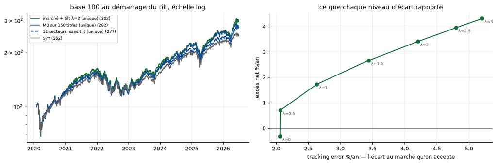

```
figure → /Users/lemairealice/Downloads/Jupiter/02_recherche_backtest/figs_nb16/etf_livrable.png
```

```python
import os
FIGS15 = f"{RACINE}/02_recherche_backtest/figs_nb16"
os.makedirs(FIGS15, exist_ok=True)

V_tilt = run_livre(livre_tilt_unique(2.0), np.inf, cuts=cuts_m)[0]
V_m3   = UNI["titres"];  V_m3 = V_m3[V_m3.index >= V_tilt.index[0]]
V_v2   = UNI["11 secteurs"]; V_v2 = V_v2[V_v2.index >= V_tilt.index[0]]
sp     = (1 + r_spy.reindex(V_tilt.index).fillna(0)).cumprod()

fig, ax = plt.subplots(1, 2, figsize=(12, 4.0))
for V, c, ls, lab in [(V_tilt, VERT, "-",  "marché + tilt λ=2 (unique)"),
                      (V_m3,   BLEU, "-",  "M3 sur 150 titres (unique)"),
                      (V_v2,   BLEU, "--", "11 secteurs, sans tilt (unique)")]:
    s = V / V.iloc[0] * 100
    ax[0].plot(s.index, s, color=c, ls=ls, lw=1.5, label=f"{lab} ({s.iloc[-1]:.0f})")
s = sp / sp.iloc[0] * 100
ax[0].plot(s.index, s, color=GRIS, lw=1.3, label=f"SPY ({s.iloc[-1]:.0f})")
ax[0].set_yscale("log"); ax[0].legend(fontsize=7.5)
ax[0].set_title("base 100 au démarrage du tilt, échelle log")

T = pd.DataFrame(TU).set_index("λ")
ax[1].plot(T["tracking error %/an"], T["excès NET %/an"], "o-", color=VERT, lw=1.6)
for lam in T.index:
    ax[1].annotate(f"λ={lam:g}", (T.loc[lam, "tracking error %/an"], T.loc[lam, "excès NET %/an"]),
                   fontsize=7, xytext=(4, -8), textcoords="offset points", color=GRIS)
ax[1].axhline(0, color=GRIS, lw=0.8)
ax[1].set_xlabel("tracking error %/an — l'écart au marché qu'on accepte")
ax[1].set_ylabel("excès net %/an")
ax[1].set_title("ce que chaque niveau d'écart rapporte")
plt.tight_layout(); plt.savefig(f"{FIGS15}/etf_livrable.png", dpi=150, bbox_inches="tight"); plt.show()
print(f"figure → {FIGS15}/etf_livrable.png")
```

### §18 — La carte historique : rendre à chaque titre le secteur qu'il avait

**Les deux bascules — dates d'INDICE, pas de cotation** (sources primaires SEC) :

|  | l'ETF cote | le secteur GICS naît | **l'ETF source perd les titres** |
| --- | --- | --- | --- |
| XLRE | 08/10/2015 | 31/08/2016 | **16/09/2016** (formulaire 497 du 02/09/2016) |
| XLC | 19/06/2018 | 28/09/2018 | **21/09/2018** (SAI du 485BPOS du 15/06/2018) |

**Les deux règles, écrites avant tout backtest :**

1. **immobilier** — avant le 16/09/2016 Real Estate n'existe pas, l'immobilier est dans Financials : `XLRE` $\to$ **`XLF`**. Totale, sans exception ni jugement (les *mortgage* REITs y restaient de toute façon) ;
2. **communication** — avant le 21/09/2018 le secteur n'existe pas, ses titres venaient de trois endroits ; discriminant : l'**industrie** (déjà en cache, §12) —
   - *Telecom Services*, *Internet Content & Information*, *Electronic Gaming & Multimedia* $\to$ **`XLK`** (aucun SPDR télécom n'a jamais existé, l'indice Technology Select les englobait),
   - *Entertainment*, *Advertising Agencies*, *Broadcasting*, *Publishing* $\to$ **`XLY`**.

   Sans industrie = **sociétés disparues** (`yfinance` rend `None` pour ATVI, TWX, YHOO, LNKD, DTV, LVLT, TWTR, VIAC — vérifié) : **attribution nominative**, écrite ci-dessous, vérifiable une par une. Le reste **garde le comportement actuel** — on ne devine jamais.

⚠️ **Huit tickers exclus des DEUX règles** : ce sont des **fonds**, et cinq portent `asset_type = "Mutual Fund"` alors que `asset_class = "stock"` — la table se contredit. Deux entrent dans le top-150 : **PNQI** sur 10 coupes (démocrates, 10/2014 $\to$ 07/2015) et **SCHH** sur 4 (républicains, dès 02/2014). Les réattribuer aurait fait acheter un secteur au prétexte d'un fonds mal étiqueté. **Retirer ces lignes du flux serait la vraie correction, mais elle déplacerait toutes les ancres du projet** — chantier S1/S2, consigné, pas traité ici.

⚠️ **Prédiction déclarée AVANT de lancer** : le poids qui partait au prorata (énergie et services publics compris) ira vers XLK et XLY ; la technologie ayant monté, **l'excès 2014-2026 va probablement augmenter**. Ce n'est pas un succès mais une correction de fidélité — annoncée ici pour s'interdire de présenter après coup un chiffre plus flatteur comme une découverte.

**Statut, déclaré avant les chiffres** : la version historique est **primaire** parce que plus fidèle ; l'actuelle reste publiée en regard. La fenêtre 2019-2026 n'est **pas** concernée — aucune coupe sans secteur, donc le livrable ($\lambda = 2$) est intact quoi qu'il arrive.

```python
# ══ §18.1 — les deux bascules, et la carte qui dépend de la date ══════════════════════════
BASC_RE = pd.Timestamp("2016-09-16")   # XLF cesse de porter l'immobilier
BASC_CS = pd.Timestamp("2018-09-21")   # XLK et XLY cessent de porter la communication

IND_VERS_BRANCHE = {                                   # l'industrie dit d'où le titre VENAIT
    "Telecom Services": "XLK", "Internet Content & Information": "XLK",
    "Electronic Gaming & Multimedia": "XLK",
    "Entertainment": "XLY", "Advertising Agencies": "XLY",
    "Broadcasting": "XLY", "Publishing": "XLY",
}

# les sociétés disparues : yfinance ne rend rien pour elles. Attribution nominative, opposable.
MANUEL_CS = {
    # ex-Telecommunication Services → XLK
    "LVLT":"XLK","CHL":"XLK","FTR":"XLK","CNSL":"XLK","BT":"XLK","NTT":"XLK","ZAYO":"XLK",
    "ORAN":"XLK","WIN":"XLK","TLSYY":"XLK","JCS":"XLK","DCM":"XLK","IQNT":"XLK","VODPD":"XLK",
    # ex-Information Technology (internet, jeux vidéo) → XLK
    "YNDX":"XLK","TWTR":"XLK","LNKD":"XLK","ATVI":"XLK","YHOO":"XLK","IACI":"XLK","JCOM":"XLK",
    "ZNGA":"XLK","RNWK":"XLK","ISDR":"XLK",
    # ex-Consumer Discretionary (médias, publicité) → XLY
    "VIAC":"XLY","SNI":"XLY","DISH":"XLY","TWX":"XLY","CMCSK":"XLY","MSG":"XLY","TGNA":"XLY",
    "GCI":"XLY","VIAB":"XLY","LTRPA":"XLY","LMCK":"XLY","LMCA":"XLY","MDCA":"XLY","WPPGY":"XLY",
    "IPG":"XLY","LSXMA":"XLY","LSXMK":"XLY","TIME":"XLY","DTV":"XLY","LGF-A":"XLY","SJR":"XLY",
}
# EXCLUS DES DEUX RÈGLES — ce sont des fonds, pas des actions. Ils gardent le comportement actuel.
#   EDR                            : description « EDUCATION RLTY TR », un REIT ; son etf_proxy XLC est faux
#   FDN, IXP, PNQI, VOX            : ETF classés XLC
#   VNQ, IYR, SCHH                 : ETF classés XLRE — sans cette exclusion, la règle immobilier les
#                                    enverrait vers XLF, et SCHH est dans le top-150 sur 4 coupes
# ⚠️ cinq d'entre eux portent asset_type == "Mutual Fund" ET asset_class == "stock" : la table se contredit.
HORS_CARTE = ["EDR", "FDN", "IXP", "PNQI", "VOX", "VNQ", "IYR", "SCHH"]

_CS = [t for t in CARTE.index[CARTE == "XLC"] if t not in HORS_CARTE]
_BR = pd.Series({t: (IND_VERS_BRANCHE.get(IND.get(t)) or MANUEL_CS.get(t)) for t in _CS}).dropna()
_RE = [t for t in CARTE.index[CARTE == "XLRE"] if t not in HORS_CARTE]

def carte_hist(i1):
    """La carte applicable à la coupe i1 : celle d'aujourd'hui, dé-corrigée des bascules postérieures."""
    d = cal[i1]
    if d >= BASC_CS: return CARTE                       # rien à corriger
    c = CARTE.copy()
    if d < BASC_RE: c.loc[_RE] = "XLF"                  # l'immobilier était dans Financials
    c.loc[_BR.index] = _BR.values                       # la communication, branche par branche
    return c

n_xlc = int((CARTE == "XLC").sum()); n_re = int((CARTE == "XLRE").sum())
print(f"communication : {len(_BR)}/{n_xlc} titres attribués "
      f"({(_BR == 'XLK').sum()} → XLK, {(_BR == 'XLY').sum()} → XLY) · "
      f"{n_xlc - len(_BR)} laissés au comportement actuel")
print(f"immobilier    : {len(_RE)}/{n_re} titres → XLF avant le {BASC_RE.date()}")
print(f"exclus des deux règles : {len(HORS_CARTE)} fonds — {', '.join(HORS_CARTE)}")

# (0) aucun des fonds exclus n'est réattribué, à AUCUNE coupe — le code doit dire ce que le texte annonce
for i1 in coupes[::11][:-1]:
    ch = carte_hist(i1)
    for t in HORS_CARTE:
        if t in ch.index:
            assert ch[t] == CARTE[t], f"{t} réattribué à la coupe {cal[i1].date()} : {CARTE[t]} → {ch[t]}"
print(f"✅ (0) les {len(HORS_CARTE)} fonds exclus gardent leur instrument d'origine à toute coupe")

# ── VALIDATION ───────────────────────────────────────────────────────────────────────────
# (1) la correction ne touche QUE le passé
for i1 in [i for i in coupes[:-1] if cal[i] >= BASC_CS]:
    assert carte_hist(i1).equals(CARTE), f"coupe {cal[i1].date()} : la carte d'aujourd'hui a été modifiée"
print(f"✅ (1) sur les {sum(1 for i in coupes[:-1] if cal[i] >= BASC_CS)} coupes ≥ {BASC_CS.date()}, "
      f"carte_hist ≡ CARTE — seul le passé change")

# (2) combien de titres du top-150 restent sans instrument, avant et après ?
def sans_instrument(i1, parti, carte):
    w = poids_methode(i1, parti)
    if not w: return 0, 0.0
    s = pd.Series(w); cle = carte.reindex(s.index)
    mort = [t for t, e in cle.items()
            if not (isinstance(e, str) and e in PXV and np.isfinite(PXV[e][i1+1]) and vivant(e, i1))]
    return len(mort), float(s[mort].sum())

AV = []
for parti, nom in PARTIS:
    for i1 in [i for i in coupes[:-1] if cal[i] < BASC_CS]:
        a_n, a_w = sans_instrument(i1, parti, CARTE)
        h_n, h_w = sans_instrument(i1, parti, carte_hist(i1))
        AV.append({"fonds": nom, "avant · titres": a_n, "avant · poids %": 100*a_w,
                   "après · titres": h_n, "après · poids %": 100*h_w})
AV = pd.DataFrame(AV).groupby("fonds").agg(["median", "max"]).round(1)
display(AV)
print("✅ (2) les titres sans instrument avant/après la carte historique (médiane et max sur les 52 coupes)")
```

```
communication : 113/136 titres attribués (71 → XLK, 42 → XLY) · 23 laissés au comportement actuel
immobilier    : 167/170 titres → XLF avant le 2016-09-16
exclus des deux règles : 8 fonds — EDR, FDN, IXP, PNQI, VOX, VNQ, IYR, SCHH
✅ (0) les 8 fonds exclus gardent leur instrument d'origine à toute coupe
✅ (1) sur les 93 coupes ≥ 2018-09-21, carte_hist ≡ CARTE — seul le passé change
```

| fonds | avant · titres median | avant · titres max | avant · poids % median | avant · poids % max | après · titres median | après · titres max | après · poids % median | après · poids % max |
| --- | --- | --- | --- | --- | --- | --- | --- | --- |
| GOP | 9.0 | 18 | 11.8 | 16.1 | 0.0 | 1 | 0.0 | 0.2 |
| NANC | 11.0 | 13 | 15.2 | 20.8 | 0.0 | 1 | 0.0 | 0.2 |

[output not shown]

```python
# ══ §18.2 — rejouer avec la carte historique, et publier les deux versions ════════════════
HIST = {}
for parti, nom in PARTIS:
    HIST[nom] = run_livre({i: poids_agrege(i, parti, carte=carte_hist(i)) for i in coupes[:-1]}, np.inf)[0]
HIST["UNIQUE"] = run_livre({i: agrege_tous(i, carte=carte_hist(i)) for i in coupes[:-1]}, np.inf)[0]

ACTU = {"NANC": REF[("V2 · 11 secteurs", "NANC")], "GOP": REF[("V2 · 11 secteurs", "GOP")],
        "UNIQUE": UNI["11 secteurs"]}

L = []
for nom in ["NANC", "GOP", "UNIQUE"]:
    for lab, V in [("historique (primaire)", HIST[nom]), ("carte d'aujourd'hui (regard)", ACTU[nom])]:
        b = bilan_ic(V, f"{nom} · {lab}"); b19 = bilan_ic(V[V.index >= D19], f"{nom} · {lab} (2019+)")
        L.append({"signal": nom, "carte": lab, "excès 2014+ %/an": b["excès %/an"], "t": b["t"],
                  "α₁ 2014+ %/an": b["α %/an"], "excès 2019+ %/an": b19["excès %/an"], "t 2019+": b19["t"],
                  "α₁ 2019+ %/an": b19["α %/an"], "β": b["β"], "NAV": b["NAV"]})
THIST = pd.DataFrame(L).set_index(["signal", "carte"])
display(THIST.round(2))

# ── VALIDATION ───────────────────────────────────────────────────────────────────────────
# (3) non-régression : la carte ne touche pas la version titres
assert abs(REF[("M3 · titres","NANC")].iloc[-1] - 661.57) < 0.01
assert abs(REF[("M3 · titres","GOP")].iloc[-1]  - 573.57) < 0.01
print("✅ (3) non-régression — M3-titres inchangée (661,57 / 573,57)")

# (4) Σw = 1 et univers dans les 11 SPDR, à chaque coupe
nc = 0
for parti, nom in PARTIS:
    for i1 in coupes[:-1]:
        w = poids_agrege(i1, parti, carte=carte_hist(i1))
        if not w: continue
        assert abs(sum(w.values()) - 1) < 1e-12, f"{nom} coupe {cal[i1].date()} : Σw ≠ 1"
        assert set(w) <= set(ETF_SECT), f"{nom} coupe {cal[i1].date()} : instrument hors des 11 SPDR"
        nc += 1
print(f"✅ (4) Σw = 1 et univers ⊆ 11 SPDR sur les {nc} coupes des deux partis")

# (5) après les bascules, les deux versions sont le MÊME portefeuille
ec = 0.0
for parti, nom in PARTIS:
    for i1 in [i for i in coupes[:-1] if cal[i] >= BASC_CS]:
        a, h = poids_agrege(i1, parti), poids_agrege(i1, parti, carte=carte_hist(i1))
        assert set(a) == set(h)
        ec = max(ec, max(abs(a[k]-h[k]) for k in a)) if a else ec
assert ec < 1e-15, f"écart {ec:.1e} après les bascules"
print(f"✅ (5) après {BASC_CS.date()} les deux cartes donnent le même portefeuille (écart max {ec:.1e})")
```

| signal | carte | excès 2014+ %/an | t | α₁ 2014+ %/an | excès 2019+ %/an | t 2019+ | α₁ 2019+ %/an | β | NAV |
| --- | --- | --- | --- | --- | --- | --- | --- | --- | --- |
| NANC | historique (primaire) | 1.78 | 1.66 | 0.59 | 1.92 | 1.09 | 0.20 | 1.05 | 586.03 |
|  | carte d'aujourd'hui (regard) | 1.50 | 1.38 | 0.30 | 1.92 | 1.09 | 0.20 | 1.05 | 565.34 |
| GOP | historique (primaire) | 0.78 | 1.02 | 0.41 | 1.12 | 0.92 | 0.65 | 1.02 | 551.95 |
|  | carte d'aujourd'hui (regard) | 0.45 | 0.57 | 0.09 | 1.12 | 0.92 | 0.65 | 1.01 | 530.37 |
| UNIQUE | historique (primaire) | 1.45 | 2.05 | 0.46 | 1.70 | 1.49 | 0.32 | 1.04 | 576.90 |
|  | carte d'aujourd'hui (regard) | 1.15 | 1.54 | 0.16 | 1.70 | 1.49 | 0.32 | 1.04 | 555.42 |

```
✅ (3) non-régression — M3-titres inchangée (661,57 / 573,57)
```

```
✅ (4) Σw = 1 et univers ⊆ 11 SPDR sur les 296 coupes des deux partis
```

```
✅ (5) après 2018-09-21 les deux cartes donnent le même portefeuille (écart max 0.0e+00)
```

### Les questions à poser à Ramify avant d'aller plus loin

Aucune contrainte n'a été supposée. Quatre réponses changeraient la version à retenir :

1. **combien de lignes** ? — 11, 30 ou davantage : cela départage directement les versions ;
2. **quel univers** — les ETF américains cités, ou des équivalents **UCITS** ? Plusieurs ETF fins n'ont pas d'équivalent européen ;
3. **quel écart à l'indice** ? — le §14 pilote le tracking error continûment de 2 à 6 %/an ;
4. **quelle rotation**, à quel coût réel ? — les 10 points de base retenus sont une convention, pas leur barème.

## §19 — Le score sectoriel n'est-il qu'un reflet de la taille des secteurs ?

**Annexe C** de la fiche. Les onze SPDR partitionnant le S&P 500, régresser le SPY sur eux sous $\sum\beta = 1$, $\beta \ge 0$ rend les poids sectoriels du marché **depuis les seules séries de prix** — de quoi comparer ce que le score pèse à ce que le marché pèse.

```python
LAB_C = "C · M3 agrégée en ETF (brute)"
WPE = {(LAB_C, nom): {i: poids_agrege(i, parti) for i in coupes[:-1]}
       for parti, nom in PARTIS}
_n11 = {nom: int(np.median([len(WPE[(LAB_C, nom)][i]) for i in coupes[:-1]
                            if WPE[(LAB_C, nom)][i]])) for _, nom in PARTIS}
assert all(v <= 11 for v in _n11.values()), _n11
print(f"poids sectoriels de M3 prêts pour l'annexe — lignes médianes {_n11}")
```

```
poids sectoriels de M3 prêts pour l'annexe — lignes médianes {'NANC': 11, 'GOP': 11}
```

```python
from scipy.optimize import lsq_linear

RS = pd.DataFrame({t: pd.Series(PXV[t], index=cal).pct_change() for t in ETF_SECT})
RM = r_spy                                        # déjà indexé sur cal (§1.2)

def poids_marche(idx):
    # moindres carrés sous β ≥ 0 et Σβ = 1 : la contrainte d'égalité est imposée par une ligne pondérée
    d = pd.concat([RS.reindex(idx), RM.reindex(idx).rename("m")], axis=1).dropna()
    R, y = d[ETF_SECT].values, d["m"].values
    K = 1e3 * np.abs(R).max()
    A = np.vstack([R, K*np.ones((1, R.shape[1]))]); b = np.concatenate([y, [K]])
    sol = lsq_linear(A, b, bounds=(0, np.inf)).x
    return pd.Series(sol, index=ETF_SECT), len(d)

AN = sorted({d.year for d in cal if d.year >= 2019 and d.year <= cal[-1].year - 1})
BM = {}
for a in AN:
    idx = [d for d in cal if d.year == a]
    bm, n = poids_marche(idx)
    assert abs(bm.sum() - 1) < 1e-6, f"{a} : Σβ = {bm.sum():.6f}, la contrainte n'est pas tenue"
    assert (bm >= -1e-9).all(), f"{a} : un poids négatif"
    BM[a] = bm
BMD = pd.DataFrame(BM).T
print("poids sectoriels IMPLICITES du marché, reconstruits depuis les prix (%) :")
display((100*BMD).round(1))

# contrôle : le portefeuille reconstruit doit suivre le SPY de très près, sinon la décomposition est fausse
R2 = {}
for a in AN:
    idx = [d for d in cal if d.year == a]
    d = pd.concat([RS.reindex(idx), RM.reindex(idx).rename("m")], axis=1).dropna()
    rec = (d[ETF_SECT].values @ BM[a].values)
    R2[a] = 1 - ((d["m"].values - rec)**2).sum() / ((d["m"].values - d["m"].mean())**2).sum()
    print(f"   {a} : R² = {R2[a]:.4f} · Σβ = {BM[a].sum():.6f}")
assert min(R2.values()) > 0.97, f"R² minimal {min(R2.values()):.4f} — la décomposition sectorielle est fausse"
print(f"✅ les onze secteurs ENGENDRENT le SPY (R² de {min(R2.values()):.4f} à {max(R2.values()):.4f}).")
print("   ⚠️ cela n'identifie PAS chaque coefficient — la cellule suivante le démontre.")
print("   La reconstitution n'est pas parfaite, et la raison est réelle : les Select Sector SPDR appliquent")
print("   une contrainte de diversification (plafond par ligne) que le S&P 500 n'a pas ; la régression doit")
print("   donc SURCHARGER XLK pour retrouver l'indice, et prend cette masse ailleurs.")
print(f"   L'année la moins bien reconstituée est {min(R2, key=R2.get)} (R² {min(R2.values()):.4f}), celle où")
print("   la concentration de l'indice a été la plus forte — c'est cohérent, pas un défaut de méthode.")
```

```
poids sectoriels IMPLICITES du marché, reconstruits depuis les prix (%) :
```

|  | XLB | XLC | XLE | XLF | XLI | XLK | XLP | XLRE | XLU | XLV | XLY |
| --- | --- | --- | --- | --- | --- | --- | --- | --- | --- | --- | --- |
| 2019 | 2.9 | 9.6 | 4.8 | 13.7 | 8.4 | 20.9 | 9.0 | 2.1 | 3.5 | 14.2 | 10.8 |
| 2020 | 2.7 | 13.1 | 3.2 | 6.7 | 8.9 | 24.0 | 9.7 | 2.4 | 1.3 | 14.9 | 13.1 |
| 2021 | 2.2 | 9.9 | 3.2 | 9.9 | 8.3 | 29.4 | 7.1 | 2.6 | 3.0 | 12.5 | 12.0 |
| 2022 | 1.9 | 7.9 | 4.0 | 10.8 | 9.0 | 29.5 | 5.7 | 1.9 | 2.9 | 14.8 | 11.5 |
| 2023 | 2.2 | 9.9 | 4.7 | 11.4 | 6.6 | 29.0 | 6.1 | 1.9 | 2.5 | 15.4 | 10.1 |
| 2024 | 0.0 | 13.2 | 3.8 | 12.1 | 4.6 | 33.2 | 6.6 | 1.1 | 2.7 | 13.0 | 9.8 |
| 2025 | 1.6 | 12.2 | 3.6 | 11.4 | 3.4 | 38.7 | 5.7 | 0.0 | 2.1 | 8.4 | 12.8 |

[output not shown]

```python
# CE QUE β EST VRAIMENT — trois contrôles, dans l'ordre du plus décisif au moins
print("=== l'estimateur est-il bon, et les coefficients sont-ils identifiés ? ===\n")

# (a) SANITÉ — sur un indice FABRIQUÉ comme combinaison convexe CONNUE des 11 SPDR, retrouve-t-on w₀ ?
rng = np.random.default_rng(0)
w0 = pd.Series(rng.dirichlet(np.ones(11)), index=ETF_SECT)
idx = [d for d in cal if d.year == 2023]
synth = (RS.reindex(idx)[ETF_SECT] @ w0.values)
_RM_bak = RM
RM = synth                                            # on régresse l'indice synthétique
w_hat, _ = poids_marche(idx)
RM = _RM_bak
print(f"(a) sanité — indice synthétique de poids connus : écart max |β̂ − w₀| = "
      f"{100*float((w_hat - w0).abs().max()):.4f} pt · zéros exacts : {int((w_hat < 1e-9).sum())}")
print("    → le solveur est irréprochable. Ce qui suit vient donc du SPY, pas du code.\n")

# (b) LES ZÉROS SONT-ILS DES SOLUTIONS DE COIN ? on relâche β ≥ 0, on garde Σβ = 1
def poids_sans_borne(idx):
    d = pd.concat([RS.reindex(idx), RM.reindex(idx).rename("m")], axis=1).dropna()
    R, y = d[ETF_SECT].values, d["m"].values
    K = 1e3*np.abs(R).max()
    A = np.vstack([R, K*np.ones((1, R.shape[1]))]); b = np.concatenate([y, [K]])
    return pd.Series(np.linalg.lstsq(A, b, rcond=None)[0], index=ETF_SECT)

print("(b) les poids nuls ou quasi nuls, une fois la contrainte β ≥ 0 relâchée :")
n_coin = 0
for a in AN:
    z = [t for t in ETF_SECT if BM[a][t] < 5e-3]           # sous 0,5 % : la contrainte est probablement active
    if not z: continue
    libre = poids_sans_borne([d for d in cal if d.year == a])
    n_coin += sum(1 for t in z if libre[t] < 0)
    print(f"    {a} : " + " · ".join(f"{t} {100*BM[a][t]:.1f} % → {100*libre[t]:+.1f} % sans borne" for t in z))
print(f"    → {n_coin} cellule(s) deviennent NÉGATIVES sans la borne : ce sont des solutions de coin.")
print("      Un poids d'indice ne peut pas être négatif : ces cellules disent « secteur NON IDENTIFIÉ »,")
print("      pas « secteur absent de l'indice ». Il faut les lire comme telles.\n")

# (c) LE R² DISCRIMINE-T-IL ? coût en R² d'imposer à un secteur une valeur éloignée de son optimum
print("(c) coût en R² d'imposer à XLI un poids de 8,0 % (son ordre de grandeur réel) :")
for a in AN[-2:]:
    idx = [d for d in cal if d.year == a]
    d = pd.concat([RS.reindex(idx), RM.reindex(idx).rename("m")], axis=1).dropna()
    R, y = d[ETF_SECT].values, d["m"].values
    autres = [t for t in ETF_SECT if t != "XLI"]
    y2 = y - 0.08*d["XLI"].values
    R2b = d[autres].values
    K = 1e3*np.abs(R2b).max()
    A = np.vstack([R2b, K*np.ones((1, R2b.shape[1]))]); b = np.concatenate([y2, [K*0.92]])
    sol = lsq_linear(A, b, bounds=(0, np.inf)).x
    rec = R2b @ sol + 0.08*d["XLI"].values
    r2c = 1 - ((y-rec)**2).sum()/((y-y.mean())**2).sum()
    print(f"    {a} : XLI estimé {100*BM[a]['XLI']:.1f} % (R² {R2[a]:.4f}) · "
          f"XLI imposé à 8,0 % (R² {r2c:.4f}) — coût {1e4*(R2[a]-r2c):.1f} points de base")
print("    → un R² de cet ordre est compatible avec des vecteurs très différents : il atteste que les")
print("      onze SPDR engendrent le SPY, jamais que chaque β est le poids du secteur.")
```

```
=== l'estimateur est-il bon, et les coefficients sont-ils identifiés ? ===

(a) sanité — indice synthétique de poids connus : écart max |β̂ − w₀| = 0.0000 pt · zéros exacts : 0
    → le solveur est irréprochable. Ce qui suit vient donc du SPY, pas du code.

(b) les poids nuls ou quasi nuls, une fois la contrainte β ≥ 0 relâchée :
    2024 : XLB 0.0 % → -0.3 % sans borne
    2025 : XLRE 0.0 % → -0.8 % sans borne
    → 2 cellule(s) deviennent NÉGATIVES sans la borne : ce sont des solutions de coin.
      Un poids d'indice ne peut pas être négatif : ces cellules disent « secteur NON IDENTIFIÉ »,
      pas « secteur absent de l'indice ». Il faut les lire comme telles.

(c) coût en R² d'imposer à XLI un poids de 8,0 % (son ordre de grandeur réel) :
    2024 : XLI estimé 4.6 % (R² 0.9835) · XLI imposé à 8,0 % (R² 0.9832) — coût 3.4 points de base
    2025 : XLI estimé 3.4 % (R² 0.9901) · XLI imposé à 8,0 % (R² 0.9899) — coût 2.6 points de base
    → un R² de cet ordre est compatible avec des vecteurs très différents : il atteste que les
      onze SPDR engendrent le SPY, jamais que chaque β est le poids du secteur.
```

```python
# le score sectoriel, moyenné par année, en regard des poids du marché
CMP = []
for parti, nom in PARTIS:
    for a in AN:
        cs = [i for i in coupes[:-1] if cal[i].year == a]
        if not cs: continue
        sc = pd.DataFrame({i: pd.Series(WPE[(LAB_C, nom)][i]) for i in cs}).mean(axis=1).reindex(ETF_SECT).fillna(0)
        bm = BM[a]
        CMP.append({"fonds": nom, "année": a,
                    "ρ rang (C vs marché)": stats.spearmanr(sc.values, bm.values).statistic,
                    "écart abs. moy. C %": 100*float((sc - bm).abs().mean()),
                    "XLK marché %": 100*bm["XLK"], "XLK score C %": 100*sc["XLK"]})
T = pd.DataFrame(CMP).set_index(["fonds", "année"])
display(T.round(2))
print("\nsynthèse (médiane sur les années) :")
display(T.groupby(level=0).median().round(2))
print("\nlecture : ρ de rang proche de 1 ⇒ le score classe les secteurs comme le marché les pèse,")
print("          donc il n'apporte pas d'information au-delà de la taille. ρ bas ⇒ il dit autre chose.")
print("          L'écart absolu moyen dit de combien de points on s'écarte du marché, secteur par secteur.")
```

| fonds | année | ρ rang (C vs marché) | écart abs. moy. C % | XLK marché % | XLK score C % |
| --- | --- | --- | --- | --- | --- |
| NANC | 2019 | 0.85 | 3.00 | 20.90 | 28.17 |
|  | 2020 | 0.85 | 3.05 | 23.99 | 28.05 |
|  | 2021 | 0.87 | 2.84 | 29.36 | 29.78 |
|  | 2022 | 0.80 | 3.65 | 29.54 | 31.71 |
|  | 2023 | 0.83 | 3.32 | 29.01 | 34.10 |
|  | 2024 | 0.90 | 2.03 | 33.16 | 34.19 |
|  | 2025 | 0.85 | 1.88 | 38.65 | 41.52 |
| GOP | 2019 | 0.91 | 2.31 | 20.90 | 17.74 |
|  | 2020 | 0.72 | 4.10 | 23.99 | 16.81 |
|  | 2021 | 0.77 | 4.16 | 29.36 | 17.24 |
|  | 2022 | 0.92 | 2.74 | 29.54 | 19.75 |
|  | 2023 | 0.94 | 1.79 | 29.01 | 24.56 |
|  | 2024 | 0.85 | 2.38 | 33.16 | 28.13 |
|  | 2025 | 0.88 | 1.99 | 38.65 | 40.89 |

```
synthèse (médiane sur les années) :
```

| fonds | ρ rang (C vs marché) | écart abs. moy. C % | XLK marché % | XLK score C % |
| --- | --- | --- | --- | --- |
| GOP | 0.88 | 2.38 | 29.36 | 19.75 |
| NANC | 0.85 | 3.00 | 29.36 | 31.71 |

```
lecture : ρ de rang proche de 1 ⇒ le score classe les secteurs comme le marché les pèse,
          donc il n'apporte pas d'information au-delà de la taille. ρ bas ⇒ il dit autre chose.
          L'écart absolu moyen dit de combien de points on s'écarte du marché, secteur par secteur.
```

# §20 — Le portefeuille final : une poche de marché, une poche de stratégie

**Ce que ce paragraphe abandonne.** La forme *« le marché, plus un tilt »* du §14 s'écrit $w = w^{\text{mkt}} + \lambda(w^{\text{sig}} - w^{\text{mkt}}) = (1-\lambda)\,w^{\text{mkt}} + \lambda\,w^{\text{sig}}$. Trois défauts, tous visibles dans les sorties ci-dessus :

[output not shown]

**Le changement d'objet.** Le bon objet n'est pas le vecteur de poids mais **une seule série** — l'écart actif à pleine dose :

$$d_t \;=\; r^{\text{signal}}_t - r^{\text{SPY}}_t \qquad\Longrightarrow\qquad r^{p}_t - r^{b}_t \;=\; a_t\,d_t, \qquad \mathrm{TE}(a) \;=\; a\,\sigma(d)\sqrt{252}$$

Une série univariée : ni vecteur de onze poids, ni matrice $11\times11$ à estimer. La couche de risque ne voit plus la stratégie, seulement $d$ — c'est le point de vue de l'allocataire, et il vaut pour onze ETF comme pour cent cinquante titres. **Ce qui reste en poids, et seulement ça : le coût.** On décide en rendements, on facture en poids — et le §20.2 prouve que les deux chemins coïncident.

⚠️ **Le §14 et le §17.1 ne sont pas corrigés** : ils restent comme trace de recherche. Le §20 ne les touche pas et ne réutilise aucun de leurs objets — en particulier **pas `BM_AN`**, dont la disparition rend la fenêtre **2014-2026** de nouveau disponible (le tilt était borné à 2020-2026 par la reconstruction).

### §20.0 — Le protocole de construction, déclaré avant tout calcul

C'est **le livrable** : ce qu'on fait, dans l'ordre, à chaque fin de mois.

|  | à la coupe $t$ on calcule… | avec quoi |
| --- | --- | --- |
| **1** | **le signal** — étape 12 **inchangée** : $s_i = B_i m_i$, top-150, plafond 10 %, agrégation en onze ETF $\Rightarrow w^{\text{sig}}_t$ | `agrege_tous(t, carte=carte_hist(t))` |
| **2** | **l'écart actif** — $d_u = r^{\text{sig}}_u - r^{\text{SPY}}_u$ sur les **756 jours cotés précédant $t$** | série $D$, **jamais au-delà de $t$** |
| **3** | **le risque du pari à pleine dose** — $\hat\sigma_t = \sqrt{252}\cdot\mathrm{sd}\{d_u\}$ | idem |
| **4** | **la dose** — $a_t = \min\!\big(1,\ \mathrm{TE}^\star/\hat\sigma_t\big)$ | $\mathrm{TE}^\star$ : le **seul** paramètre du dispositif |
| **5** | **la bande morte** — on ne re-dimensionne que si $\lvert a_t - a_{\text{détenu}}\rvert > h\,a_{\text{détenu}}$, $h = 20\,\%$ | sinon on ne touche à rien : pas de frais sur du bruit d'estimation |
| **6** | **le portefeuille** — $w_t = (1-a_t)\,\mathrm{SPY} + a_t\,w^{\text{sig}}_t$ $\Rightarrow$ **douze lignes**, $\sum w = 1$, tous $\ge 0$ | aucun écrêtage nécessaire : combinaison convexe de deux vecteurs positifs |
| **7** | **l'exécution** — close J+1, buy-and-hold jusqu'à la coupe suivante, 10 pb par aller-retour | `run_livre`, `COUT_BPS` |

**Les trois constantes, et d'où elles viennent — aucune n'est calée sur nos rendements :**

|  | valeur | ce qui la fixe |
| --- | --- | --- |
| $H$, fenêtre d'estimation | **756 j** ($\simeq 3$ ans) | **demandé par le chef de recherche**, avant tout calcul |
| $h$, bande morte | **20 %** | déclarée ici, avant le premier run ; publiée avec et sans |
| $\mathrm{TE}^\star$ | **profil complet** $\{1, 2, 3\}$ % | *inconnu* — c'est la seule question à poser à Ramify. On ne le choisit pas, on publie le profil |

```python
# ══ §20.0 — les deux poches, et la série qui porte tout le reste ═══════════════════════════
# SPY entre dans PXV ICI et pas au §1.3 : purement additif, aucune ancre du notebook n'est touchée.
assert "SPY" not in set(df.tk), "SPY est un ticker du flux — l'ajouter à PXV changerait le périmètre de M3"
PXV["SPY"] = spy.reindex(cal).ffill().to_numpy()
LAST["SPY"] = spy.index[-1]

# LA POCHE ACTIVE = le signal de l'ÉTAPE 12 : portefeuille unique, 11 ETF, CARTE DATÉE (§18).
WS = {i: agrege_tous(i, carte=carte_hist(i)) for i in coupes[:-1]}
V_SIG = run_livre(WS, np.inf)[0]
assert abs(V_SIG.iloc[-1] - HIST["UNIQUE"].iloc[-1]) < 1e-9, "la poche active n'est pas le signal du §18"
print(f"✅ poche active = §18 « UNIQUE, carte historique » — NAV {V_SIG.iloc[-1]:.2f} (identique au §18)")

# ── LA SÉRIE QUI PORTE TOUT : l'écart actif à pleine dose ──────────────────────────────────
r_sig = V_SIG.pct_change().dropna()
r_ben = r_spy.reindex(r_sig.index).fillna(0.0)
D     = (r_sig - r_ben).rename("d")                       # d_t = r_signal − r_SPY
V_BEN = (1 + r_ben).cumprod() * 100                       # le SPY sur exactement la même fenêtre

H_EST, TE_CIBLES, BANDE = 756, [1.0, 2.0, 3.0], 0.20      # DÉCLARÉS AVANT le premier run
print(f"écart actif d : {len(D):,} jours cotés · {D.index[0].date()} → {D.index[-1].date()} "
      f"({(D.index[-1]-D.index[0]).days/365.25:.1f} ans)")
print(f"constantes déclarées — H = {H_EST} j · bande morte h = {BANDE:.0%} · TE* ∈ {TE_CIBLES} %/an")
print(f"\n⚠️ la fenêtre commence en {D.index[0].year} et non en 2020 : le tilt du §14 exigeait BM_AN "
      f"(l'année précédente reconstruite), ce dispositif n'en a plus besoin.")
```

```
✅ poche active = §18 « UNIQUE, carte historique » — NAV 576.90 (identique au §18)
écart actif d : 3,101 jours cotés · 2014-03-04 → 2026-07-01 (12.3 ans)
constantes déclarées — H = 756 j · bande morte h = 20% · TE* ∈ [1.0, 2.0, 3.0] %/an

⚠️ la fenêtre commence en 2014 et non en 2020 : le tilt du §14 exigeait BM_AN (l'année précédente reconstruite), ce dispositif n'en a plus besoin.
```

### §20.1 — Comment la stratégie est corrélée au marché, et où est le bêta

La première question d'un gérant du risque n'est pas *combien ça rapporte* mais *de quoi c'est fait*. On régresse le signal sur l'indice, en excès du taux sans risque :

$$r^{\text{sig}}_t - r^{f}_t = \alpha + \beta_s\,(r^{b}_t - r^{f}_t) + \varepsilon_t \qquad\Longrightarrow\qquad d_t = \alpha + (\beta_s - 1)(r^{b}_t - r^{f}_t) + \varepsilon_t$$

d'où la décomposition du budget de risque, exacte parce que $\mathrm{Cov}(r^b - r^f, \varepsilon) = 0$ par construction des moindres carrés :

$$\boxed{\ \mathrm{Var}(d) \;=\; \underbrace{(\beta_s-1)^2\,\sigma_b^2}_{\text{du bêta}} \;+\; \underbrace{\sigma_\varepsilon^2}_{\text{spécifique}}\ }$$

C'est ce qui sépare deux ratios que la fiche confond aujourd'hui :

$$\mathrm{IR} = \frac{\mathbb E[d]}{\sigma(d)}\sqrt{252} \qquad\text{contre}\qquad \text{appraisal} = \frac{\alpha}{\sigma_\varepsilon\sqrt{252}}$$

Le premier récompense le bêta ; le second ne récompense que ce qu'on ne peut pas acheter seul. **Un allocataire décomposera l'IR de toute façon — autant le faire nous-mêmes.**

```python
# ══ §20.1 — de quoi l'écart actif est fait ════════════════════════════════════════════════
# ⚠️ FF s'arrête AVANT le calendrier de prix : le join perd des jours. La décomposition se lit donc
# sur l'échantillon RÉGRESSÉ, où elle est exacte — sinon on compare deux fenêtres différentes.
dd   = pd.DataFrame({"s": r_sig, "b": r_ben}).join(FF[["RF"]]).dropna()
y, X = (dd.s - dd.RF).values, (dd.b - dd.RF).values
beta_s, alpha_j = np.polyfit(X, y, 1)
eps  = y - (alpha_j + beta_s*X)
d_r  = y - X                       # = (r_s − RF) − (r_b − RF) = r_s − r_b, sur l'échantillon régressé

A, K = np.sqrt(252), 252 * 100**2                  # K : variance journalière → (%/an)²
part_beta = K * (beta_s - 1)**2 * np.var(X, ddof=1)
part_spec = K * np.var(eps,      ddof=1)
var_d     = K * np.var(d_r,      ddof=1)

sig_s = 100*A*r_sig.std();  sig_b = 100*A*r_ben.std();  sig_e = np.sqrt(part_spec)
te_1  = 100*A*D.std()                              # la TE du pari à pleine dose, sur TOUTE la série
rho   = float(r_sig.corr(r_ben))

CAR = pd.DataFrame([{
    "σ signal %/an": sig_s, "σ SPY %/an": sig_b, "ρ(signal, SPY)": rho, "R²": rho**2,
    "β (excès de RF)": beta_s, "α %/an": 252*100*alpha_j, "σ_ε %/an": sig_e,
    "TE à pleine dose %/an": te_1, "IR = E[d]/σ(d)": 252*100*D.mean()/te_1,
    "appraisal = α/σ_ε": 252*100*alpha_j/sig_e,
}]).T.rename(columns={0: "valeur"})
display(CAR.round(4))

# ── VALIDATION : Var(d) = (β−1)²σ_b² + σ_ε², exacte parce que Cov(X, ε) = 0 par moindres carrés ──
assert abs(part_beta + part_spec - var_d) < 1e-9 * var_d, \
    f"décomposition : {part_beta+part_spec:.6f} ≠ {var_d:.6f}"
print("décomposition du budget de risque — Var(d) = (β−1)²·σ_b² + σ_ε²")
print(f"   part du BÊTA      {part_beta:8.3f} (%/an)²   soit {100*part_beta/var_d:5.1f} % de la variance")
print(f"   part SPÉCIFIQUE   {part_spec:8.3f} (%/an)²   soit {100*part_spec/var_d:5.1f} %")
print(f"✅ somme = Var(d) = {var_d:.6f} — identité exacte (écart {abs(part_beta+part_spec-var_d):.1e})")
print(f"   √Var(d) = {np.sqrt(var_d):.3f} %/an sur les {len(dd):,} jours régressés, contre TE = {te_1:.3f} %/an")
print(f"   sur les {len(D):,} jours de la série : {len(D)-len(dd)} jours perdus au bout, FF s'arrêtant "
      f"le {FF.index[-1].date()}")

print(f"\n→ ρ = {rho:.4f}, donc R² = {rho**2:.1%} : c'est la part de la variance du SIGNAL qui est du marché.")
print(f"  On paie 11 lignes et ~30 %/an de rotation pour obtenir ce qu'un SPY donne à 0,09 %/an de frais.")
print(f"  C'est la justification entière du passage à deux poches : rendre visible ce qu'on achète gratuitement.")
print(f"\n→ et {100*part_beta/var_d:.0f} % du budget de RISQUE est du bêta : un allocataire l'obtient en levant")
print(f"  le SPY, sans nous. Le ratio qui l'exclut est l'appraisal ({252*100*alpha_j/sig_e:.3f}), pas l'IR.")
```

|  | valeur |
| --- | --- |
| σ signal %/an | 18.1766 |
| σ SPY %/an | 17.2728 |
| ρ(signal, SPY) | 0.9940 |
| R² | 0.9881 |
| β (excès de RF) | 1.0448 |
| α %/an | 0.4626 |
| σ_ε %/an | 1.9143 |
| TE à pleine dose %/an | 2.1395 |
| IR = E[d]/σ(d) | 0.6374 |
| appraisal = α/σ_ε | 0.2416 |

```
décomposition du budget de risque — Var(d) = (β−1)²·σ_b² + σ_ε²
   part du BÊTA         0.601 (%/an)²   soit  14.1 % de la variance
   part SPÉCIFIQUE      3.665 (%/an)²   soit  85.9 %
✅ somme = Var(d) = 4.265492 — identité exacte (écart 1.2e-14)
   √Var(d) = 2.065 %/an sur les 3,059 jours régressés, contre TE = 2.139 %/an
   sur les 3,101 jours de la série : 42 jours perdus au bout, FF s'arrêtant le 2026-04-30

→ ρ = 0.9940, donc R² = 98.8% : c'est la part de la variance du SIGNAL qui est du marché.
  On paie 11 lignes et ~30 %/an de rotation pour obtenir ce qu'un SPY donne à 0,09 %/an de frais.
  C'est la justification entière du passage à deux poches : rendre visible ce qu'on achète gratuitement.

→ et 14 % du budget de RISQUE est du bêta : un allocataire l'obtient en levant
  le SPY, sans nous. Le ratio qui l'exclut est l'appraisal (0.242), pas l'IR.
```

```python
# ══ §20.1bis — le pilotage est-il seulement possible ? (clustering, et corrélation en stress) ══
# Sans persistance de la volatilité, σ̂_t ne prédit rien et piloter la dose n'a pas d'objet.
AC = pd.DataFrame([{"lag j": L, "autocorr. de d": float(D.autocorr(L)),
                    "autocorr. de |d|": float(D.abs().autocorr(L))} for L in [1, 2, 5, 10, 21, 63]])
display(AC.set_index("lag j").round(3))

# la vol du marché, sur 21 j — sert à découper les régimes (descriptif : mesure contemporaine assumée)
vol_b = r_ben.rolling(21).std()*A*100
q = pd.qcut(vol_b.dropna(), 5, labels=["1 très calme", "2", "3", "4", "5 stress"])
REG = []
for lab in q.cat.categories:
    idx = q.index[q == lab]
    REG.append({"régime de marché": lab, "jours": len(idx),
                "ρ(signal, SPY)": float(r_sig.reindex(idx).corr(r_ben.reindex(idx))),
                "σ SPY %/an": 100*A*r_ben.reindex(idx).std(),
                "σ(d) %/an": 100*A*D.reindex(idx).std(),
                "d moyen %/an": 252*100*D.reindex(idx).mean()})
display(pd.DataFrame(REG).set_index("régime de marché").round(2))
print("la colonne σ(d) dit si le pari GROSSIT quand le marché se tend — c'est ce qu'un pilotage doit corriger ;")
print("la colonne ρ dit si la stratégie décorrèle quand on en aurait besoin, ou si elle se colle au marché.")
```

| lag j | autocorr. de d | autocorr. de \|d\| |
| --- | --- | --- |
| 1 | -0.040 | 0.259 |
| 2 | 0.012 | 0.179 |
| 5 | -0.009 | 0.200 |
| 10 | -0.011 | 0.194 |
| 21 | 0.007 | 0.171 |
| 63 | 0.047 | 0.079 |

| régime de marché | jours | ρ(signal, SPY) | σ SPY %/an | σ(d) %/an | d moyen %/an |
| --- | --- | --- | --- | --- | --- |
| 1 très calme | 617 | 0.99 | 6.77 | 1.27 | 1.39 |
| 2 | 616 | 0.98 | 10.01 | 2.04 | 0.94 |
| 3 | 616 | 0.99 | 13.14 | 1.99 | 0.88 |
| 4 | 616 | 0.99 | 16.38 | 2.26 | 2.38 |
| 5 stress | 616 | 1.00 | 30.23 | 2.85 | 1.39 |

```
la colonne σ(d) dit si le pari GROSSIT quand le marché se tend — c'est ce qu'un pilotage doit corriger ;
la colonne ρ dit si la stratégie décorrèle quand on en aurait besoin, ou si elle se colle au marché.
```

### §20.2 — VALIDATION : décider en rendements, facturer en poids

Deux chemins doivent mener à la même NAV :

- **(i) en rendements** — deux poches valorisées séparément, remélangées **à chaque coupe** ;
- **(ii) en poids** — un vecteur de douze lignes $w = (1-a)\,\mathrm{SPY} + a\,w^{\text{sig}}$ passé au moteur.

```python
# ══ §20.2 — les deux chemins, et leur identité ════════════════════════════════════════════
def livre_deux_poches(a_of_i, WSIG=None, cuts=None):
    """(ii) EN POIDS — un vecteur de 12 lignes par coupe : (1−a)·SPY + a·w_signal."""
    WSIG = WS if WSIG is None else WSIG
    cuts = coupes if cuts is None else cuts
    WP = {}
    for i in cuts[:-1]:
        w, a = WSIG.get(i, {}), a_of_i(i)
        if not w or a is None: continue
        d_ = {tk: a*wi for tk, wi in w.items()}
        d_["SPY"] = d_.get("SPY", 0.0) + (1.0 - a)
        d_ = {k: v for k, v in d_.items() if v > 1e-15}
        assert abs(sum(d_.values()) - 1) < 1e-12, f"coupe {i} : Σw ≠ 1"
        WP[i] = d_
    return WP

def nav_deux_poches(a_of_i, WSIG=None, cuts=None):
    """(i) EN RENDEMENTS — poche SPY et poche signal valorisées à part, remélangées aux coupes."""
    WSIG = WS if WSIG is None else WSIG
    cuts = coupes if cuts is None else cuts
    V = np.full(len(cal), np.nan); V[cuts[0]+1] = 100.0
    for j in range(len(cuts)-1):
        e, e2 = cuts[j]+1, cuts[j+1]+1
        w, a = WSIG.get(cuts[j], {}), a_of_i(cuts[j])
        if not w or a is None or not np.isfinite(V[e]):
            for t in range(e+1, min(e2, len(cal)-1)+1): V[t] = V[e]
            continue
        cap = V[e]
        qs  = {tk: cap*a*wi/PXV[tk][e] for tk, wi in w.items()}      # poche STRATÉGIE, en parts
        qb  = cap*(1.0-a)/PXV["SPY"][e]                              # poche MARCHÉ, en parts
        for t in range(e+1, min(e2, len(cal)-1)+1):
            V[t] = sum(q*PXV[tk][t] for tk, q in qs.items()) + qb*PXV["SPY"][t]
    s = pd.Series(V, index=cal)
    return s.loc[s.first_valid_index():s.last_valid_index()]

ec_max = 0.0
for a in [0.0, 0.25, 0.5, 0.75, 1.0]:
    f = (lambda i, a=a: a)
    Vi = nav_deux_poches(f)
    Vii = run_livre(livre_deux_poches(f), np.inf)[0]
    com = Vi.index.intersection(Vii.index)
    ec_max = max(ec_max, float((Vi[com]/Vii[com] - 1).abs().max()))
assert ec_max < 1e-12, f"les deux chemins divergent (écart relatif max {ec_max:.2e})"
print(f"✅ rendements ≡ poids sur les cinq doses — écart relatif max {ec_max:.2e}")

# le piège que ce contrôle écarte : combiner à a constant SANS laisser les poches dériver
V_naif = (1 + (0.5*r_sig + 0.5*r_ben)).cumprod()*100
V_vrai = nav_deux_poches(lambda i: 0.5)
print(f"\n  à a = ½ — remélange quotidien implicite : NAV {V_naif.iloc[-1]:7.2f}")
print(f"            deux poches qui dérivent      : NAV {V_vrai.iloc[-1]:7.2f}"
      f"   ⇒ écart {100*(V_naif.iloc[-1]/V_vrai.iloc[-1]-1):+.2f} % de rendement fabriqué")
```

```
✅ rendements ≡ poids sur les cinq doses — écart relatif max 3.11e-15

  à a = ½ — remélange quotidien implicite : NAV  536.17
            deux poches qui dérivent      : NAV  536.21   ⇒ écart -0.01 % de rendement fabriqué
```

### §20.3 — Le profil statique : trois identités à vérifier

Puisque $r_p - r_b = a\,d$, trois choses sont vraies **par algèbre** et doivent se retrouver dans les chiffres :

$$\text{excès}(a) = a\cdot\text{excès}(1), \qquad \mathrm{TE}(a) = a\cdot\mathrm{TE}(1), \qquad \mathrm{IR}(a) = \mathrm{IR}(1)\ \ \text{— constant}$$

⚠️ Elles sont exactes sur l'écart **arithmétique journalier**. Sur l'excès **annuel géométrique** — celui que `bilan` publie, et celui qu'un client lit sur son relevé — la composition introduit un terme de convexité. Publier les deux dit exactement où ce terme mord, plutôt que de l'absorber en silence.

**C'est aussi la réfutation du §17.1** : là-bas l'IR montait de 0,68 à 0,85. Ici il ne peut pas monter.

```python
# ══ §20.3 — le profil statique a ∈ [0, 1] ═════════════════════════════════════════════════
def mesures(V, lab, cuts=None, WP=None):
    """Le jeu de mesures commun à tout le §20 : excès géométrique ET arithmétique, TE, IR, coût."""
    b  = bilan_ic(V, lab)
    rp = V.pct_change().dropna(); rb = r_spy.reindex(rp.index).fillna(0.0)
    e  = rp - rb
    o  = {"excès géom. %/an": b["excès %/an"], "t": b["t"], "IC bas": b["IC bas"], "IC haut": b["IC haut"],
          "excès arithm. %/an": 252*100*e.mean(), "TE %/an": 100*np.sqrt(252)*e.std(),
          "α₁ %/an": b["α %/an"], "β": b["β"], "vol %/an": 100*np.sqrt(252)*rp.std(),
          "perte max %": perte_max(V), "NAV": b["NAV"], "n ans": b["n ans"]}
    o["IR"] = o["excès arithm. %/an"]/o["TE %/an"] if o["TE %/an"] > 1e-9 else np.nan
    if WP is not None:
        net = run_livre(WP, np.inf, cuts=cuts, cout_bps=COUT_BPS)[0]
        o["excès NET %/an"] = bilan(net, lab + " (net)")["excès %/an"]
        _, an = rotation(WP, cuts=cuts); o["rotation %/an"] = an.mean()
        o["lignes"] = len(WP[max(WP)])
    return o

PROFIL, PRO = [0.0, 0.25, 0.5, 0.75, 1.0], []
for a in PROFIL:
    f  = (lambda i, a=a: a)
    WP = livre_deux_poches(f)
    V  = run_livre(WP, np.inf)[0]
    PRO.append({"a": a, **mesures(V, f"deux poches a={a:.2f}", WP=WP)})
P = pd.DataFrame(PRO).set_index("a")
display(P[["lignes", "excès géom. %/an", "excès NET %/an", "t", "IC bas", "IC haut", "excès arithm. %/an",
           "TE %/an", "IR", "α₁ %/an", "β", "vol %/an", "perte max %", "rotation %/an", "NAV"]].round(2))

# ── VALIDATION : les trois identités, et leur RÉSIDU ───────────────────────────────────────
# Elles sont exactes pour un mélange remélangé EN CONTINU. Nos deux poches dérivent entre les coupes
# (c'est le §20.2), donc un résidu existe forcément. On le mesure au lieu de le supposer nul.
ref_x, ref_te = P.loc[1.0, "excès arithm. %/an"], P.loc[1.0, "TE %/an"]
ID = pd.DataFrame([{"a": a,
                    "TE observée": P.loc[a, "TE %/an"], "a × TE(1)": a*ref_te,
                    "résidu TE (ppm)": 1e6*abs(P.loc[a, "TE %/an"]/(a*ref_te) - 1),
                    "excès arithm. observé": P.loc[a, "excès arithm. %/an"], "a × excès(1)": a*ref_x,
                    "résidu excès (ppm)": 1e6*abs(P.loc[a, "excès arithm. %/an"]/(a*ref_x) - 1),
                    "IR": P.loc[a, "IR"],
                    "écart géom. − arithm.": P.loc[a, "excès géom. %/an"] - P.loc[a, "excès arithm. %/an"]}
                   for a in PROFIL if a > 0]).set_index("a")
display(ID.round(3))
res = max(ID["résidu TE (ppm)"].max(), ID["résidu excès (ppm)"].max())
assert res < 5000, f"résidu de linéarité {res:.0f} ppm — trop grand pour une simple dérive intra-période"
ir = P["IR"].dropna()
print(f"✅ TE(a) = a·TE(1) et excès(a) = a·excès(1) à {res:.0f} ppm près — le résidu est la DÉRIVE des")
print(f"   deux poches entre deux coupes, la seule chose qui empêche l'identité d'être exacte.")
print(f"   Conséquence : IR CONSTANT, de {ir.min():.4f} à {ir.max():.4f} — un écart de {1e4*(ir.max()/ir.min()-1):.0f} pour dix mille.")
print("\n   Le §17.1 publiait un IR qui MONTE de 0,68 à 0,85 avec λ : c'était l'artefact du départ décalé")
print("   (λ = 0 n'est pas le SPY) et de l'écrêtage des poids négatifs. Ici la montée est impossible.")
print("\n→ a NE SE CHOISIT PAS sur l'IR : il n'y a rien à y lire. Et le t est lui aussi INVARIANT")
print(f"   ({P['t'].iloc[1:].min():.2f} à {P['t'].iloc[1:].max():.2f} sur les quatre doses non nulles) —")
print("   doser plus achète du rendement, jamais de la preuve.")
```

| a | lignes | excès géom. %/an | excès NET %/an | t | IC bas | IC haut | excès arithm. %/an | TE %/an | IR | α₁ %/an | β | vol %/an | perte max % | rotation %/an | NAV |
| --- | --- | --- | --- | --- | --- | --- | --- | --- | --- | --- | --- | --- | --- | --- | --- |
| 0.00 | 1 | 0.00 | 0.00 | 0.00 | -0.00 | 0.00 | -0.00 | 0.00 | NaN | -0.00 | 1.00 | 17.27 | -33.72 | 0.00 | 497.61 |
| 0.25 | 12 | 0.36 | 0.35 | 2.06 | -0.02 | 0.74 | 0.34 | 0.54 | 0.64 | 0.12 | 1.01 | 17.48 | -33.90 | 7.45 | 516.65 |
| 0.50 | 12 | 0.72 | 0.69 | 2.06 | -0.04 | 1.49 | 0.68 | 1.07 | 0.64 | 0.23 | 1.02 | 17.70 | -34.08 | 14.57 | 536.21 |
| 0.75 | 12 | 1.09 | 1.04 | 2.06 | -0.06 | 2.24 | 1.02 | 1.60 | 0.64 | 0.35 | 1.03 | 17.93 | -34.27 | 21.38 | 556.29 |
| 1.00 | 11 | 1.45 | 1.39 | 2.05 | -0.09 | 2.99 | 1.36 | 2.14 | 0.64 | 0.46 | 1.04 | 18.18 | -34.45 | 27.88 | 576.90 |

| a | TE observée | a × TE(1) | résidu TE (ppm) | excès arithm. observé | a × excès(1) | résidu excès (ppm) | IR | écart géom. − arithm. |
| --- | --- | --- | --- | --- | --- | --- | --- | --- |
| 0.25 | 0.535 | 0.535 | 456.853 | 0.341 | 0.341 | 1179.109 | 0.638 | 0.021 |
| 0.50 | 1.070 | 1.070 | 296.742 | 0.682 | 0.682 | 764.301 | 0.638 | 0.042 |
| 0.75 | 1.605 | 1.605 | 144.484 | 1.023 | 1.023 | 371.342 | 0.638 | 0.065 |
| 1.00 | 2.139 | 2.139 | 0.000 | 1.364 | 1.364 | 0.000 | 0.637 | 0.089 |

```
✅ TE(a) = a·TE(1) et excès(a) = a·excès(1) à 1179 ppm près — le résidu est la DÉRIVE des
   deux poches entre deux coupes, la seule chose qui empêche l'identité d'être exacte.
   Conséquence : IR CONSTANT, de 0.6374 à 0.6379 — un écart de 7 pour dix mille.

   Le §17.1 publiait un IR qui MONTE de 0,68 à 0,85 avec λ : c'était l'artefact du départ décalé
   (λ = 0 n'est pas le SPY) et de l'écrêtage des poids négatifs. Ici la montée est impossible.

→ a NE SE CHOISIT PAS sur l'IR : il n'y a rien à y lire. Et le t est lui aussi INVARIANT
   (2.05 à 2.06 sur les quatre doses non nulles) —
   doser plus achète du rendement, jamais de la preuve.
```

### §20.4 — Le pilotage : la dose se déduit du budget de risque

Un budget de TE **statique** ne budgète presque rien : Alankar, Maymin, Maymin, Scholes & Zhang (2026) mesurent que la volatilité de la TE *réalisée* varie d'un facteur $\simeq 12$ selon la contrainte, à Sharpe statistiquement indiscernable. Annoncer « TE $= 3\,\%$ » ne dit donc rien de ce qu'une année donnée fera. D'où la dose qui suit l'estimation du risque, sur la fenêtre de trois ans demandée :

$$\hat\sigma_t = \sqrt{252}\cdot\mathrm{sd}\{d_u : u \in (t-H,\ t]\}, \quad H = 756 \qquad\Longrightarrow\qquad \boxed{\ a_t = \min\!\big(1,\ \mathrm{TE}^\star/\hat\sigma_t\big)\ }$$

**Analytique** : pas d'optimisation, pas de balayage, rien qui se choisisse après avoir vu un rendement. Le plafond $a_t \le 1$ est la contrainte « pas de levier, pas de vente à découvert ».

⚠️ **Ce qu'on n'a pas le droit d'espérer.** Le *volatility targeting* améliore le Sharpe des **actifs risqués** — actions, crédit — par deux mécanismes : la persistance de la volatilité et l'*effet de levier* (la vol monte quand les prix baissent). Notre $d$ est un **long-short de somme nulle** : le second mécanisme n'a aucune raison d'y être. Le pilotage est justifié parce qu'il **tient le budget de risque**, pas parce qu'il rapporterait plus. Si l'IR s'améliore, c'est un bonus qu'on mesure ; on ne le promet pas.

⚠️ Il consomme $H = 756$ jours de démarrage. Il se compare donc au statique **sur sa propre fenêtre**.

```python
# ══ §20.4 — a_t = min(1, TE*/σ̂_t), avec et sans bande morte ═══════════════════════════════
SIG_ROLL = (D.rolling(H_EST).std()*np.sqrt(252)*100).rename("σ̂")     # %/an, connue à la clôture de t
SIG_AT   = SIG_ROLL.reindex(cal).ffill()                              # ffill = du passé vers le futur

# ── contrôle d'absence de regard vers l'avenir, refait à la main sur trois coupes ──────────
for i1 in [c for c in coupes if np.isfinite(SIG_AT.iloc[c])][::40][:3]:
    fen = D[D.index <= cal[i1]].iloc[-H_EST:]
    assert fen.index[-1] <= cal[i1], "la fenêtre déborde sur le futur"
    assert abs(100*np.sqrt(252)*fen.std() - SIG_AT.iloc[i1]) < 1e-9, "σ̂ recalculée ≠ σ̂ du rolling"
print(f"✅ σ̂_t recalculée à la main sur trois coupes : fenêtre STRICTEMENT antérieure à t, écart < 1e-9")

CUTS_P = [i for i in coupes if np.isfinite(SIG_AT.iloc[i])]           # les coupes où le pilotage existe
print(f"   pilotage disponible sur {len(CUTS_P)-1} coupes, de {cal[CUTS_P[0]].date()} à {cal[CUTS_P[-1]].date()}")

def doses(te_cible, bande=0.0, cuts=None, sig=None):
    """Applique les étapes 3-4-5 du protocole, séquentiellement (la bande dépend du détenu)."""
    cuts, sig = (CUTS_P if cuts is None else cuts), (SIG_AT if sig is None else sig)
    out, a_det = {}, None
    for i in cuts[:-1]:
        s = sig.iloc[i]
        if not np.isfinite(s) or s <= 0: continue
        a = min(1.0, te_cible/s)
        if a_det is not None and abs(a - a_det) <= bande*a_det: a = a_det   # bande morte
        out[i], a_det = a, a
    return out

def stabilite(V):
    """La TE réalisée, vue de LOIN (756 j) et de PRÈS (63 j). Le pilotage prétend tenir la seconde."""
    rp = V.pct_change().dropna(); e = rp - r_spy.reindex(rp.index).fillna(0.0)
    o = {}
    for H, nom in [(H_EST, "756 j"), (63, "63 j")]:
        g = (e.rolling(H).std()*np.sqrt(252)*100).dropna()
        o[f"TE gliss. {nom} — méd."] = g.median()
        o[f"TE gliss. {nom} — σ"]    = g.std()
        o[f"CV {nom}"]               = g.std()/g.median()      # ⚠️ LA comparaison honnête entre budgets
    return o

PIL = []
for te in TE_CIBLES:
    for bande, lab in [(0.0, "sans bande"), (BANDE, f"bande {BANDE:.0%}")]:
        A_ = doses(te, bande)
        WP = livre_deux_poches(lambda i, A_=A_: A_.get(i), cuts=CUTS_P)
        V  = run_livre(WP, np.inf, cuts=CUTS_P)[0]
        PIL.append({"variante": lab, "TE* %": te, **mesures(V, f"pilote TE*={te} {lab}", cuts=CUTS_P, WP=WP),
                    **stabilite(V), "a médian": float(np.median(list(A_.values()))),
                    "a min": min(A_.values()), "a max": max(A_.values()),
                    "coupes à a=1": sum(1 for v in A_.values() if v >= 1-1e-12)})

# le REPÈRE : le statique, sur EXACTEMENT la même fenêtre
for a in [0.25, 0.5, 1.0]:
    WP = livre_deux_poches(lambda i, a=a: a, cuts=CUTS_P)
    V  = run_livre(WP, np.inf, cuts=CUTS_P)[0]
    PIL.append({"variante": f"STATIQUE a={a:.2f}", "TE* %": np.nan,
                **mesures(V, f"statique a={a} (fen. pilote)", cuts=CUTS_P, WP=WP), **stabilite(V),
                "a médian": a, "a min": a, "a max": a, "coupes à a=1": np.nan})

PI = pd.DataFrame(PIL).set_index(["variante", "TE* %"])
display(PI[["a médian", "a min", "a max", "coupes à a=1", "TE %/an", "TE gliss. 756 j — méd.",
            "CV 756 j", "CV 63 j", "excès NET %/an", "t", "IR", "rotation %/an", "NAV"]].round(3))
print("⚠️ « CV » = écart-type ÷ médiane de la TE glissante. C'est la SEULE comparaison honnête entre")
print("   budgets différents : un σ brut est mécaniquement plus petit quand la TE elle-même est plus petite.")
print("   Si le pilotage tient sa promesse, son CV est INFÉRIEUR à celui du statique de même TE.")
```

```
✅ σ̂_t recalculée à la main sur trois coupes : fenêtre STRICTEMENT antérieure à t, écart < 1e-9
   pilotage disponible sur 111 coupes, de 2017-03-31 à 2026-06-30
```

| variante | TE* % | a médian | a min | a max | coupes à a=1 | TE %/an | TE gliss. 756 j — méd. | CV 756 j | CV 63 j | excès NET %/an | t | IR | rotation %/an | NAV |
| --- | --- | --- | --- | --- | --- | --- | --- | --- | --- | --- | --- | --- | --- | --- |
| sans bande | 1.0 | 0.444 | 0.364 | 0.726 | 0.0 | 1.161 | 1.099 | 0.189 | 0.452 | 0.707 | 2.059 | 0.642 | 18.720 | 389.028 |
| bande 20% | 1.0 | 0.430 | 0.430 | 0.693 | 0.0 | 1.190 | 1.180 | 0.179 | 0.454 | 0.802 | 2.173 | 0.689 | 16.388 | 391.624 |
| sans bande | 2.0 | 0.888 | 0.728 | 1.000 | 39.0 | 2.080 | 2.041 | 0.101 | 0.407 | 1.345 | 1.925 | 0.657 | 26.977 | 409.101 |
| bande 20% | 2.0 | 1.000 | 0.787 | 1.000 | 64.0 | 2.085 | 2.126 | 0.125 | 0.421 | 1.357 | 1.967 | 0.653 | 25.143 | 408.859 |
| sans bande | 3.0 | 1.000 | 1.000 | 1.000 | 111.0 | 2.325 | 2.326 | 0.069 | 0.386 | 1.562 | 1.795 | 0.665 | 25.123 | 415.114 |
| bande 20% | 3.0 | 1.000 | 1.000 | 1.000 | 111.0 | 2.325 | 2.326 | 0.069 | 0.386 | 1.562 | 1.795 | 0.665 | 25.123 | 415.114 |
| STATIQUE a=0.25 | NaN | 0.250 | 0.250 | 0.250 | NaN | 0.581 | 0.582 | 0.070 | 0.385 | 0.388 | 1.803 | 0.665 | 6.785 | 378.208 |
| STATIQUE a=0.50 | NaN | 0.500 | 0.500 | 0.500 | NaN | 1.163 | 1.163 | 0.070 | 0.386 | 0.778 | 1.800 | 0.665 | 13.223 | 390.264 |
| STATIQUE a=1.00 | NaN | 1.000 | 1.000 | 1.000 | NaN | 2.325 | 2.326 | 0.069 | 0.386 | 1.562 | 1.795 | 0.665 | 25.123 | 415.114 |

```
⚠️ « CV » = écart-type ÷ médiane de la TE glissante. C'est la SEULE comparaison honnête entre
   budgets différents : un σ brut est mécaniquement plus petit quand la TE elle-même est plus petite.
   Si le pilotage tient sa promesse, son CV est INFÉRIEUR à celui du statique de même TE.
```

```python
# ══ §20.4bis — la fenêtre d'estimation : sensibilité déclarée, verdict lu à H = 756 ════════
# H = 756 vient du chef de recherche, AVANT tout calcul — il n'est pas choisi sur les résultats.
# Les autres H sont publiés en SENSIBILITÉ, sur les MÊMES coupes, pour dire si la conclusion tient.
SENS = []
for H in [63, 126, 252, 756]:
    sig_h = (D.rolling(H).std()*np.sqrt(252)*100).reindex(cal).ffill()
    A_    = doses(2.0, BANDE, cuts=CUTS_P, sig=sig_h)
    WP    = livre_deux_poches(lambda i, A_=A_: A_.get(i), cuts=CUTS_P)
    V     = run_livre(WP, np.inf, cuts=CUTS_P)[0]
    m     = mesures(V, f"pilote H={H}", cuts=CUTS_P, WP=WP)
    SENS.append({"H (jours)": H, **stabilite(V), "TE %/an": m["TE %/an"], "excès NET %/an": m["excès NET %/an"],
                 "t": m["t"], "IR": m["IR"], "rotation %/an": m["rotation %/an"],
                 "a médian": float(np.median(list(A_.values()))), "a min": min(A_.values())})
S_ = pd.DataFrame(SENS).set_index("H (jours)")
stat = [x for x in PIL if x["variante"] == "STATIQUE a=1.00"][0]
S_.loc["statique a=1"] = {**{k: stat.get(k, np.nan) for k in S_.columns}}
display(S_[["TE %/an", "TE gliss. 63 j — méd.", "CV 63 j", "CV 756 j", "excès NET %/an", "t", "IR",
            "rotation %/an", "a médian", "a min"]].round(3))
print("verdict à H = 756 (la valeur déclarée) ; les autres lignes disent seulement si la conclusion y survit.")

# ── LE POINT QUI TRANCHE : que fait le dispositif au pire moment ? ─────────────────────────
i_mars = min(CUTS_P[:-1], key=lambda i: abs((cal[i]-pd.Timestamp("2020-03-31")).days))
print(f"\nmars 2020 — σ̂ estimée sur les {H_EST} j précédents : {SIG_AT.iloc[i_mars]:.2f} %/an "
      f"⇒ a = {min(1.0, 2.0/SIG_AT.iloc[i_mars]):.2f}")
for H in [63, 126, 252]:
    s_h = (D.rolling(H).std()*np.sqrt(252)*100).reindex(cal).ffill().iloc[i_mars]
    print(f"            avec H = {H:>3} j : σ̂ = {s_h:.2f} %/an ⇒ a = {min(1.0, 2.0/s_h):.2f}")
print("→ une fenêtre de trois ans ne voit pas venir un krach : elle moyenne 756 jours dont trois calmes")
print("  sur quatre. C'est la limite structurelle du dispositif, et elle doit être dite.")
```

| H (jours) | TE %/an | TE gliss. 63 j — méd. | CV 63 j | CV 756 j | excès NET %/an | t | IR | rotation %/an | a médian | a min |
| --- | --- | --- | --- | --- | --- | --- | --- | --- | --- | --- |
| 63 | 1.923 | 1.693 | 0.363 | 0.045 | 1.024 | 1.645 | 0.574 | 50.235 | 0.877 | 0.493 |
| 126 | 1.993 | 1.726 | 0.381 | 0.044 | 1.072 | 1.538 | 0.561 | 35.852 | 0.929 | 0.522 |
| 252 | 2.064 | 1.725 | 0.424 | 0.054 | 1.239 | 1.666 | 0.617 | 35.074 | 0.899 | 0.610 |
| 756 | 2.085 | 1.740 | 0.421 | 0.125 | 1.357 | 1.967 | 0.653 | 25.143 | 1.000 | 0.787 |
| statique a=1 | 2.325 | 2.061 | 0.386 | 0.069 | 1.562 | 1.795 | 0.665 | 25.123 | 1.000 | 1.000 |

```
verdict à H = 756 (la valeur déclarée) ; les autres lignes disent seulement si la conclusion y survit.

mars 2020 — σ̂ estimée sur les 756 j précédents : 1.78 %/an ⇒ a = 1.00
            avec H =  63 j : σ̂ = 4.06 %/an ⇒ a = 0.49
            avec H = 126 j : σ̂ = 2.93 %/an ⇒ a = 0.68
            avec H = 252 j : σ̂ = 2.34 %/an ⇒ a = 0.86
→ une fenêtre de trois ans ne voit pas venir un krach : elle moyenne 756 jours dont trois calmes
  sur quatre. C'est la limite structurelle du dispositif, et elle doit être dite.
```

### §20.5 — Calibration : est-ce qu'on livre le budget qu'on annonce ?

$\hat\sigma_t$ est une **prévision**. Le seul contrôle honnête consiste à la confronter à ce qui s'est réellement produit **après** :

$$\text{ratio}_t = \frac{\sqrt{252}\cdot\mathrm{sd}\{d_u : u \in (t,\ t+H]\}}{\hat\sigma_t}$$

```python
# ══ §20.5 — TE réalisée APRÈS ÷ TE prédite AVANT ══════════════════════════════════════════
fut = D[::-1].rolling(H_EST).std()[::-1]*np.sqrt(252)*100        # les H jours SUIVANTS (inclut t+1…t+H)
CAL_ = pd.DataFrame({"prédite": SIG_ROLL, "réalisée après": fut.shift(-1)}).dropna()
CAL_["ratio"] = CAL_["réalisée après"] / CAL_["prédite"]
display(CAL_["ratio"].describe(percentiles=[.05, .25, .5, .75, .95]).to_frame().round(3).T)
print(f"médiane {CAL_['ratio'].median():.3f} · part des dates où la TE réalisée DÉPASSE la prévision : "
      f"{100*(CAL_['ratio'] > 1).mean():.0f} %")
print(f"→ un budget annoncé TE* = 3,0 % se lit en pratique ≈ {3.0*CAL_['ratio'].median():.1f} % "
      f"(médiane) et jusqu'à {3.0*CAL_['ratio'].quantile(.95):.1f} % (95ᵉ centile).")
print("\nC'est la phrase à mettre devant un allocataire — pas la TE plein-échantillon.")
```

|  | count | mean | std | min | 5% | 25% | 50% | 75% | 95% | max |
| --- | --- | --- | --- | --- | --- | --- | --- | --- | --- | --- |
| ratio | 1590.0 | 1.297 | 0.354 | 0.824 | 0.853 | 0.947 | 1.257 | 1.652 | 1.834 | 1.988 |

```
médiane 1.257 · part des dates où la TE réalisée DÉPASSE la prévision : 61 %
→ un budget annoncé TE* = 3,0 % se lit en pratique ≈ 3.8 % (médiane) et jusqu'à 5.5 % (95ᵉ centile).

C'est la phrase à mettre devant un allocataire — pas la TE plein-échantillon.
```

### §20.6 — Mélanger les signaux : ce que la corrélation autorise, et rien de plus

On dispose de plusieurs écarts actifs — démocrate, républicain, l'unique par fusion des scores, et la version sur cent cinquante titres. La théorie de la combinaison dit exactement ce qu'un mélange peut rapporter. Pour $K$ signaux de ratios d'information $\mathrm{IR}$ et de matrice de corrélation $\Omega$ :

$$v^\star \propto \Omega^{-1}\mathrm{IR}, \qquad \mathrm{IR}_{\text{comb}}^{\max} = \sqrt{\mathrm{IR}'\,\Omega^{-1}\,\mathrm{IR}}$$

À deux signaux de même qualité et de corrélation $\rho$ : $\mathrm{IR}_{\text{comb}} = \mathrm{IR}_0\sqrt{2/(1+\rho)}$ — $+41\,\%$ à $\rho = 0$, mais **$+8\,\%$ seulement à $\rho = 0{,}7$**. Tout le gain d'une fusion tient donc dans une seule corrélation, et elle se mesure avant d'écrire du code.

⚠️ **$v^\star$ est publié comme borne, jamais retenu.** L'estimer sur nos données, c'est optimiser sur le rendement — exactement ce que le protocole interdit depuis le début. Le mélange retenu est **équipondéré**, déclaré d'avance ; c'est aussi ce que la littérature $1/N$ recommande hors échantillon.

Et une question jamais tranchée : **fusionner au niveau du score** (l'« unique » du §17, où $m_i$ compte les élus des deux camps) ou **au niveau des poids** ($\tfrac12$ NANC $+\ \tfrac12$ GOP) ?

```python
# ══ §20.6 — la matrice Ω des écarts actifs, et ce qu'un mélange peut rapporter ═════════════
SRC = {"NANC · 11 ETF": HIST["NANC"], "GOP · 11 ETF": HIST["GOP"],
       "UNIQUE · 11 ETF (fusion des scores)": HIST["UNIQUE"], "UNIQUE · 150 titres": UNI["titres"]}
ECARTS = {}
for lab, V in SRC.items():
    rr = V.pct_change().dropna()
    ECARTS[lab] = (rr - r_spy.reindex(rr.index).fillna(0.0)).rename(lab)
E = pd.DataFrame(ECARTS).dropna()

OMEGA = E.corr()
display(OMEGA.round(3))
IRs = pd.Series({c: 252*100*E[c].mean() / (100*np.sqrt(252)*E[c].std()) for c in E.columns})
display(IRs.round(3).to_frame("IR individuel"))

deux  = ["NANC · 11 ETF", "GOP · 11 ETF"]
rho2  = float(OMEGA.loc[deux[0], deux[1]])
ir2   = IRs[deux].values
borne = float(np.sqrt(ir2 @ np.linalg.inv(OMEGA.loc[deux, deux].values) @ ir2))
print(f"NANC et GOP — ρ entre leurs écarts actifs = {rho2:.3f}")
print(f"   IR individuels {ir2[0]:.3f} et {ir2[1]:.3f} · borne √(IR′Ω⁻¹IR) = {borne:.3f}")
print(f"   gain théorique d'un mélange à parts égales de deux signaux de même qualité : "
      f"×{np.sqrt(2/(1+rho2)):.3f}")

# ── fusion au niveau du SCORE contre fusion au niveau des POIDS ────────────────────────────
WMIX = {}
for i in coupes[:-1]:
    wn = pd.Series(poids_agrege(i, "Democrat",   carte=carte_hist(i)))
    wg = pd.Series(poids_agrege(i, "Republican", carte=carte_hist(i)))
    if not len(wn) or not len(wg): continue
    w = (0.5*wn.reindex(ETF_SECT).fillna(0) + 0.5*wg.reindex(ETF_SECT).fillna(0))
    WMIX[i] = (w[w > 0]/w[w > 0].sum()).to_dict()
V_MIX = run_livre(WMIX, np.inf)[0]

FUS = []
for lab, V, WP in [("fusion des SCORES (§17, m_i = 6)", HIST["UNIQUE"], WS),
                   ("fusion des POIDS (½ NANC + ½ GOP)", V_MIX, WMIX),
                   ("NANC seul", HIST["NANC"], None), ("GOP seul", HIST["GOP"], None)]:
    m = mesures(V, f"§20.6 {lab}", WP=WP) if WP else mesures(V, f"§20.6 {lab}")
    FUS.append({"variante": lab, **m})
display(pd.DataFrame(FUS).set_index("variante")[
    ["excès géom. %/an", "excès arithm. %/an", "t", "IC bas", "IC haut", "TE %/an", "IR", "α₁ %/an", "β", "NAV"]].round(2))
print("les deux fusions ne sont PAS le même objet : fusionner les scores récompense le consensus bipartisan")
print("(m_i = 6 au lieu de 3, et le score compte au carré) ; fusionner les poids fait la moyenne de deux paris.")
```

|  | NANC · 11 ETF | GOP · 11 ETF | UNIQUE · 11 ETF (fusion des scores) | UNIQUE · 150 titres |
| --- | --- | --- | --- | --- |
| NANC · 11 ETF | 1.000 | 0.218 | 0.829 | 0.484 |
| GOP · 11 ETF | 0.218 | 1.000 | 0.655 | 0.092 |
| UNIQUE · 11 ETF (fusion des scores) | 0.829 | 0.655 | 1.000 | 0.462 |
| UNIQUE · 150 titres | 0.484 | 0.092 | 0.462 | 1.000 |

|  | IR individuel |
| --- | --- |
| NANC · 11 ETF | 0.622 |
| GOP · 11 ETF | 0.348 |
| UNIQUE · 11 ETF (fusion des scores) | 0.637 |
| UNIQUE · 150 titres | 0.605 |

```
NANC et GOP — ρ entre leurs écarts actifs = 0.218
   IR individuels 0.622 et 0.348 · borne √(IR′Ω⁻¹IR) = 0.659
   gain théorique d'un mélange à parts égales de deux signaux de même qualité : ×1.281
```

| variante | excès géom. %/an | excès arithm. %/an | t | IC bas | IC haut | TE %/an | IR | α₁ %/an | β | NAV |
| --- | --- | --- | --- | --- | --- | --- | --- | --- | --- | --- |
| fusion des SCORES (§17, m_i = 6) | 1.45 | 1.36 | 2.05 | -0.09 | 2.99 | 2.14 | 0.64 | 0.46 | 1.04 | 576.90 |
| fusion des POIDS (½ NANC + ½ GOP) | 1.26 | 1.22 | 2.17 | -0.00 | 2.53 | 1.99 | 0.61 | 0.50 | 1.03 | 569.58 |
| NANC seul | 1.78 | 1.51 | 1.66 | -0.56 | 4.13 | 2.42 | 0.62 | 0.59 | 1.05 | 586.03 |
| GOP seul | 0.78 | 0.93 | 1.02 | -0.87 | 2.43 | 2.66 | 0.35 | 0.41 | 1.02 | 551.95 |

```
les deux fusions ne sont PAS le même objet : fusionner les scores récompense le consensus bipartisan
(m_i = 6 au lieu de 3, et le score compte au carré) ; fusionner les poids fait la moyenne de deux paris.
```

### §20.7 — Le portefeuille final, exécutable et entièrement chiffré

Une fonction, les sept étapes du §20.0, douze poids en sortie. Puis le déroulé nombre par nombre — à la dernière coupe, et **au pire moment de la période** (mars 2020), parce que c'est là qu'un dispositif de pilotage se juge.

```python
# ══ §20.7 — LA RECETTE ════════════════════════════════════════════════════════════════════
def portefeuille_final(i1, te_cible=2.0, a_detenu=None, bande=BANDE, verbose=False):
    """Les 7 étapes du §20.0, pour la coupe i1. Rend (poids des 12 lignes, a retenu, σ̂)."""
    w_sig = agrege_tous(i1, carte=carte_hist(i1))                       # ① le signal
    if not w_sig: return None, None, None
    sig = SIG_AT.iloc[i1]                                               # ②③ l'écart actif, son risque
    if not np.isfinite(sig) or sig <= 0: return None, None, None
    a = min(1.0, te_cible/sig)                                          # ④ la dose
    if a_detenu is not None and abs(a - a_detenu) <= bande*a_detenu:    # ⑤ la bande morte
        a = a_detenu
    w = {tk: a*wi for tk, wi in w_sig.items()}                          # ⑥ le portefeuille
    w["SPY"] = w.get("SPY", 0.0) + (1.0 - a)
    w = {k: v for k, v in w.items() if v > 1e-15}
    assert abs(sum(w.values()) - 1) < 1e-12 and min(w.values()) >= 0
    if verbose:
        print(f"  ① signal : {len(w_sig)} ETF, Σ = {sum(w_sig.values()):.6f}")
        print("     " + " · ".join(f"{k} {100*v:.1f}%" for k, v in
                                   sorted(w_sig.items(), key=lambda kv: -kv[1])))
        print(f"  ②③ σ̂ sur les {H_EST} jours précédant le {cal[i1].date()} : {sig:.2f} %/an")
        print(f"  ④ a = min(1 ; {te_cible:.1f} / {sig:.2f}) = {a:.4f}"
              + (f"   [bande morte : maintenu à {a_detenu:.4f}]" if a_detenu is not None and a == a_detenu else ""))
        print(f"  ⑥ portefeuille — {len(w)} lignes, Σ = {sum(w.values()):.12f}, min = {min(w.values()):.4f}")
        print("     " + " · ".join(f"{k} {100*v:.1f}%" for k, v in sorted(w.items(), key=lambda kv: -kv[1])))
    return w, a, sig

for lab, i1 in [("LA DERNIÈRE COUPE", CUTS_P[-2]),
                ("MARS 2020 — le pire moment", min(CUTS_P[:-1], key=lambda i: abs((cal[i]-pd.Timestamp("2020-03-31")).days)))]:
    print(f"\n{'═'*88}\n{lab} — {cal[i1].date()}, budget TE* = 2,0 %/an\n{'═'*88}")
    w, a, s = portefeuille_final(i1, 2.0, verbose=True)
    print(f"  ⑦ exécution au close du {cal[i1+1].date()}, tenu jusqu'à la coupe suivante")
    print(f"     → {100*(1-a):.1f} % en SPY · {100*a:.1f} % réparti sur {len(w)-1} ETF sectoriels")

# le portefeuille du protocole, joué de bout en bout
A_FIN = doses(2.0, BANDE)
WP_FIN = livre_deux_poches(lambda i: A_FIN.get(i), cuts=CUTS_P)
V_FIN  = run_livre(WP_FIN, np.inf, cuts=CUTS_P)[0]
print(f"\n{'═'*88}")
display(pd.DataFrame([mesures(V_FIN, "LIVRABLE — deux poches, TE* = 2 %, bande 20 %",
                              cuts=CUTS_P, WP=WP_FIN)]).T.rename(columns={0: "valeur"}).round(3))
```

```
════════════════════════════════════════════════════════════════════════════════════════
LA DERNIÈRE COUPE — 2026-05-29, budget TE* = 2,0 %/an
════════════════════════════════════════════════════════════════════════════════════════
  ① signal : 11 ETF, Σ = 1.000000
     XLK 46.4% · XLC 14.1% · XLV 11.8% · XLY 9.7% · XLF 7.5% · XLP 3.3% · XLI 3.1% · XLE 2.5% · XLB 0.9% · XLU 0.4% · XLRE 0.3%
  ②③ σ̂ sur les 756 jours précédant le 2026-05-29 : 2.40 %/an
  ④ a = min(1 ; 2.0 / 2.40) = 0.8320
  ⑥ portefeuille — 12 lignes, Σ = 1.000000000000, min = 0.0022
     XLK 38.6% · SPY 16.8% · XLC 11.7% · XLV 9.8% · XLY 8.1% · XLF 6.2% · XLP 2.8% · XLI 2.6% · XLE 2.1% · XLB 0.8% · XLU 0.3% · XLRE 0.2%
  ⑦ exécution au close du 2026-06-01, tenu jusqu'à la coupe suivante
     → 16.8 % en SPY · 83.2 % réparti sur 11 ETF sectoriels

════════════════════════════════════════════════════════════════════════════════════════
MARS 2020 — le pire moment — 2020-03-31, budget TE* = 2,0 %/an
════════════════════════════════════════════════════════════════════════════════════════
  ① signal : 11 ETF, Σ = 1.000000
     XLK 23.4% · XLF 17.2% · XLY 16.0% · XLC 14.6% · XLV 9.5% · XLI 8.0% · XLP 4.7% · XLE 4.3% · XLRE 1.1% · XLU 0.7% · XLB 0.6%
  ②③ σ̂ sur les 756 jours précédant le 2020-03-31 : 1.78 %/an
  ④ a = min(1 ; 2.0 / 1.78) = 1.0000
  ⑥ portefeuille — 11 lignes, Σ = 1.000000000000, min = 0.0059
     XLK 23.4% · XLF 17.2% · XLY 16.0% · XLC 14.6% · XLV 9.5% · XLI 8.0% · XLP 4.7% · XLE 4.3% · XLRE 1.1% · XLU 0.7% · XLB 0.6%
  ⑦ exécution au close du 2020-04-01, tenu jusqu'à la coupe suivante
     → 0.0 % en SPY · 100.0 % réparti sur 10 ETF sectoriels

════════════════════════════════════════════════════════════════════════════════════════
```

|  | valeur |
| --- | --- |
| excès géom. %/an | 1.413 |
| t | 1.967 |
| IC bas | -0.212 |
| IC haut | 3.038 |
| excès arithm. %/an | 1.361 |
| TE %/an | 2.085 |
| α₁ %/an | 0.454 |
| β | 1.042 |
| vol %/an | 19.386 |
| perte max % | -34.451 |
| NAV | 408.859 |
| n ans | 10.000 |
| IR | 0.653 |
| excès NET %/an | 1.357 |
| rotation %/an | 25.143 |
| lignes | 12.000 |

### §20.8 — Ce qu'un allocataire regarde, et que nous n'avions jamais publié

Quatre grandeurs, qu'aucune version antérieure de ce dossier ne donne :

- **le coût de nos contraintes.** Grinold et Kahn écrivent $\mathrm{IR} = \mathrm{TC}\cdot\mathrm{IC}\cdot \sqrt{\mathrm{BR}}$, où le *transfer coefficient* mesure la corrélation entre le pari **souhaité** et le pari **tenu**. Le nôtre est déformé par le top-150 et le plafond de 10 % ;
- **la perte relative** — un mandat ne se perd pas sur une baisse absolue, il se perd sur une sous-performance qui dure. On mesure le maximum de $\ \mathrm{NAV}_p/\mathrm{NAV}_b\ $ sous son plus haut ;
- **le Sharpe à fenêtre égale** — le §15 compare le Sharpe d'un run 2020-2026 au SPY 2014-2026 : ce n'est pas comparable, et on le corrige ici ;
- **$t \approx \mathrm{IR}\sqrt{T}$** — la relation qui dit pourquoi augmenter $a$ n'apportera jamais de preuve : $a$ multiplie l'excès **et** la TE, donc $t$ est invariant. Seuls l'IR et la durée le bougent.

```python
# ══ §20.8 — les diagnostics de l'allocataire ══════════════════════════════════════════════
def dd_relatif(V, Vb):
    """Perte maximale RELATIVE : maximum de NAV_p/NAV_b sous son propre plus haut."""
    c = V.index.intersection(Vb.index)
    r = (V[c]/V[c].iloc[0]) / (Vb[c]/Vb[c].iloc[0])
    return 100*float((r/r.cummax() - 1).min())

def pire_annee_rel(V):
    rp = V.pct_change().dropna(); rb = r_spy.reindex(rp.index).fillna(0.0)
    a_ = rp.groupby(rp.index.year).apply(lambda z: float((1+z).prod()-1))
    b_ = rb.groupby(rb.index.year).apply(lambda z: float((1+z).prod()-1))
    return 100*float((a_-b_).min())

DIA = []
for lab, V, cuts in [("signal seul (a = 1)", V_SIG, coupes),
                     ("deux poches a = ½", run_livre(livre_deux_poches(lambda i: 0.5), np.inf)[0], coupes),
                     ("LIVRABLE — piloté TE* = 2 %", V_FIN, CUTS_P)]:
    Vb = (1 + r_spy.reindex(V.index).fillna(0.0)).cumprod()*100          # le SPY sur LA MÊME fenêtre
    m  = mesures(V, f"§20.8 {lab}")
    DIA.append({"run": lab, "excès géom. %/an": m["excès géom. %/an"], "t": m["t"], "TE %/an": m["TE %/an"],
                "IR": m["IR"], "Sharpe": sharpe(V), "Sharpe SPY même fenêtre": sharpe(Vb),
                "perte max abs. %": m["perte max %"], "perte max SPY %": perte_max(Vb),
                "perte max RELATIVE %": dd_relatif(V, Vb), "pire année relative %": pire_annee_rel(V),
                "n ans": m["n ans"], "t prédit = IR·√T": m["IR"]*np.sqrt(m["n ans"])})
display(pd.DataFrame(DIA).set_index("run").round(2))
print("la colonne « t prédit = IR·√T » est le contrôle de cohérence : elle doit encadrer le t observé.")
print("→ elle dit aussi que MULTIPLIER LA DOSE N'APPORTE AUCUNE PREUVE : a s'annule dans le rapport.")

# ── le coût de nos contraintes : le pari souhaité contre le pari tenu ──────────────────────
def pari_souhaite(i1):
    """Poids ∝ score, SANS top-150 ni plafond, agrégés en secteurs — le pari que M3 voudrait tenir."""
    return agrege_tous(i1, carte=carte_hist(i1), topN=10**9, cap=1.0)

TCs = []
for i1 in coupes[:-1][::4]:
    a_, b_ = pari_souhaite(i1), agrege_tous(i1, carte=carte_hist(i1))
    if not a_ or not b_: continue
    x = pd.Series(a_).reindex(ETF_SECT).fillna(0); yv = pd.Series(b_).reindex(ETF_SECT).fillna(0)
    x, yv = x - x.mean(), yv - yv.mean()                    # paris actifs : moyenne retirée
    if x.std() > 0 and yv.std() > 0: TCs.append(float(np.corrcoef(x, yv)[0, 1]))
print(f"\ncoefficient de transfert — corrélation entre le pari souhaité (score pur) et le pari tenu")
print(f"(top-150 + plafond 10 %) : médiane {np.median(TCs):.3f} sur {len(TCs)} coupes "
      f"[{np.min(TCs):.3f} ; {np.max(TCs):.3f}]")
print(f"→ à IR = TC·IC·√BR, un TC de {np.median(TCs):.2f} signifie que nos contraintes laissent passer")
print(f"  environ {100*np.median(TCs):.0f} % de ce que le signal brut pourrait produire.")
```

| run | excès géom. %/an | t | TE %/an | IR | Sharpe | Sharpe SPY même fenêtre | perte max abs. % | perte max SPY % | perte max RELATIVE % | pire année relative % | n ans | t prédit = IR·√T |
| --- | --- | --- | --- | --- | --- | --- | --- | --- | --- | --- | --- | --- |
| signal seul (a = 1) | 1.45 | 2.05 | 2.14 | 0.64 | 0.74 | 0.72 | -34.45 | -33.72 | -4.85 | -2.38 | 13 | 2.30 |
| deux poches a = ½ | 0.72 | 2.06 | 1.07 | 0.64 | 0.73 | 0.72 | -34.08 | -33.72 | -2.44 | -1.19 | 13 | 2.30 |
| LIVRABLE — piloté TE* = 2 % | 1.41 | 1.97 | 2.08 | 0.65 | 0.73 | 0.71 | -34.45 | -33.72 | -4.38 | -2.05 | 10 | 2.07 |

```
la colonne « t prédit = IR·√T » est le contrôle de cohérence : elle doit encadrer le t observé.
→ elle dit aussi que MULTIPLIER LA DOSE N'APPORTE AUCUNE PREUVE : a s'annule dans le rapport.
```

```
coefficient de transfert — corrélation entre le pari souhaité (score pur) et le pari tenu
(top-150 + plafond 10 %) : médiane 0.947 sur 37 coupes [0.828 ; 0.999]
→ à IR = TC·IC·√BR, un TC de 0.95 signifie que nos contraintes laissent passer
  environ 95 % de ce que le signal brut pourrait produire.
```

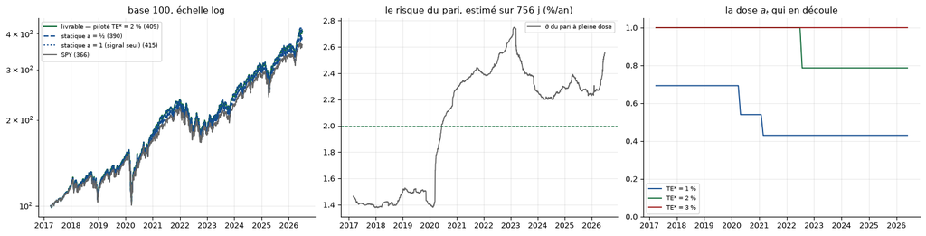

```
figure → /Users/lemairealice/Downloads/Jupiter/02_recherche_backtest/figs_nb16/deux_poches.png

runs distincts passés au bilan, §20 compris : 162
le pilotage ajoute des essais — ils comptent tous, et tous sont publiés.
```

```python
# ══ §20.9 — la figure du livrable, et le compteur d'essais ════════════════════════════════
fig, ax = plt.subplots(1, 3, figsize=(15.5, 4.0))

V_a1 = run_livre(livre_deux_poches(lambda i: 1.0, cuts=CUTS_P), np.inf, cuts=CUTS_P)[0]
V_a5 = run_livre(livre_deux_poches(lambda i: 0.5, cuts=CUTS_P), np.inf, cuts=CUTS_P)[0]
spf  = (1 + r_spy.reindex(V_FIN.index).fillna(0)).cumprod()
for V, c, ls, lab in [(V_FIN, VERT, "-", "livrable — piloté TE* = 2 %"),
                      (V_a5, BLEU, "--", "statique a = ½"), (V_a1, BLEU, ":", "statique a = 1 (signal seul)")]:
    s = V/V.iloc[0]*100
    ax[0].plot(s.index, s, color=c, ls=ls, lw=1.5, label=f"{lab} ({s.iloc[-1]:.0f})")
s = spf/spf.iloc[0]*100
ax[0].plot(s.index, s, color=GRIS, lw=1.3, label=f"SPY ({s.iloc[-1]:.0f})")
ax[0].set_yscale("log"); ax[0].legend(fontsize=7.5); ax[0].set_title("base 100, échelle log")

ax[1].plot(SIG_ROLL.dropna().index, SIG_ROLL.dropna(), color=GRIS, lw=1.2, label="σ̂ du pari à pleine dose")
for te, c in zip(TE_CIBLES, [BLEU, VERT, ROUGE]):
    A_ = doses(te, BANDE)
    s = pd.Series({cal[i]: v for i, v in A_.items()})
    ax[2].plot(s.index, s, color=c, lw=1.3, label=f"TE* = {te:g} %")
ax[1].axhline(2.0, color=VERT, lw=0.9, ls="--"); ax[1].legend(fontsize=7.5)
ax[1].set_title("le risque du pari, estimé sur 756 j (%/an)")
ax[2].set_ylim(0, 1.05); ax[2].legend(fontsize=7.5)
ax[2].set_title("la dose $a_t$ qui en découle")
plt.tight_layout(); plt.savefig(f"{FIGS15}/deux_poches.png", dpi=150, bbox_inches="tight"); plt.show()

print(f"figure → {FIGS15}/deux_poches.png")
print(f"\nruns distincts passés au bilan, §20 compris : {len(set(ESSAIS))}")
print("le pilotage ajoute des essais — ils comptent tous, et tous sont publiés.")
```